# What should FZS track every year? Five indicators for illegal gold mining

Data for Good · Group 5 (Giant River Turtle) · Question 5, Peru · Replication notebook

Likitha Yenuga, Laura Pérez, Pietro Maran, Erion Vathi, Santiago Sierra

16 October 2026

```r
rm(list = ls())

library(tidyverse)   # data handling and plots
library(readxl)      # MapBiomas and World Bank workbooks
library(jsonlite)    # BCRP and UN Comtrade files
library(sf)          # maps: points in polygons
library(terra)       # Amazon Mining Watch scar map (raster)
library(patchwork)   # figures with several panels
library(zoo)         # rolling means
sf_use_s2(FALSE)

RAW <- "data_raw"
OUT <- "output"
dir.create(OUT, showWarnings = FALSE)

# Every number that appears in the brief is written to output/numbers_in_brief.csv
numbers <- tibble(id = character(), description = character(), value = numeric(),
                  unit = character(), source = character())
log_number <- function(id, description, value, unit, source) {
  numbers <<- bind_rows(numbers, tibble(id = id, description = description,
                                        value = value, unit = unit, source = source))
  invisible(value)
}

# Check against the publisher: stop if a number does not match
check <- function(label, value, expected, tol = 1) {
  ok <- abs(value - expected) < tol
  cat(sprintf("%s %-72s %12s   (publisher: %s)\n", if (ok) "OK  " else "FAIL", label,
              format(round(value, 1), big.mark = ","), format(round(expected, 1), big.mark = ",")))
  if (!ok) stop(label, ": check failed")
}

fmt <- function(x, d = 0) format(round(x, d), big.mark = ",", nsmall = d)
pct <- function(x) sprintf("%+d%%", round(x))

theme_fzs <- theme_minimal(base_size = 11) +
  theme(panel.grid.minor = element_blank(), panel.grid.major.x = element_blank(),
        plot.title = element_text(face = "bold", size = 12),
        plot.caption = element_text(colour = "grey40", size = 8, hjust = 0),
        legend.position = "bottom")
theme_set(theme_fzs)
col_main <- "#234A76"; col_alert <- "#C0392B"; col_soft <- "#F28E2B"; col_grey <- "#9AA5B1"
```

# 1 Our answer

FZS (Frankfurt Zoological Society) reports to donors and governments on illegal gold mining around its protected areas in Peru. Today it learns about new mining mainly from yearly satellite maps, and these maps arrive more than a year late. Our question was: **which numbers should FZS check every year, so it can see trouble earlier and act?**

We recommend **five indicators**. They work at three speeds:

- **Early** numbers move before new mining shows up on the maps.
- **Now** numbers show where mining is happening this quarter.
- **Late** numbers confirm, once a year, how much forest was lost. They are slow but trusted, so FZS can use them in donor reports.

| # | Indicator | Speed | How often | Source |
| --- | --- | --- | --- | --- |
| 1 | Gold price in soles, after inflation, compared with its average of the last 3 years | Early | Monthly | World Bank, Central Bank of Peru (BCRP) |
| 2 | Peru’s gold gap: gold exported minus gold declared as produced | Early | Monthly | BCRP |
| 3 | New mining in FZS landscapes (hectares, by quarter) | Now | Quarterly | Amazon Mining Watch, SERNANP |
| 4 | Forest turned into mining: inside reserves and buffer zones, and in all of Madre de Dios | Late | Yearly | MapBiomas Peru |
| 5 | New mining outside Madre de Dios (is mining spreading?) | Now | Quarterly | Amazon Mining Watch |

Each indicator has **one red line** (a simple rule) and **one action** for FZS. Section 6 explains how we chose each red line and whether it would have warned FZS in time before the 2021 to 2023 mining surge.

We also checked many other signals: gold and mercury trade, coca, malaria in Brazil, aviation fuel, dredges in Colombia and Loreto, and traffic on the Interoceanic Highway. They are useful **context**, but each one has a problem that stops it from being a yearly indicator for FZS (Section 9).

**How to read the labels.** Every claim is marked **[Description]** (what the data show), **[Prediction]** (what may happen) or **[Causal]** (what causes what). We make no causal claims.

# 2 How we worked

1. **We started from FZS’s problem.** The yearly maps are good but late. So we looked for numbers that move earlier, and for numbers that say *where* the mining is.
2. **We described Madre de Dios first** (Section 4). The maps give a *stock* (all mining land in a year). The stock rarely goes down, so we used *flows*: land that became mining each year, and where it came from.
3. **We found a trap.** Much of the big 2023 jump was water (old flooded pits and rivers) relabelled as mining, not new forest loss. So our yearly indicator counts only **forest that became mining**.
4. **We looked for early signals.** Miners respond to the gold price. And gold that is exported but never declared as produced shows how much gold comes from outside the legal system.
5. **We used quarterly satellite data** to see where mining is happening now, and in hectares, so the numbers can be compared with other sources.
6. **We checked if mining is spreading** to new places outside Madre de Dios.
7. **We set one red line for each indicator and tested it on the past.** We chose the rules after we saw the data, so the test shows what *would* have happened. It is not proof. The fair test is the next two years.
8. **We kept the other signals as context.** We say why each one is not a main indicator.

# 3 Data and checks

All raw files are in `data_raw/` exactly as downloaded. Each file has one row in `DOWNLOAD_LOG.csv`. Two Amazon Mining Watch files are too big for the zip (113 MB and 62 MB). They are kept in `../data_large/`, next to the replication folder, and the code below downloads them if they are missing. Amazon Mining Watch replaces these files when its model changes, so the checks below stop the notebook if a new download does not match the version we used.

```r
large <- file.path("..", "data_large")
dir.create(large, showWarnings = FALSE)
amw_file  <- file.path(large, "amazon_basin_detections.geojson")
scar_file <- file.path(large, "amazon_basin_mining_scar_masks.tif")
options(timeout = 1200)
if (!file.exists(amw_file))  download.file("https://data.source.coop/earthgenome/amazon-mining-watch/amazon_basin_detections.geojson", amw_file, mode = "wb")
if (!file.exists(scar_file)) download.file("https://data.source.coop/earthgenome/amazon-mining-watch/amazon_basin_mining_scar_masks.tif", scar_file, mode = "wb")
cat("MD5 of the detections file:", unname(tools::md5sum(amw_file)), "\n")
```

```
## MD5 of the detections file: e55d422588158e0ef4772892d45b8137
```

```r
cat("MD5 of the scar map:       ", unname(tools::md5sum(scar_file)), "\n")
```

```
## MD5 of the scar map:        fe26c8ac69f642589fe6cd635bb744ce
```

```r
REG <- file.path(RAW, "regional")
dir.create(REG, showWarnings = FALSE)
# Download a file only if it is missing (all files used here are already in data_raw/regional/)
get_if_missing <- function(url, file, wait = 0) {
  dest <- file.path(REG, file)
  if (!file.exists(dest)) { Sys.sleep(wait); options(timeout = 600); download.file(url, dest, mode = "wb", quiet = TRUE) }
  invisible(dest)
}
ct <- "https://comtradeapi.un.org/public/v1/preview/C/A/HS?"   # UN Comtrade public preview: one year per call, no key
for (y in 2010:2025) {
  get_if_missing(paste0(ct, "reporterCode=604,170,76,68,218,862,328,740&cmdCode=7108&flowCode=X&period=", y, "&partnerCode=0"), sprintf("comtrade_gold_exports_%d.json", y), 5)
  get_if_missing(paste0(ct, "reporterCode=604,170,76,68,218,328,740,862,484&cmdCode=280540&flowCode=M,X&period=", y, "&partnerCode=0"), sprintf("comtrade_mercury_%d.json", y), 5)
  if (y >= 2015) get_if_missing(paste0(ct, "reporterCode=604,170,76&cmdCode=842952&flowCode=M&period=", y, "&partnerCode=0"), sprintf("comtrade_excavators_%d.json", y), 5)
}
get_if_missing("https://estadisticas.bcrp.gob.pe/estadisticas/series/api/PN38792BM-RD12978DM/json/2010-1/2026-12", "bcrp_gold_exports_production.json")
get_if_missing("https://ocean.bazg.admin.ch/open-data-reports/TN8_controlCode_Gold_IMP_en_v1/TN8_controlCode_Gold_IMP_en_v1.csv", "swiss_gold_imports_by_origin.csv")
get_if_missing("https://www.datos.gov.co/resource/r85m-vv6c.csv?$where=recurso_natural%3D%27ORO%27&$limit=500000", "colombia_anm_gold_production.csv")
get_if_missing("https://www.datos.gov.co/resource/dxs6-mdeg.csv?$limit=500000", "colombia_mindefensa_machinery_seized.csv")
get_if_missing("https://www.datos.gov.co/resource/acs4-3wgp.csv?$limit=5000", "colombia_coca_hectares_municipality.csv")
get_if_missing("https://www.gov.br/anp/pt-br/centrais-de-conteudo/dados-abertos/arquivos/vdpb/vaehdpm/gasolina-de-aviacao/vendas-anuais-de-gasolina-de-aviacao-por-municipio.csv", "brazil_anp_avgas_municipality.csv")
get_if_missing("https://www.gov.br/anp/pt-br/centrais-de-conteudo/dados-abertos/arquivos/vdpb/vaehdpm/oleo-diesel/vendas-anuais-de-oleo-diesel-por-municipio.csv", "brazil_anp_diesel_municipality.csv")
for (y in 2018:2026) get_if_missing(sprintf("https://public.tableau.com/views/Dadosparacidado_201925_03_2020/9-AutctonesreasEspeciais.csv?:showVizHome=no&YEAR(BR%%20Data%%20de%%20Notifica%%C3%%A7%%C3%%A3o)=%d", y),
                                    sprintf("brazil_malaria_special_areas_%d.csv", y), 2)
for (cc in c("COL", "BRA")) get_if_missing(sprintf("https://geodata.ucdavis.edu/gadm/gadm4.1/json/gadm41_%s_0.json.zip", cc), sprintf("gadm41_%s_0.json.zip", cc))
# The Peruvian coca price file blocks scripted downloads (HTTP 418); it was downloaded with a browser user agent (see DOWNLOAD_LOG.csv)
stopifnot(file.exists(file.path(REG, "peru_devida_coca_leaf_prices_2020_2023.xlsx")))
```

**Numbers typed by hand.** A few figures come from published reports, not from data files. We keep them in one table, so each has a source and appears in `output/numbers_in_brief.csv`. We only quote them. We never subtract them from our own numbers.

```r
published <- tribble(
  ~id, ~description, ~value, ~unit, ~source,
  "maap233_mdd", "Cumulative mining deforestation, Madre de Dios, to mid 2025", 135939, "ha", "MAAP #233 (29 Sep 2025)",
  "maap233_loreto", "Dredges recorded in Loreto, 2017 to 2025", 989, "records", "MAAP #233 (29 Sep 2025)",
  "maap233_nanay", "Dredges recorded on the Nanay river since 2017", 841, "records", "MAAP #233 (29 Sep 2025)",
  "maap233_nanay25", "Dredges recorded on the Nanay river in 2025", 275, "records", "MAAP #233 (29 Sep 2025)",
  "maap233_amazonas", "Dredges recorded in Amazonas region since 2017", 174, "records", "MAAP #233 (29 Sep 2025)",
  "maap233_water", "Water bodies with mining activity, Peruvian Amazon", 225, "rivers/streams", "MAAP #233 (29 Sep 2025)",
  "maap185_2122", "Mining deforestation, southern Peruvian Amazon, 2021 and 2022", 18421, "ha", "MAAP #185 (15 Jun 2023)",
  "maap195_2123", "Mining deforestation, southern Peruvian Amazon, 2021 to part of 2023", 23881, "ha", "MAAP #195 (19 Nov 2023)",
  "maap208_total", "Mining deforestation, southern Peruvian Amazon, Jan 2021 to Mar 2024", 30846, "ha", "MAAP #208 (8 May 2024)",
  "maap208_2123", "Mining deforestation, 2021 to 2023 (footnote 8)", 28292, "ha", "MAAP #208 (8 May 2024)",
  "maap208_outside", "Share outside the Mining Corridor, Jan 2021 to Mar 2024", 26.2, "%", "MAAP #208 (8 May 2024)",
  "maap208_cn", "Share in native communities", 14.6, "%", "MAAP #208 (8 May 2024)",
  "maap208_za", "Share in buffer zones of protected areas", 7.9, "%", "MAAP #208 (8 May 2024)",
  "maap241_2025", "Mining deforestation inside Tambopata National Reserve, 2025 (more than)", 400, "ha", "MAAP #241 via Amazon Conservation (12 May 2026)",
  "maap241_total", "Mining deforestation inside Tambopata National Reserve, 2025 to early 2026 (about)", 500, "ha", "MAAP #241 via Amazon Conservation (12 May 2026)",
  "maap241_struct", "Mining structures inside Tambopata National Reserve, Feb 2026", 183, "structures", "MAAP #241 via Amazon Conservation (12 May 2026)",
  "maap241_camps", "Mining camps inside Tambopata National Reserve, Feb 2026", 67, "camps", "MAAP #241 via Amazon Conservation (12 May 2026)",
  "amw_dash_peru", "AMW dashboard: total area affected by mining in Peru until 2026 Q2", 179900, "ha", "amazonminingwatch.org dashboard, read on 15 Oct 2026 (shown as 179.9k)",
  "amw_dash_tamb", "AMW dashboard: total area affected by mining in Tambopata National Reserve until 2026 Q2", 2412, "ha", "amazonminingwatch.org dashboard, read on 15 Oct 2026",
  "amw_panorama_h1", "AMW newsletter: new mining deforestation inside Tambopata National Reserve, first half of 2026", 786, "ha", "Amazon Mining Watch Panorama, issue 2 (Oct 2026)",
  "gc_tamb_area", "Area with illegal mining activity inside Tambopata National Reserve, Oct 2025 to Jun 2026 (about)", 1000, "ha", "Global Conservation (M. Quispe), quoted by Mongabay Latam (27 Sep 2026)",
  "rami_tamb_julaug", "Forest lost inside Tambopata National Reserve, Jul to Aug 2026", 1.68, "ha", "SERNANP RAMI radar monitoring, quoted by Mongabay Latam (27 Sep 2026)",
  "bcrp_fx_sep2026", "Exchange rate, soles per USD, September 2026 average", 3.3789, "S/ per USD", "BCRP series PN01234PM, read on the BCRP website on 15 Oct 2026",
  "aa_records", "Dredge records in Loreto, 2025 to Jun 2026 (more than)", 700, "records", "Actualidad Ambiental (17 Aug 2026), reporting a MAAP report (secondary)",
  "aa_rivers", "Rivers in Loreto with dredges, 2025 to Jun 2026", 13, "rivers", "Actualidad Ambiental (17 Aug 2026), reporting a MAAP report (secondary)",
  "aa_nanay", "Dredge detections on the Nanay, 2025 to Jun 2026", 421, "detections", "Actualidad Ambiental (17 Aug 2026), reporting a MAAP report (secondary)",
  "c2_peru_2022", "Mining area, Peru, 2022, as published in Collection 2", 169300, "ha", "MapBiomas Peru Collection 2 post (Feb 2024)",
  "c2_mdd_2022", "Mining area, Madre de Dios, 2022, as published in Collection 2 (about)", 82900, "ha", "MapBiomas Peru Collection 2 post (Feb 2024)",
  "evoa_2025", "Colombia: land with alluvial gold exploitation (EVOA), 2025", 118410, "ha", "MinEnergía/UNODC press release (2 Oct 2026)",
  "evoa_illicit", "Colombia: share of EVOA area that is illicit, 2025", 75, "%", "MinEnergía/UNODC press release (2 Oct 2026)",
  "evoa_river_sectors", "Colombia: sectors with river mining alerts on 11 Amazon rivers, 2025", 215, "sectors", "MinEnergía/UNODC press release (2 Oct 2026)",
  "evoa_coca_overlap", "Colombia: share of EVOA area overlapping coca, 2025", 48, "%", "MinEnergía/UNODC press release (2 Oct 2026)",
  "escolhas_garimpo_2022", "Brazil: gold production registered by garimpos, 2022", 30761, "kg", "Instituto Escolhas note (Feb 2026), from ANM CFEM data",
  "escolhas_garimpo_2025", "Brazil: gold production registered by garimpos, 2025", 5808, "kg", "Instituto Escolhas note (Feb 2026), from ANM CFEM data")
pub <- function(id) published$value[published$id == id]
knitr::kable(published %>% mutate(value = fmt(value, 1)), caption = "Published figures typed by hand (see DOWNLOAD_LOG.csv)")
```

Published figures typed by hand (see DOWNLOAD_LOG.csv)

| id | description | value | unit | source |
| --- | --- | --- | --- | --- |
| maap233_mdd | Cumulative mining deforestation, Madre de Dios, to mid 2025 | 135,939.0 | ha | MAAP #233 (29 Sep 2025) |
| maap233_loreto | Dredges recorded in Loreto, 2017 to 2025 | 989.0 | records | MAAP #233 (29 Sep 2025) |
| maap233_nanay | Dredges recorded on the Nanay river since 2017 | 841.0 | records | MAAP #233 (29 Sep 2025) |
| maap233_nanay25 | Dredges recorded on the Nanay river in 2025 | 275.0 | records | MAAP #233 (29 Sep 2025) |
| maap233_amazonas | Dredges recorded in Amazonas region since 2017 | 174.0 | records | MAAP #233 (29 Sep 2025) |
| maap233_water | Water bodies with mining activity, Peruvian Amazon | 225.0 | rivers/streams | MAAP #233 (29 Sep 2025) |
| maap185_2122 | Mining deforestation, southern Peruvian Amazon, 2021 and 2022 | 18,421.0 | ha | MAAP #185 (15 Jun 2023) |
| maap195_2123 | Mining deforestation, southern Peruvian Amazon, 2021 to part of 2023 | 23,881.0 | ha | MAAP #195 (19 Nov 2023) |
| maap208_total | Mining deforestation, southern Peruvian Amazon, Jan 2021 to Mar 2024 | 30,846.0 | ha | MAAP #208 (8 May 2024) |
| maap208_2123 | Mining deforestation, 2021 to 2023 (footnote 8) | 28,292.0 | ha | MAAP #208 (8 May 2024) |
| maap208_outside | Share outside the Mining Corridor, Jan 2021 to Mar 2024 | 26.2 | % | MAAP #208 (8 May 2024) |
| maap208_cn | Share in native communities | 14.6 | % | MAAP #208 (8 May 2024) |
| maap208_za | Share in buffer zones of protected areas | 7.9 | % | MAAP #208 (8 May 2024) |
| maap241_2025 | Mining deforestation inside Tambopata National Reserve, 2025 (more than) | 400.0 | ha | MAAP #241 via Amazon Conservation (12 May 2026) |
| maap241_total | Mining deforestation inside Tambopata National Reserve, 2025 to early 2026 (about) | 500.0 | ha | MAAP #241 via Amazon Conservation (12 May 2026) |
| maap241_struct | Mining structures inside Tambopata National Reserve, Feb 2026 | 183.0 | structures | MAAP #241 via Amazon Conservation (12 May 2026) |
| maap241_camps | Mining camps inside Tambopata National Reserve, Feb 2026 | 67.0 | camps | MAAP #241 via Amazon Conservation (12 May 2026) |
| amw_dash_peru | AMW dashboard: total area affected by mining in Peru until 2026 Q2 | 179,900.0 | ha | amazonminingwatch.org dashboard, read on 15 Oct 2026 (shown as 179.9k) |
| amw_dash_tamb | AMW dashboard: total area affected by mining in Tambopata National Reserve until 2026 Q2 | 2,412.0 | ha | amazonminingwatch.org dashboard, read on 15 Oct 2026 |
| amw_panorama_h1 | AMW newsletter: new mining deforestation inside Tambopata National Reserve, first half of 2026 | 786.0 | ha | Amazon Mining Watch Panorama, issue 2 (Oct 2026) |
| gc_tamb_area | Area with illegal mining activity inside Tambopata National Reserve, Oct 2025 to Jun 2026 (about) | 1,000.0 | ha | Global Conservation (M. Quispe), quoted by Mongabay Latam (27 Sep 2026) |
| rami_tamb_julaug | Forest lost inside Tambopata National Reserve, Jul to Aug 2026 | 1.7 | ha | SERNANP RAMI radar monitoring, quoted by Mongabay Latam (27 Sep 2026) |
| bcrp_fx_sep2026 | Exchange rate, soles per USD, September 2026 average | 3.4 | S/ per USD | BCRP series PN01234PM, read on the BCRP website on 15 Oct 2026 |
| aa_records | Dredge records in Loreto, 2025 to Jun 2026 (more than) | 700.0 | records | Actualidad Ambiental (17 Aug 2026), reporting a MAAP report (secondary) |
| aa_rivers | Rivers in Loreto with dredges, 2025 to Jun 2026 | 13.0 | rivers | Actualidad Ambiental (17 Aug 2026), reporting a MAAP report (secondary) |
| aa_nanay | Dredge detections on the Nanay, 2025 to Jun 2026 | 421.0 | detections | Actualidad Ambiental (17 Aug 2026), reporting a MAAP report (secondary) |
| c2_peru_2022 | Mining area, Peru, 2022, as published in Collection 2 | 169,300.0 | ha | MapBiomas Peru Collection 2 post (Feb 2024) |
| c2_mdd_2022 | Mining area, Madre de Dios, 2022, as published in Collection 2 (about) | 82,900.0 | ha | MapBiomas Peru Collection 2 post (Feb 2024) |
| evoa_2025 | Colombia: land with alluvial gold exploitation (EVOA), 2025 | 118,410.0 | ha | MinEnergía/UNODC press release (2 Oct 2026) |
| evoa_illicit | Colombia: share of EVOA area that is illicit, 2025 | 75.0 | % | MinEnergía/UNODC press release (2 Oct 2026) |
| evoa_river_sectors | Colombia: sectors with river mining alerts on 11 Amazon rivers, 2025 | 215.0 | sectors | MinEnergía/UNODC press release (2 Oct 2026) |
| evoa_coca_overlap | Colombia: share of EVOA area overlapping coca, 2025 | 48.0 | % | MinEnergía/UNODC press release (2 Oct 2026) |
| escolhas_garimpo_2022 | Brazil: gold production registered by garimpos, 2022 | 30,761.0 | kg | Instituto Escolhas note (Feb 2026), from ANM CFEM data |
| escolhas_garimpo_2025 | Brazil: gold production registered by garimpos, 2025 | 5,808.0 | kg | Instituto Escolhas note (Feb 2026), from ANM CFEM data |

## 3.1 MapBiomas Peru, Collection 4

```r
f_pol <- file.path(RAW, "MAPBIOMAS-PERU-LULC-COL4-LIMITES-POLITICOS.xlsx")
f_za  <- file.path(RAW, "MAPBIOMAS-PERU-LULC-COL4-ZONA-AMORTIGUAMIENTO.xlsx")
f_anp <- file.path(RAW, "MAPBIOMAS-PERU-LULC-COL4-AREAS-PROTEGIDAS.xlsx")

MINING <- 30                       # class 4.2 Minería
FOREST <- c(3, 4, 5, 6)            # 1.1 Bosque, 1.2 Bosque seco, 1.3 Manglar, 1.4 Bosque inundable
WATER  <- c(26, 31, 33)            # 5. Cuerpo de agua (river, lake, aquaculture)
BEACH  <- 23                       # 4.3 Playa (river beaches)

long_years <- function(d) d %>%
  pivot_longer(matches("^y\\d{4}$"), names_to = "year", values_to = "ha") %>%
  mutate(year = as.integer(sub("y", "", year)))

# Coverage (stocks): one row per territory x class, one column per year
cov_pol <- read_excel(f_pol, "COVERAGE_4") %>% long_years() %>%
  transmute(biome = territory_level_2_1, department = territory_level_2_2, class, year, ha)
cov_za  <- read_excel(f_za, "COVERAGE_4") %>% long_years() %>%
  transmute(unit = territory_level_2_1, category = territory_level_3_1,
            department = territory_level_2_2, class, year, ha)
cov_anp <- read_excel(f_anp, "COVERAGE_4") %>% long_years() %>%
  transmute(unit = territory_level_2_1, category = territory_level_3_1,
            department = territory_level_2_2, class, year, ha)

# Transitions (flows): area that moved from class_from to class_to between two consecutive years
read_transitions <- function(file) {
  read_excel(file, "TRANSITION_4") %>%
    pivot_longer(matches("^p\\d{4}_\\d{4}$"), names_to = "period", values_to = "ha") %>%
    mutate(y0 = as.integer(substr(period, 2, 5)), year = as.integer(substr(period, 7, 10))) %>%
    filter(year - y0 == 1) %>%                     # keep one year periods; drop 5 year and 1985 to 2025 totals
    mutate(ha = replace_na(ha, 0))
}
tr_pol <- read_transitions(f_pol) %>% rename(unit = territory_level_2)
tr_za  <- read_transitions(f_za)  %>% rename(unit = territory_level_2)
tr_anp <- read_transitions(f_anp) %>% rename(unit = territory_level_2)
```

```r
mdd_level <- cov_pol %>% filter(department == "Madre de Dios", class == MINING) %>%
  group_by(year) %>% summarise(mining_ha = sum(ha), .groups = "drop")
amazon_2025 <- cov_pol %>% filter(biome == "Amazonía", class == MINING, year == 2025) %>% pull(ha) %>% sum()
tamb_za_2025 <- cov_za %>% filter(unit == "Tambopata", class == MINING, year == 2025) %>% pull(ha) %>% sum()
mdd_za_2025  <- cov_za %>% filter(department == "Madre de Dios", class == MINING, year == 2025) %>% pull(ha) %>% sum()

check("MapBiomas C4: Madre de Dios, mining, 2025 (ha)", mdd_level$mining_ha[mdd_level$year == 2025], 112622)
```

```
## OK   MapBiomas C4: Madre de Dios, mining, 2025 (ha)                              112,621.7   (publisher: 112,622)
```

```r
check("MapBiomas C4: Peru, Amazon biome, mining, 2025 (ha)", amazon_2025, 118296)
```

```
## OK   MapBiomas C4: Peru, Amazon biome, mining, 2025 (ha)                         118,295.5   (publisher: 118,296)
```

```r
check("MapBiomas C4: Tambopata buffer zone, mining, 2025 (ha)", tamb_za_2025, 20730)
```

```
## OK   MapBiomas C4: Tambopata buffer zone, mining, 2025 (ha)                         20,730   (publisher: 20,730)
```

```r
check("MapBiomas C4: all buffer zones in Madre de Dios, mining, 2025 (ha)", mdd_za_2025, 34635)
```

```
## OK   MapBiomas C4: all buffer zones in Madre de Dios, mining, 2025 (ha)           34,634.6   (publisher: 34,635)
```

```r
# Transitions must add up to the stock: land that stayed mining + land that came in = stock this year
tr_mdd <- tr_pol %>% filter(unit == "Madre de Dios")
recon <- tr_mdd %>% group_by(year) %>%
  summarise(stock_from_transitions = sum(ha[class_to == MINING]), .groups = "drop") %>%
  left_join(mdd_level, by = "year")
check("Transitions reproduce the 2025 stock in Madre de Dios (ha)",
      recon$stock_from_transitions[recon$year == 2025], 112622)
```

```
## OK   Transitions reproduce the 2025 stock in Madre de Dios (ha)                  112,621.7   (publisher: 112,622)
```

```r
log_number("chk_mdd_2025", "Mining area, Madre de Dios, 2025", mdd_level$mining_ha[mdd_level$year == 2025], "ha", "MapBiomas Peru C4, Limites politicos, COVERAGE_4, class 30")
log_number("chk_amz_2025", "Mining area, Peru Amazon biome, 2025", amazon_2025, "ha", "MapBiomas Peru C4, Limites politicos")
log_number("chk_tamb_za_2025", "Mining area, Tambopata buffer zone, 2025", tamb_za_2025, "ha", "MapBiomas Peru C4, Zona de amortiguamiento")
```

## 3.2 Gold price (World Bank), exchange rate and prices in Peru (BCRP)

```r
pink <- read_excel(file.path(RAW, "CMO-Historical-Data-Monthly.xlsx"), sheet = "Monthly Prices", skip = 4) %>%
  rename(month = 1) %>% filter(grepl("^\\d{4}M\\d{2}$", month)) %>%
  transmute(date = as.Date(paste0(substr(month, 1, 4), "-", substr(month, 6, 7), "-01")),
            gold_usd = as.numeric(Gold))

es <- c(Ene = 1, Feb = 2, Mar = 3, Abr = 4, May = 5, Jun = 6, Jul = 7, Ago = 8, Sep = 9, Oct = 10, Nov = 11, Dic = 12)
read_bcrp <- function(code, name) {
  j <- fromJSON(file.path(RAW, paste0("bcrp_", code, ".json")))
  tibble(period = j$periods$name, value = suppressWarnings(as.numeric(unlist(j$periods$values)))) %>%
    transmute(date = as.Date(sprintf("%s-%02d-01", substr(period, 5, 8), es[substr(period, 1, 3)])),
              !!name := value)
}
fx  <- read_bcrp("PN01234PM", "pen_per_usd")   # soles per US dollar, monthly average
cpi <- read_bcrp("PN38705PM", "cpi_lima")      # Lima consumer price index, Dec 2021 = 100

check("World Bank Pink Sheet: gold, August 2026 (USD per oz)", pink$gold_usd[pink$date == as.Date("2026-08-01")], 4411)
```

```
## OK   World Bank Pink Sheet: gold, August 2026 (USD per oz)                           4,411   (publisher: 4,411)
```

```r
check("BCRP website: exchange rate, September 2026 (soles per USD)", fx$pen_per_usd[fx$date == as.Date("2026-09-01")], pub("bcrp_fx_sep2026"), tol = 0.0001)
```

```
## OK   BCRP website: exchange rate, September 2026 (soles per USD)                       3.4   (publisher: 3.4)
```

```r
log_number("gold_aug2026", "Gold price, August 2026", pink$gold_usd[pink$date == as.Date("2026-08-01")], "USD per oz", "World Bank Pink Sheet, Oct 2026 vintage")
```

## 3.3 Amazon Mining Watch and official boundaries

Amazon Mining Watch publishes two products. We use both.

- **Detections**: squares of about 480 m by 480 m (about 23 ha) where a computer model first sees mining. We count them as “patches”.
- **Scar map**: a map with 10 m pixels. Each mining pixel carries the period when it was first mapped as mining. We add up the pixels to get **hectares**. Amazon Mining Watch says this map is still “in development” and that areas “run large” compared with areas drawn by hand. So we trust **changes between periods** more than any single total.

Boundaries: GADM for departments; SERNANP for protected areas, buffer zones and titled native communities; INGEMMET (through SERNANP’s map service) for mining concessions that are titled or in process.

```r
amw <- st_read(amw_file, quiet = TRUE)
gadm_path <- paste0("/vsizip/", normalizePath(file.path(RAW, "gadm41_PER_1.json.zip")), "/gadm41_PER_1.json")
dep1 <- st_read(gadm_path, quiet = TRUE)
mdd_poly <- dep1 %>% filter(NAME_1 == "MadredeDios")
anp <- st_read(file.path(RAW, "sernanp_anp_nacional_peru.geojson"), quiet = TRUE)
za  <- st_read(file.path(RAW, "sernanp_zona_amortiguamiento_peru.geojson"), quiet = TRUE)
cn  <- st_read(file.path(RAW, "sernanp_comunidades_nativas.geojson"), quiet = TRUE)
conc <- bind_rows(st_read(file.path(RAW, "ingemmet_concessions_layer36.geojson"), quiet = TRUE),
                  st_read(file.path(RAW, "ingemmet_concessions_layer37.geojson"), quiet = TRUE))
anp_v <- st_make_valid(anp); za_v <- st_make_valid(za); cn_v <- st_make_valid(cn); conc_v <- st_make_valid(conc)

# Each detection is a ~480 m square. Reduce it to its centre point.
# "category" is exclusive, with a priority order: protected area > buffer zone > native community > rest.
pts <- suppressWarnings(st_centroid(amw))
pts <- pts[lengths(st_intersects(pts, mdd_poly)) > 0, ]
inside <- function(p, poly) lengths(st_intersects(p, poly)) > 0
pts <- pts %>% mutate(
  category = case_when(inside(., anp_v) ~ "Protected area",
                       inside(., za_v)  ~ "Buffer zone",
                       inside(., cn_v)  ~ "Native community",
                       TRUE ~ "Rest of Madre de Dios"),
  period = case_when(grepl("^Q", onset) ~ paste0("20", substr(onset, 3, 4), " Q", substr(onset, 2, 2)),
                     TRUE ~ onset))
cat("Detections in Madre de Dios:", nrow(pts), "of", nrow(amw), "in the Amazon basin\n")
```

```
## Detections in Madre de Dios: 27302 of 232030 in the Amazon basin
```

```r
log_number("amw_mdd_n", "Amazon Mining Watch detections in Madre de Dios (all periods)", nrow(pts), "patches", "Amazon Mining Watch, README dated 3 Oct 2026")
```

**Checks for the detections file.** These two checks stop the notebook if a new download differs from the version we used (the number of detections in the file, and the number in Peru first seen in 2024). The public dashboard shows hectares, not detections, so we check the dashboard against the scar map below.

```r
peru_poly <- st_union(dep1)
amw_pts_all <- suppressWarnings(st_centroid(amw))
peru_2024 <- sum(lengths(st_intersects(amw_pts_all[amw_pts_all$onset == "2024", ], peru_poly)) > 0)
check("Amazon Mining Watch: features in the basin file (version of 3 Oct 2026)", nrow(amw), 232030, tol = 0.5)
```

```
## OK   Amazon Mining Watch: features in the basin file (version of 3 Oct 2026)       232,030   (publisher: 232,030)
```

```r
check("Amazon Mining Watch: Peru, first detected in 2024 (patches)", peru_2024, 2072, tol = 0.5)
```

```
## OK   Amazon Mining Watch: Peru, first detected in 2024 (patches)                     2,072   (publisher: 2,072)
```

```r
log_number("amw_peru_2024", "AMW detections in Peru with onset 2024 (version check)", peru_2024, "patches", "Amazon Mining Watch GeoJSON")
```

**From the scar map to hectares.** The map covers the whole Amazon and is almost empty, so we read only the tiles (1,024 by 1,024 pixels) that contain a detection in Peru. Each mining pixel gets the zones that contain its centre: department, protected area, buffer zone, native community, mining concession. Then we add up the pixel areas. This takes about one minute.

```r
scar_r <- rast(scar_file)
amw_pe <- amw[lengths(st_intersects(amw, st_buffer(peru_poly, 0.01))) > 0, ]
px <- res(scar_r)[1]; x0 <- xmin(scar_r); y0 <- ymax(scar_r); B <- 1024 * px
bb <- t(sapply(st_geometry(amw_pe), function(g) as.numeric(st_bbox(g))))
m <- 0.01                                            # margin of about 1 km around each detection
tiles <- unique(bind_rows(
  tibble(c = floor((bb[, 1] - m - x0) / B), r = floor((y0 - bb[, 4] - m) / B)),
  tibble(c = floor((bb[, 3] + m - x0) / B), r = floor((y0 - bb[, 4] - m) / B)),
  tibble(c = floor((bb[, 1] - m - x0) / B), r = floor((y0 - bb[, 2] + m) / B)),
  tibble(c = floor((bb[, 3] + m - x0) / B), r = floor((y0 - bb[, 2] + m) / B))))

dep_names <- recode(dep1$NAME_1, MadredeDios = "Madre de Dios", SanMartín = "San Martín")
DEP <- vect(dep1); DEP$id <- seq_len(nrow(DEP))
zone_layers <- list(
  tamb_res = anp_v %>% filter(anp_nomb == "Tambopata"),
  anp_any  = anp_v,
  za_tb    = za_v %>% filter(grepl("Tambopata|Bahuaja-Sonene", anp_nomb)),   # shared buffer counted once, as Tambopata
  za_am    = za_v %>% filter(grepl("Amarakaeri", anp_nomb)),
  za_sira  = za_v %>% filter(grepl("Sira", anp_nomb)),
  za_any   = za_v,
  cn       = cn_v,
  conc     = conc_v) %>% map(vect)

scar_parts <- list()
for (k in seq_len(nrow(tiles))) {
  e <- ext(x0 + tiles$c[k] * B, x0 + (tiles$c[k] + 1) * B, y0 - (tiles$r[k] + 1) * B, y0 - tiles$r[k] * B)
  rb <- crop(scar_r, e); v <- values(rb, mat = FALSE); i <- which(!is.na(v) & v > 0)
  if (!length(i)) next
  d <- tibble(code = v[i], ha = values(cellSize(rb, unit = "ha"), mat = FALSE)[i])
  dv <- crop(DEP, e)
  d$dep <- if (nrow(dv)) values(rasterize(dv, rb, field = "id"), mat = FALSE)[i] else NA_integer_
  for (nm in names(zone_layers)) {
    lv <- crop(zone_layers[[nm]], e)
    d[[nm]] <- if (nrow(lv)) !is.na(values(rasterize(lv, rb, field = 1), mat = FALSE)[i]) else FALSE
  }
  scar_parts[[length(scar_parts) + 1]] <- d %>% group_by(across(-ha)) %>% summarise(ha = sum(ha), pixels = n(), .groups = "drop")
}
scar <- bind_rows(scar_parts) %>% group_by(across(-c(ha, pixels))) %>%
  summarise(ha = sum(ha), pixels = sum(pixels), .groups = "drop") %>%
  filter(!is.na(dep)) %>%                                                   # keep pixels inside Peru
  mutate(department = dep_names[dep],
         period = if_else(code < 3000, as.character(code), paste0(substr(code, 1, 4), " Q", substr(code, 5, 5))),
         mdd = department == "Madre de Dios",
         title = case_when(anp_any ~ "1 Protected area",
                           za_any & !conc ~ "2 Buffer zone, no mining title",
                           !conc ~ "3 Elsewhere, no mining title",
                           TRUE ~ "4 Inside a mining concession"))
write_csv(scar, file.path(OUT, "table_scar_hectares_by_zone.csv"))

# Check against Amazon Mining Watch's own table of hectares (same release, published 5 Oct 2026)
jur <- read_csv(file.path(RAW, "amw_mined_areas_by_jurisdiction.csv"), show_col_types = FALSE)
jur_pe   <- sum(jur$intersected_area_ha[jur$type == "national_admin" & jur$country_code %in% "PE"])
jur_tamb <- sum(jur$intersected_area_ha[jur$type == "protected_areas" & jur$name == "Tambopata"])
check("AMW scar map: Peru, all periods (ha; within 0.1%)", sum(scar$ha), jur_pe, tol = 0.001 * jur_pe)
```

```
## OK   AMW scar map: Peru, all periods (ha; within 0.1%)                           185,553.7   (publisher: 185,565.6)
```

```r
check("AMW scar map: Tambopata National Reserve, all periods (ha; within 1%)", sum(scar$ha[scar$tamb_res]), jur_tamb, tol = 0.01 * jur_tamb)
```

```
## OK   AMW scar map: Tambopata National Reserve, all periods (ha; within 1%)         2,599.7   (publisher: 2,590.5)
```

```r
# Check against the public dashboard (amazonminingwatch.org), which shows hectares up to 2026 Q2
upto_q2 <- scar$code != 20263
check("AMW dashboard: Peru, until 2026 Q2 (ha; dashboard rounds to 0.1k)", sum(scar$ha[upto_q2]), pub("amw_dash_peru"), tol = 100)
```

```
## OK   AMW dashboard: Peru, until 2026 Q2 (ha; dashboard rounds to 0.1k)             179,874   (publisher: 179,900)
```

```r
check("AMW dashboard: Tambopata National Reserve, until 2026 Q2 (ha; within 1%)", sum(scar$ha[upto_q2 & scar$tamb_res]), pub("amw_dash_tamb"), tol = 0.01 * pub("amw_dash_tamb"))
```

```
## OK   AMW dashboard: Tambopata National Reserve, until 2026 Q2 (ha; within 1%)      2,421.7   (publisher: 2,412)
```

```r
log_number("scar_peru_all", "AMW new scar, Peru, all periods 2018 to 2026 Q3", sum(scar$ha), "ha", "AMW scar map (our sum)")
log_number("scar_peru_all_amw", "AMW new scar, Peru, all periods, AMW's own table", jur_pe, "ha", "AMW mined_areas_by_jurisdiction.csv")
```

# 4 What happened in Madre de Dios

The MapBiomas tables give a **stock**: all land classified as mining in a year. The stock rarely goes down, so it rises over time almost whatever happens. We therefore use **flows**. The transition sheet tells us how much land **came into** mining each year, and from which class (forest, water, beach, other), and how much **left** mining.

```r
flows <- tr_mdd %>% filter(year >= 2001) %>%
  mutate(origin = case_when(class_from %in% FOREST ~ "from_forest",
                            class_from %in% WATER  ~ "from_water",
                            class_from == BEACH    ~ "from_beach",
                            TRUE                   ~ "from_other")) %>%
  group_by(year) %>%
  summarise(gross_in   = sum(ha[class_to == MINING & class_from != MINING]),
            from_forest = sum(ha[class_to == MINING & origin == "from_forest"]),
            from_water  = sum(ha[class_to == MINING & origin == "from_water"]),
            from_beach  = sum(ha[class_to == MINING & origin == "from_beach"]),
            from_other  = sum(ha[class_to == MINING & origin == "from_other" & class_from != MINING]),
            gross_out   = sum(ha[class_from == MINING & class_to != MINING]),
            .groups = "drop") %>%
  left_join(mdd_level, by = "year") %>%
  mutate(net_addition = mining_ha - lag(mining_ha))
flows$net_addition[flows$year == 2001] <- mdd_level$mining_ha[mdd_level$year == 2001] - mdd_level$mining_ha[mdd_level$year == 2000]

stopifnot(all(abs(flows$gross_in - flows$gross_out - flows$net_addition) < 1))   # flows add up

for (y in 2021:2023) check(paste("Net addition, Madre de Dios,", y, "(ha, Q5 card)"),
                           flows$net_addition[flows$year == y], c(`2021` = 4940, `2022` = 10540, `2023` = 19339)[as.character(y)])
```

```
## OK   Net addition, Madre de Dios, 2021 (ha, Q5 card)                               4,940.2   (publisher: 4,940)
## OK   Net addition, Madre de Dios, 2022 (ha, Q5 card)                              10,540.3   (publisher: 10,540)
## OK   Net addition, Madre de Dios, 2023 (ha, Q5 card)                              19,339.4   (publisher: 19,339)
```

```r
flows %>% filter(year >= 2014) %>%
  transmute(Year = year, `Stock (ha)` = fmt(mining_ha), `Net addition` = fmt(net_addition),
            `Came in` = fmt(gross_in), `from forest` = fmt(from_forest), `from water` = fmt(from_water),
            `from beaches` = fmt(from_beach), `from other land` = fmt(from_other), `Left mining` = fmt(gross_out)) %>%
  knitr::kable(caption = "Madre de Dios, MapBiomas Peru Collection 4: mining stock and flows (ha)", align = "r")
```

Madre de Dios, MapBiomas Peru Collection 4: mining stock and flows (ha)

| Year | Stock (ha) | Net addition | Came in | from forest | from water | from beaches | from other land | Left mining |
| --- | --- | --- | --- | --- | --- | --- | --- | --- |
| 2014 | 36,773 | 3,319 | 7,031 | 4,546 | 623 | 752 | 1,109 | 3,711 |
| 2015 | 39,677 | 2,904 | 5,772 | 3,016 | 550 | 1,144 | 1,061 | 2,868 |
| 2016 | 42,074 | 2,397 | 5,421 | 2,791 | 725 | 758 | 1,147 | 3,024 |
| 2017 | 47,108 | 5,033 | 8,454 | 4,517 | 951 | 1,213 | 1,773 | 3,420 |
| 2018 | 50,506 | 3,399 | 7,545 | 3,773 | 1,102 | 1,231 | 1,439 | 4,146 |
| 2019 | 54,312 | 3,805 | 8,742 | 4,529 | 1,068 | 1,177 | 1,967 | 4,937 |
| 2020 | 59,486 | 5,174 | 9,457 | 3,522 | 2,009 | 2,099 | 1,827 | 4,282 |
| 2021 | 64,426 | 4,940 | 10,996 | 6,152 | 1,963 | 1,367 | 1,514 | 6,056 |
| 2022 | 74,966 | 10,540 | 15,005 | 7,885 | 2,997 | 2,071 | 2,051 | 4,464 |
| 2023 | 94,306 | 19,339 | 24,604 | 9,982 | 9,616 | 1,984 | 3,022 | 5,264 |
| 2024 | 101,879 | 7,574 | 10,521 | 7,136 | 395 | 1,645 | 1,346 | 2,948 |
| 2025 | 112,622 | 10,742 | 16,475 | 10,308 | 973 | 2,658 | 2,536 | 5,733 |

```r
write_csv(flows, file.path(OUT, "table1_mdd_mining_flows.csv"))
```

We describe Madre de Dios because it holds 95% of the mining land in Peru’s Amazon (2025).

**[Description]** The net addition (stock this year minus stock last year) more than doubled in 2022 (10,540 ha, up from 4,940 ha) and almost doubled again in 2023 (19,339 ha). But the flows show that much of the 2023 jump was not new forest loss. In 2023, 9,616 ha that came into mining had been **water** the year before (39% of all land coming in). In 2022 it was 2,997 ha, and in 2024 395 ha. Forest that became mining grew more slowly: 6,152, 7,885 and 9,982 ha in 2021, 2022 and 2023.

**Why would water become mining?** Old mining pits fill with water and the map then calls them water. If miners come back, or if the map changes its mind, the same land is called mining again. Mining can also move into river channels. The map cannot tell these stories apart **[Interpretation, not tested]**. We think the way the map is made explains a large part of it, for two reasons. First, studies in Madre de Dios show that satellite methods find mining ponds hard to classify: the water in active ponds is muddy, and ponds change colour as they age (Caballero Espejo et al. 2018; Camalan et al. 2022). Second, water to mining also jumped in the rest of Peru in 2023 (Section 10), and miners going back to old pits in Madre de Dios cannot explain that. **So what did we decide?** Our yearly indicator (KPI 4) counts only **forest that became mining**, not the net addition. Trees turning into bare ground are much easier to see from space than a pond turning into mining.

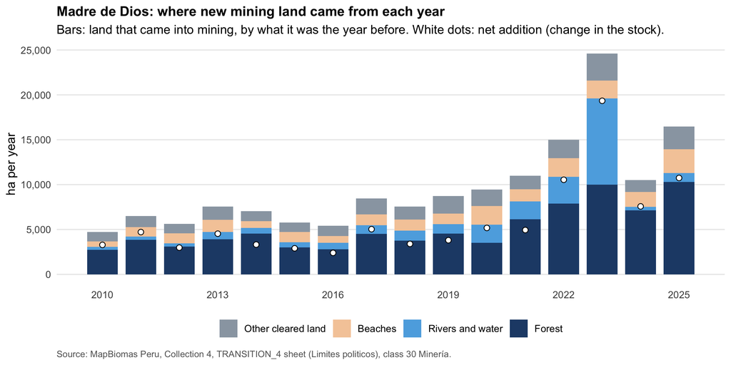

```r
flows %>% filter(year >= 2010) %>%
  select(year, `Forest` = from_forest, `Rivers and water` = from_water, `Beaches` = from_beach, `Other cleared land` = from_other) %>%
  pivot_longer(-year, names_to = "origin", values_to = "ha") %>%
  mutate(origin = factor(origin, levels = c("Other cleared land", "Beaches", "Rivers and water", "Forest"))) %>%
  ggplot(aes(year, ha, fill = origin)) + geom_col(width = 0.8) +
  geom_point(data = filter(flows, year >= 2010), aes(year, net_addition), inherit.aes = FALSE, shape = 21, fill = "white", size = 2) +
  scale_fill_manual(values = c("Forest" = col_main, "Rivers and water" = "#5DADE2", "Beaches" = "#F5CBA7", "Other cleared land" = col_grey)) +
  scale_y_continuous(labels = scales::comma) + scale_x_continuous(breaks = seq(2010, 2025, 3)) +
  labs(title = "Madre de Dios: where new mining land came from each year",
       subtitle = "Bars: land that came into mining, by what it was the year before. White dots: net addition (change in the stock).",
       x = NULL, y = "ha per year", fill = NULL,
       caption = "Source: MapBiomas Peru, Collection 4, TRANSITION_4 sheet (Limites politicos), class 30 Minería.")
```

```r
ggsave(file.path(OUT, "fig_flows_by_origin.png"), width = 9, height = 4.5, dpi = 200, bg = "white")
```

The next chart shows one year as steps: the 2024 stock, plus what came in, minus what left, gives the 2025 stock.

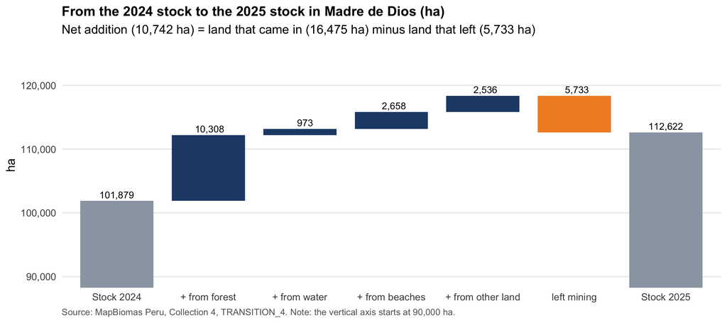

```r
w <- flows %>% filter(year == 2025)
wf <- tibble(step = c("Stock 2024", "+ from forest", "+ from water", "+ from beaches", "+ from other land", "left mining", "Stock 2025"),
             delta = c(mdd_level$mining_ha[mdd_level$year == 2024], w$from_forest, w$from_water, w$from_beach, w$from_other, -w$gross_out, NA)) %>%
  mutate(end = cumsum(replace_na(delta, 0)), start = lag(end, default = 0),
         start = if_else(step == "Stock 2025", 0, start), end = if_else(step == "Stock 2025", lag(end), end),
         type = case_when(step %in% c("Stock 2024", "Stock 2025") ~ "stock", delta < 0 ~ "out", TRUE ~ "in"),
         step = factor(step, step), label = fmt(abs(end - start)))
ggplot(wf, aes(x = step)) +
  geom_rect(aes(xmin = as.numeric(step) - 0.4, xmax = as.numeric(step) + 0.4, ymin = start, ymax = end, fill = type)) +
  geom_text(aes(y = pmax(start, end), label = label), vjust = -0.4, size = 3) +
  scale_fill_manual(values = c(stock = col_grey, `in` = col_main, out = col_soft), guide = "none") +
  scale_y_continuous(labels = scales::comma) + coord_cartesian(ylim = c(90000, 125000)) +
  labs(title = "From the 2024 stock to the 2025 stock in Madre de Dios (ha)",
       subtitle = paste0("Net addition (", fmt(w$net_addition), " ha) = land that came in (", fmt(w$gross_in),
                         " ha) minus land that left (", fmt(w$gross_out), " ha)"),
       x = NULL, y = "ha", caption = "Source: MapBiomas Peru, Collection 4, TRANSITION_4. Note: the vertical axis starts at 90,000 ha.")
```

```r
ggsave(file.path(OUT, "fig_waterfall_2025.png"), width = 9, height = 4, dpi = 200, bg = "white")
```

## 4.1 What old mining became

The same transition sheet tells us what land became when it **left** mining (rows with `class_from = 30`).

```r
left_to <- tr_mdd %>% filter(class_from == MINING, class_to != MINING, year >= 2016) %>%
  mutate(to = case_when(class_to %in% FOREST ~ "Forest (regrowth)",
                        class_to == 21       ~ "Farmland or pasture",
                        class_to == BEACH    ~ "River beach",
                        class_to %in% c(11, 51) ~ "Flooded grassland",
                        class_to %in% WATER  ~ "Water (flooded pits, rivers)",
                        TRUE                 ~ "Other (bare land, urban)")) %>%
  group_by(year, to) %>% summarise(ha = sum(ha), .groups = "drop")
lt25 <- left_to %>% filter(year == 2025) %>% mutate(share = 100 * ha / sum(ha)) %>% arrange(desc(ha))
knitr::kable(lt25 %>% transmute(`Mining land in 2024 that became...` = to, `ha in 2025` = fmt(ha), `Share (%)` = round(share)),
             caption = "Madre de Dios: what land that left mining in 2025 became (MapBiomas Peru C4, TRANSITION_4)")
```

Madre de Dios: what land that left mining in 2025 became (MapBiomas Peru C4, TRANSITION_4)

| Mining land in 2024 that became… | ha in 2025 | Share (%) |
| --- | --- | --- |
| Forest (regrowth) | 2,062 | 36 |
| Farmland or pasture | 1,380 | 24 |
| River beach | 868 | 15 |
| Flooded grassland | 618 | 11 |
| Water (flooded pits, rivers) | 411 | 7 |
| Other (bare land, urban) | 393 | 7 |

```r
write_csv(left_to, file.path(OUT, "table1b_mining_left_to.csv"))
lt <- function(x) lt25$share[lt25$to == x]
for (x in lt25$to) log_number(paste0("left_", gsub("[^a-z]", "", tolower(x))), paste("Share of land leaving mining in 2025 that became:", x), lt(x), "%", "MapBiomas C4 transitions")
m2w_2122 <- sum(left_to$ha[left_to$to == "Water (flooded pits, rivers)" & left_to$year %in% 2021:2022])
log_number("mining_to_water_2122", "Mining land relabelled as water, Madre de Dios, 2021 and 2022", m2w_2122, "ha", "MapBiomas C4 transitions")
```

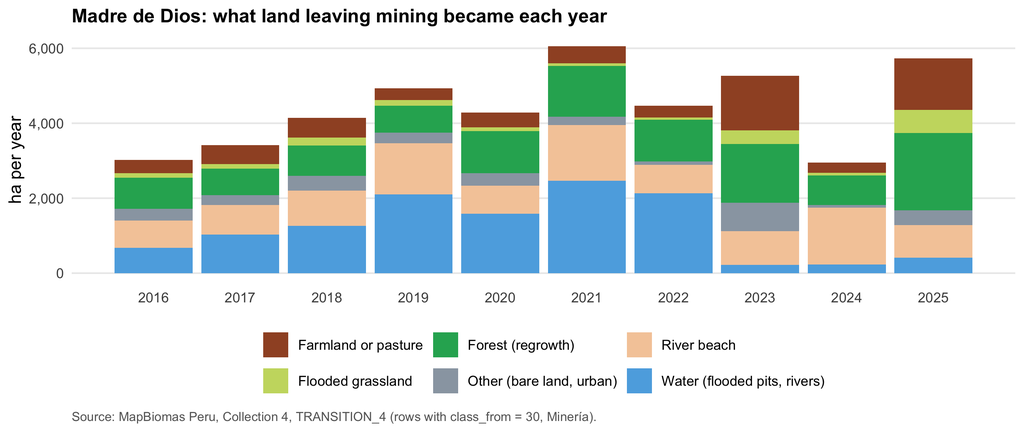

```r
ggplot(left_to, aes(year, ha, fill = to)) + geom_col() +
  scale_fill_manual(values = c("Forest (regrowth)" = "#27AE60", "Farmland or pasture" = "#A0522D", "River beach" = "#F5CBA7",
                               "Flooded grassland" = "#C8D96F", "Water (flooded pits, rivers)" = "#5DADE2", "Other (bare land, urban)" = col_grey), name = NULL) +
  scale_y_continuous(labels = scales::comma) + scale_x_continuous(breaks = 2016:2025) +
  labs(title = "Madre de Dios: what land leaving mining became each year",
       x = NULL, y = "ha per year", caption = "Source: MapBiomas Peru, Collection 4, TRANSITION_4 (rows with class_from = 30, Minería).")
```

```r
ggsave(file.path(OUT, "fig_left_mining.png"), width = 9, height = 3.8, dpi = 200, bg = "white")
```

**[Description]** In 2025, 5,733 ha left mining: 36% became forest again, 24% farmland or pasture, 15% river beach, 11% flooded grassland and 7% water. These are different stories on the ground: an old mine growing back as young, poor forest; people farming old mining land; a river covering a mined bank; a pit filling with water. Some changes are also the map changing its mind about pixels at the edges. So “left mining” does **not** mean the damage was repaired. The water line also shows the back and forth behind the 2023 jump: 4,595 ha of mining land was labelled water in 2021 and 2022, and 9,616 ha of water was labelled mining in 2023.

## 4.2 Three ways to count “new mining”

Different sources count different things. We put three yearly counts for Madre de Dios side by side. They answer different questions, so we never subtract one from another.

```r
scar_mdd_year <- scar %>% filter(mdd, code %in% 2019:2024) %>% group_by(year = code) %>% summarise(scar_ha = sum(ha))
three_counts <- flows %>% filter(year %in% 2019:2024) %>% select(year, from_forest, net_addition) %>%
  left_join(scar_mdd_year, "year")
knitr::kable(three_counts %>% transmute(Year = year, `Forest that became mining (MapBiomas)` = fmt(from_forest),
                                        `Net addition to the mining stock (MapBiomas)` = fmt(net_addition),
                                        `Land seen as mining for the first time since 2018 (AMW scar map)` = fmt(scar_ha)),
             caption = "Madre de Dios: three yearly counts of new mining (ha)")
```

Madre de Dios: three yearly counts of new mining (ha)

| Year | Forest that became mining (MapBiomas) | Net addition to the mining stock (MapBiomas) | Land seen as mining for the first time since 2018 (AMW scar map) |
| --- | --- | --- | --- |
| 2019 | 4,529 | 3,805 | 13,033 |
| 2020 | 3,522 | 5,174 | 12,749 |
| 2021 | 6,152 | 4,940 | 13,419 |
| 2022 | 7,885 | 10,540 | 10,404 |
| 2023 | 9,982 | 19,339 | 11,665 |
| 2024 | 7,136 | 7,574 | 13,018 |

```r
write_csv(three_counts, file.path(OUT, "table2b_three_counts.csv"))
cum_forest_to_mining <- sum(tr_mdd$ha[tr_mdd$class_to == MINING & tr_mdd$class_from %in% FOREST])
log_number("cum_ff", "Cumulative forest to mining, Madre de Dios, 1985 to 2025", cum_forest_to_mining, "ha", "MapBiomas C4 transitions")
for (y in 2021:2023) log_number(paste0("scar_mdd_", y), paste("AMW new scar, Madre de Dios,", y), three_counts$scar_ha[three_counts$year == y], "ha", "AMW scar map (our sum)")
```

**[Description]** The Amazon Mining Watch count stays almost flat: 10,404 to 13,419 ha a year in 2019 to 2024, and 2022 was its *lowest* year. In the same years the MapBiomas net addition jumped. The reason is what each one counts. Amazon Mining Watch counts a piece of land only **the first time** it is seen as mining. Mining again in an old pit, or a flooded pit that is mapped as mining again, is not new for Amazon Mining Watch, but it is new for the MapBiomas stock. **This supports our reading of 2023: much of the surge happened on land that was already mined before.** It also tells us how to use Amazon Mining Watch: it is good at showing mining that reaches **new places**, not at measuring the total amount of mining.

Two cumulative numbers are also often quoted. MapBiomas, summed over all years, gives 93,230 ha of forest turned into mining in Madre de Dios since 1985. MAAP reports 135,939 ha of mining deforestation up to mid 2025 (MAAP #233). MAAP joins several methods and image sources, so the two numbers differ for good reasons.

## 4.3 Buffer zones compared with the rest of Madre de Dios

Two groups and two periods: the buffer zones of protected areas in Madre de Dios, and the rest of the department; before the surge (2016 to 2020) and during and after it (2021 to 2025).

```r
za_mdd <- cov_za %>% filter(department == "Madre de Dios", class == MINING) %>%
  group_by(year) %>% summarise(za = sum(ha), .groups = "drop")
anp_mdd <- cov_anp %>% filter(department == "Madre de Dios", class == MINING) %>%
  group_by(year) %>% summarise(anp = sum(ha), .groups = "drop")
area_za  <- cov_za  %>% filter(department == "Madre de Dios", year == 2025) %>% pull(ha) %>% sum()
area_anp <- cov_anp %>% filter(department == "Madre de Dios", year == 2025) %>% pull(ha) %>% sum()
area_mdd <- cov_pol %>% filter(department == "Madre de Dios", year == 2025) %>% pull(ha) %>% sum()

zones <- mdd_level %>% left_join(za_mdd, "year") %>% left_join(anp_mdd, "year") %>%
  mutate(rest = mining_ha - za - anp) %>%
  pivot_longer(c(za, anp, rest), names_to = "zone", values_to = "stock") %>%
  group_by(zone) %>% arrange(year) %>% mutate(addition = stock - lag(stock)) %>% ungroup() %>%
  mutate(zone = recode(zone, za = "Buffer zones", anp = "Protected areas", rest = "Rest of Madre de Dios"),
         area = case_when(zone == "Buffer zones" ~ area_za, zone == "Protected areas" ~ area_anp,
                          TRUE ~ area_mdd - area_za - area_anp))

four <- zones %>% filter(zone != "Protected areas", year %in% 2016:2025) %>%
  mutate(period = if_else(year <= 2020, "2016 to 2020", "2021 to 2025")) %>%
  group_by(zone, period) %>%
  summarise(mean_addition = mean(addition), per_1000ha = 1000 * mean(addition) / first(area), .groups = "drop")
four %>% transmute(Group = zone, Period = period, `Mean yearly addition (ha)` = fmt(mean_addition),
                   `per 1,000 ha of the group` = fmt(per_1000ha, 2)) %>%
  knitr::kable(caption = "Four numbers: mean yearly net addition to mining land", align = "llrr")
```

Four numbers: mean yearly net addition to mining land

| Group | Period | Mean yearly addition (ha) | per 1,000 ha of the group |
| --- | --- | --- | --- |
| Buffer zones | 2016 to 2020 | 1,468 | 0.99 |
| Buffer zones | 2021 to 2025 | 2,529 | 1.71 |
| Rest of Madre de Dios | 2016 to 2020 | 2,405 | 0.76 |
| Rest of Madre de Dios | 2021 to 2025 | 8,044 | 2.53 |

```r
write_csv(four, file.path(OUT, "table2_compare_four_numbers.csv"))
for (i in seq_len(nrow(four))) log_number(paste0("cmp_", i), paste("Mean yearly addition,", four$zone[i], four$period[i]), four$mean_addition[i], "ha/yr", "MapBiomas C4 coverage")
dd <- four %>% select(zone, period, mean_addition) %>% pivot_wider(names_from = period, values_from = mean_addition)
```

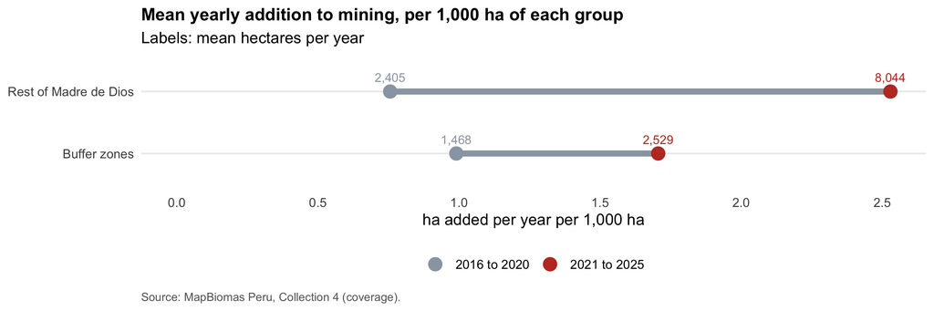

```r
ggplot(four, aes(x = per_1000ha, y = zone)) +
  geom_line(aes(group = zone), colour = col_grey, linewidth = 2) +
  geom_point(aes(colour = period), size = 4) +
  geom_text(aes(label = fmt(mean_addition), colour = period), vjust = -1.1, size = 3, show.legend = FALSE) +
  scale_colour_manual(values = c("2016 to 2020" = col_grey, "2021 to 2025" = col_alert), name = NULL) +
  scale_x_continuous(limits = c(0, NA)) +
  labs(title = "Mean yearly addition to mining, per 1,000 ha of each group", subtitle = "Labels: mean hectares per year",
       x = "ha added per year per 1,000 ha", y = NULL, caption = "Source: MapBiomas Peru, Collection 4 (coverage).")
```

**[Description]** Yearly additions in the buffer zones rose from 1,468 to 2,529 ha. In the rest of the department they rose from 2,405 to 8,044 ha. We start the second period in 2021 because our card defines the surge as 2021 to 2023, and because 2021 is the first year when forest turned into mining crossed its red line (KPI 4). The rest of the department faces the same gold price, roads and weather, so it is a fair comparison. It is **not** a control group: the buffer zones were drawn around areas already under pressure, and mining can move between the two groups.

# 5 The five indicators

## 5.1 KPI 1 (early, monthly): the gold price in soles

**Why.** A miner in Madre de Dios is paid in soles, and buys fuel, food and labour in soles. So we turn the dollar price into soles and remove inflation (Lima consumer prices). Then we compare it with its own average over the **previous 36 months**. When gold is worth much more than usual, mining pays better, and more people may start mining.

**Red line: the ratio reaches 1.20**, which means 20% above the 3 year average.

```r
gold <- pink %>% inner_join(fx, "date") %>% inner_join(cpi, "date") %>%
  filter(!is.na(pen_per_usd), !is.na(cpi_lima)) %>% arrange(date) %>%
  mutate(gold_pen = gold_usd * pen_per_usd,
         gold_real_pen = gold_pen / cpi_lima * 100,                         # soles of December 2021
         trailing36 = rollapplyr(lag(gold_real_pen), 36, mean, fill = NA),  # previous 36 months only
         ratio = gold_real_pen / trailing36,
         signal = ratio >= 1.20)
latest <- tail(filter(gold, !is.na(ratio)), 1)
first_signals <- gold %>% filter(signal, date >= as.Date("2016-01-01")) %>%
  mutate(run = cumsum(c(1, diff(as.numeric(date)) > 40))) %>% group_by(run) %>% slice(1) %>% ungroup()
knitr::kable(first_signals %>% transmute(`First month above the red line` = format(date, "%b %Y"),
                                         `Real price (soles of Dec 2021 per oz)` = fmt(gold_real_pen), Ratio = round(ratio, 2)),
             caption = "KPI 1: months when a new period above the red line started (since 2016)")
```

KPI 1: months when a new period above the red line started (since 2016)

| First month above the red line | Real price (soles of Dec 2021 per oz) | Ratio |
| --- | --- | --- |
| Feb 2020 | 5,865 | 1.22 |
| Apr 2021 | 6,837 | 1.21 |
| Sep 2024 | 8,495 | 1.24 |

```r
log_number("k1_latest_ratio", paste("Real gold price in soles / previous 36 month mean,", format(latest$date, "%b %Y")), latest$ratio, "ratio", "Pink Sheet + BCRP")
for (i in seq_len(nrow(first_signals))) log_number(paste0("k1_episode_", i), "KPI 1: first month of a period above the red line (yyyymm)", as.numeric(format(first_signals$date[i], "%Y%m")), "yyyymm", "Pink Sheet + BCRP")
log_number("k1_latest_real", paste("Real gold price, soles of Dec 2021,", format(latest$date, "%b %Y")), latest$gold_real_pen, "S/ per oz", "Pink Sheet + BCRP")
g21 <- gold %>% mutate(y = as.integer(format(date, "%Y"))) %>% group_by(y) %>%
  summarise(usd = mean(gold_usd), real_pen = mean(gold_real_pen), .groups = "drop") %>%
  mutate(chg_usd = 100 * (usd / lag(usd) - 1), chg_real_pen = 100 * (real_pen / lag(real_pen) - 1))
knitr::kable(g21 %>% filter(y %in% 2019:2026) %>% transmute(Year = y, `USD per oz` = fmt(usd), `Change in USD (%)` = round(chg_usd, 1),
                                                           `Real soles per oz` = fmt(real_pen), `Change in real soles (%)` = round(chg_real_pen, 1)),
             caption = "Yearly averages (2026: January to the latest month)")
```

Yearly averages (2026: January to the latest month)

| Year | USD per oz | Change in USD (%) | Real soles per oz | Change in real soles (%) |
| --- | --- | --- | --- | --- |
| 2019 | 1,393 | 9.7 | 5,080 | 9.1 |
| 2020 | 1,770 | 27.1 | 6,649 | 30.9 |
| 2021 | 1,800 | 1.7 | 7,205 | 8.4 |
| 2022 | 1,801 | 0.1 | 6,612 | -8.2 |
| 2023 | 1,943 | 7.9 | 6,549 | -0.9 |
| 2024 | 2,388 | 22.9 | 7,882 | 20.4 |
| 2025 | 3,442 | 44.1 | 10,591 | 34.4 |
| 2026 | 4,552 | 32.3 | 12,960 | 22.4 |

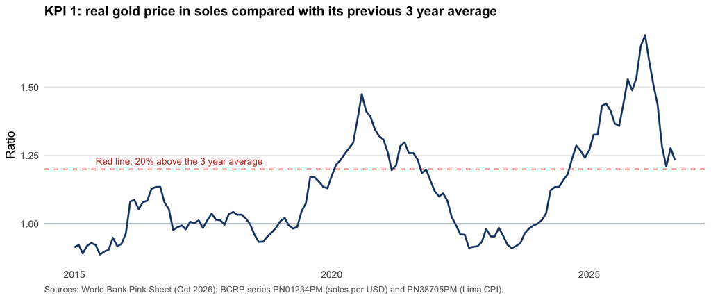

```r
ggplot(filter(gold, date >= as.Date("2015-01-01")), aes(date, ratio)) +
  geom_hline(yintercept = 1, colour = col_grey) +
  geom_hline(yintercept = 1.2, colour = col_alert, linetype = "dashed") +
  geom_line(colour = col_main, linewidth = 0.8) +
  annotate("text", x = as.Date("2015-06-01"), y = 1.23, label = "Red line: 20% above the 3 year average", hjust = 0, size = 3, colour = col_alert) +
  labs(title = "KPI 1: real gold price in soles compared with its previous 3 year average",
       x = NULL, y = "Ratio", caption = "Sources: World Bank Pink Sheet (Oct 2026); BCRP series PN01234PM (soles per USD) and PN38705PM (Lima CPI).")
```

```r
ggsave(file.path(OUT, "fig_kpi1_gold.png"), width = 9, height = 3.8, dpi = 200, bg = "white")
```

**[Description]** In September 2026 the real gold price in soles was 23% above its average of the previous three years, so **KPI 1 is red today**. It first crossed the red line in February 2020, before the 2021 to 2023 surge. New periods above the line started in Feb 2020, Apr 2021, Sep 2024.

**What it does not show.** Where mining will happen, or how much. It is a signal of pressure, not a forecast of hectares.

### 5.1.1 Why did mining keep growing when the real price fell in 2022 and 2023?

```r
price_y <- gold %>% mutate(year = as.integer(format(date, "%Y"))) %>% filter(year <= 2025) %>%
  group_by(year) %>% summarise(real_pen = mean(gold_real_pen), .groups = "drop")
pz <- flows %>% select(year, from_forest) %>% inner_join(price_y, "year") %>% arrange(year) %>%
  mutate(d_ff = from_forest - lag(from_forest), d_lp = log(real_pen) - log(lag(real_pen)))
lag_cor <- map_dfr(0:3, function(k) {
  d <- pz %>% filter(year >= 2003) %>% mutate(x = lag(d_lp, k)) %>% filter(!is.na(x), !is.na(d_ff))
  ct <- cor.test(d$d_ff, d$x)
  tibble(`Price change measured...` = c("in the same year", "1 year earlier", "2 years earlier", "3 years earlier")[k + 1],
         Correlation = round(unname(ct$estimate), 2), `p value` = round(ct$p.value, 2), Years = nrow(d))
})
knitr::kable(pz %>% filter(year >= 2017) %>% transmute(Year = year, `Real gold price (soles of Dec 2021 per oz)` = fmt(real_pen), `Forest that became mining (ha)` = fmt(from_forest)),
             caption = "Real gold price in soles and forest that became mining, Madre de Dios")
```

Real gold price in soles and forest that became mining, Madre de Dios

| Year | Real gold price (soles of Dec 2021 per oz) | Forest that became mining (ha) |
| --- | --- | --- |
| 2017 | 4,636 | 4,517 |
| 2018 | 4,656 | 3,773 |
| 2019 | 5,080 | 4,529 |
| 2020 | 6,649 | 3,522 |
| 2021 | 7,205 | 6,152 |
| 2022 | 6,612 | 7,885 |
| 2023 | 6,549 | 9,982 |
| 2024 | 7,882 | 7,136 |
| 2025 | 10,591 | 10,308 |

```r
knitr::kable(lag_cor, caption = "Correlation between the yearly change in forest that became mining and the change in the real gold price, 2003 to 2025")
```

Correlation between the yearly change in forest that became mining and the change in the real gold price, 2003 to 2025

| Price change measured… | Correlation | p value | Years |
| --- | --- | --- | --- |
| in the same year | -0.07 | 0.75 | 23 |
| 1 year earlier | 0.35 | 0.11 | 22 |
| 2 years earlier | 0.30 | 0.19 | 21 |
| 3 years earlier | 0.06 | 0.80 | 20 |

```r
pre <- mean(pz$real_pen[pz$year %in% 2017:2019])
above_pre <- 100 * (mean(pz$real_pen[pz$year %in% 2022:2023]) / pre - 1)
log_number("price_2223_vs_1719", "Real gold price in soles, 2022 and 2023 average vs 2017 to 2019 average", above_pre, "%", "Pink Sheet + BCRP")
log_number("lagcor_1", "Correlation: change in forest to mining vs change in real price one year earlier", lag_cor$Correlation[2], "r", "MapBiomas C4 + Pink Sheet + BCRP")
```

**[Description]** In real soles the gold price fell 8% in 2022 and another 1% in 2023. But it was still 37% above its 2017 to 2019 average. Profit depends on the **level** of the price, so mining still paid very well. The yearly change in forest turned into mining does not move with the price change of the same year (r = -0.07). It moves a little with the price change one and two years earlier (r = 0.35 and 0.3). This fits a **delayed response**: opening a new site needs machines, workers and access. But with about 20 years of data these correlations could be chance (p = 0.11 and 0.19). Other things also changed in those years: COVID 19, weaker enforcement after Operation Mercurio, and (for the net addition only) the 2023 water relabelling **[Interpretation, not tested]**. We cannot separate these causes. This is why KPI 1 is a pressure signal, not a forecast.

## 5.2 KPI 2 (early, monthly): Peru’s gold gap

**Why.** Peru’s Central Bank publishes every month how much gold Peru **exported** and how much gold mines **declared as produced**. If Peru exports much more gold than it declares, the difference has no declared origin. Part of it is likely illegal gold that entered the legal chain. Both numbers come from the same publisher, so the subtraction is fair.

**How we measure it.** We use 12 months at a time (to remove the seasons): the gap = (exports minus declared production) as a share of exports.

**Red line: the gap jumps.** The gap has been high since 2017, so a fixed level would be red every year and tell FZS nothing new. Instead, the red line is a **jump**: the 12 month gap is more than *X* points higher than one year earlier. We set *X* the same way as our other statistical red lines: the average yearly change in calm years (2014 to 2016) plus two standard deviations.

```r
b <- fromJSON(file.path(REG, "bcrp_gold_exports_production.json"))
bm <- tibble(p = b$periods$name, v = b$periods$values) %>%
  mutate(year = as.integer(substr(p, 5, 8)), month = es[substr(p, 1, 3)],
         export_t = map_dbl(v, ~ suppressWarnings(as.numeric(.x[1]))) * 31.1035 / 1000,   # thousand troy oz -> tonnes (fine gold)
         prod_t   = map_dbl(v, ~ suppressWarnings(as.numeric(.x[2]))) / 1e6) %>%          # fine grams -> tonnes
  select(-v, -p) %>% filter(!is.na(export_t), !is.na(prod_t))
gap_y <- bm %>% group_by(year) %>% filter(n() == 12) %>%
  summarise(export_t = sum(export_t), prod_t = sum(prod_t), .groups = "drop") %>%
  mutate(gap_t = export_t - prod_t, gap_pct = 100 * gap_t / export_t, change = gap_pct - lag(gap_pct))
h1_26 <- bm %>% filter(year == 2026, month <= 6) %>% summarise(e = sum(export_t), p = sum(prod_t)) %>% mutate(pct = 100 * (e - p) / e)

# Monthly: 12 month gap, and its change against the same month one year earlier
bm_roll <- bm %>% arrange(year, month) %>%
  mutate(date = as.Date(sprintf("%d-%02d-01", year, month)),
         gap12 = 100 * (1 - rollapplyr(prod_t, 12, sum, fill = NA) / rollapplyr(export_t, 12, sum, fill = NA)),
         jump = gap12 - lag(gap12, 12))
calm <- bm_roll %>% filter(year %in% 2014:2016, !is.na(jump))
X <- mean(calm$jump) + 2 * sd(calm$jump)
bm_roll <- bm_roll %>% mutate(signal = jump > X)
episodes <- bm_roll %>% filter(signal %in% TRUE) %>% mutate(run = cumsum(c(1, diff(as.numeric(date)) > 100))) %>%   # one quiet month does not end a period
  group_by(run) %>% summarise(from = min(date), to = max(date), peak = max(jump), .groups = "drop")
gap_latest <- tail(filter(bm_roll, !is.na(jump)), 1)

knitr::kable(gap_y %>% filter(year >= 2012) %>% transmute(Year = year, `Exports (t of fine gold)` = fmt(export_t, 1),
             `Declared production (t)` = fmt(prod_t, 1), `Gap (t)` = fmt(gap_t, 1), `Gap (% of exports)` = fmt(gap_pct, 1),
             `Change on the year before (points)` = fmt(change, 1)),
             caption = "Peru: gold exported minus gold declared as produced, by year (BCRP)")
```

Peru: gold exported minus gold declared as produced, by year (BCRP)

| Year | Exports (t of fine gold) | Declared production (t) | Gap (t) | Gap (% of exports) | Change on the year before (points) |
| --- | --- | --- | --- | --- | --- |
| 2012 | 199.9 | 161.5 | 38.4 | 19.2 | NA |
| 2013 | 188.1 | 151.5 | 36.6 | 19.5 | 0.3 |
| 2014 | 165.6 | 140.1 | 25.5 | 15.4 | -4.1 |
| 2015 | 178.7 | 142.3 | 36.4 | 20.4 | 5.0 |
| 2016 | 184.6 | 150.9 | 33.7 | 18.3 | -2.1 |
| 2017 | 204.2 | 152.0 | 52.2 | 25.6 | 7.3 |
| 2018 | 202.6 | 142.6 | 59.9 | 29.6 | 4.0 |
| 2019 | 191.0 | 128.3 | 62.6 | 32.8 | 3.2 |
| 2020 | 137.7 | 85.9 | 51.7 | 37.6 | 4.8 |
| 2021 | 176.1 | 96.4 | 79.8 | 45.3 | 7.7 |
| 2022 | 176.2 | 95.6 | 80.6 | 45.7 | 0.5 |
| 2023 | 176.9 | 99.2 | 77.7 | 43.9 | -1.8 |
| 2024 | 202.6 | 105.4 | 97.2 | 48.0 | 4.0 |
| 2025 | 209.6 | 106.6 | 103.0 | 49.1 | 1.2 |

```r
knitr::kable(episodes %>% transmute(`Red from` = format(from, "%b %Y"), `Red until` = format(to, "%b %Y"), `Largest jump (points)` = round(peak, 1)),
             caption = paste0("KPI 2: periods when the 12 month gap was more than ", round(X, 1), " points above one year earlier"))
```

KPI 2: periods when the 12 month gap was more than 6 points above one year earlier

| Red from | Red until | Largest jump (points) |
| --- | --- | --- |
| Oct 2017 | Jul 2018 | 8.9 |
| Apr 2021 | Jun 2022 | 8.6 |

```r
write_csv(gap_y, file.path(OUT, "tableR2_peru_gold_gap.csv"))
write_csv(bm_roll, file.path(OUT, "table_kpi2_gold_gap_monthly.csv"))
check("BCRP: Peru gold export minus production gap 2025 (t)", gap_y$gap_t[gap_y$year == 2025], 103.0, tol = 0.1)
```

```
## OK   BCRP: Peru gold export minus production gap 2025 (t)                              103   (publisher: 103)
```

```r
log_number("pe_gap_2025_t", "Peru gold exports minus declared production, 2025", gap_y$gap_t[gap_y$year == 2025], "t", "BCRP PN38792BM, RD12978DM")
log_number("pe_gap_2025_pct", "Peru gold gap as share of exports, 2025", gap_y$gap_pct[gap_y$year == 2025], "%", "BCRP")
log_number("pe_gap_2017_pct", "Peru gold gap as share of exports, 2017", gap_y$gap_pct[gap_y$year == 2017], "%", "BCRP")
log_number("pe_gap_h1_2026_pct", "Peru gold gap as share of exports, Jan to Jun 2026", h1_26$pct, "%", "BCRP")
log_number("pe_gap_12m_latest", paste("Peru 12 month gold gap,", format(gap_latest$date, "%b %Y")), gap_latest$gap12, "%", "BCRP")
log_number("pe_gap_jump_latest", paste("Peru 12 month gold gap, change on one year earlier,", format(gap_latest$date, "%b %Y")), gap_latest$jump, "points", "BCRP")
log_number("pe_gap_X", "KPI 2 red line: jump in the 12 month gap (2014 to 2016 mean + 2 SD)", X, "points", "BCRP")
for (i in seq_len(nrow(episodes))) log_number(paste0("pe_gap_episode_", i), "KPI 2: first month of a red period (yyyymm)", as.numeric(format(episodes$from[i], "%Y%m")), "yyyymm", "BCRP")
```

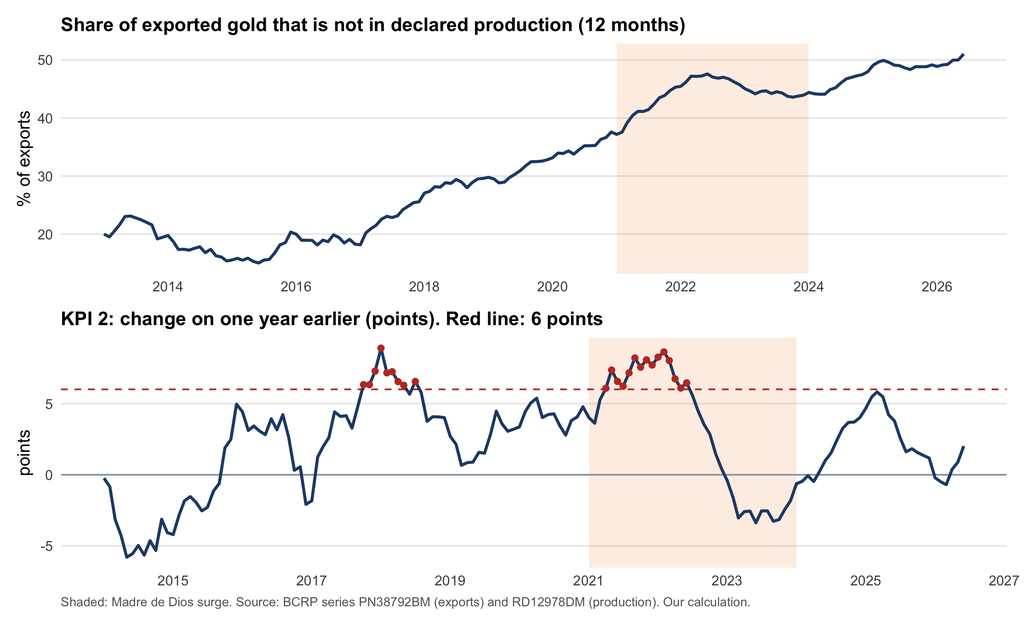

```r
k2a <- ggplot(filter(bm_roll, date >= as.Date("2013-01-01")), aes(date, gap12)) +
  annotate("rect", xmin = as.Date("2021-01-01"), xmax = as.Date("2023-12-31"), ymin = -Inf, ymax = Inf, fill = col_soft, alpha = 0.15) +
  geom_line(colour = col_main, linewidth = 0.9) +
  labs(title = "Share of exported gold that is not in declared production (12 months)", x = NULL, y = "% of exports")
k2b <- ggplot(filter(bm_roll, date >= as.Date("2014-01-01")), aes(date, jump)) +
  annotate("rect", xmin = as.Date("2021-01-01"), xmax = as.Date("2023-12-31"), ymin = -Inf, ymax = Inf, fill = col_soft, alpha = 0.15) +
  geom_hline(yintercept = 0, colour = col_grey) +
  geom_hline(yintercept = X, colour = col_alert, linetype = "dashed") +
  geom_line(colour = col_main, linewidth = 0.9) +
  geom_point(data = filter(bm_roll, signal %in% TRUE), colour = col_alert, size = 1.5) +
  labs(title = paste0("KPI 2: change on one year earlier (points). Red line: ", round(X, 1), " points"),
       x = NULL, y = "points", caption = "Shaded: Madre de Dios surge. Source: BCRP series PN38792BM (exports) and RD12978DM (production). Our calculation.")
(k2a / k2b) & scale_x_date(date_breaks = "2 years", date_labels = "%Y")
```

```r
ggsave(file.path(OUT, "figR_peru_gold_gap.png"), width = 9, height = 5.5, dpi = 200, bg = "white")
```

**[Description]** Peru exported 103.0 t more gold in 2025 than it declared as produced: 49% of all exported gold. In 2017 it was 26%. In January to June 2026 it was 53%. (The Instituto Peruano de Economía publishes a similar estimate: 54% in the first half of 2026, from press reports.)

The red line is a jump of more than 6 points. The gap jumped above it in 2 periods: Oct 2017 to Jul 2018 and Apr 2021 to Jun 2022. The second period started in **April 2021**, in the first year of the Madre de Dios surge. BCRP publishes each month about two months later, so FZS could have seen it in mid 2021. The yearly maps showed the surge only in March 2023. The first period (2017 and 2018) came without a surge in forest loss, so the rule can also give a warning that is not followed by more mining. **Today the gap is high (51% over the 12 months to June 2026) but it is not jumping** (+2.0 points on a year earlier), so KPI 2 is not red.

**What it does not show.** Where the gold was mined. The gap is national: it includes Madre de Dios, but also Puno, La Libertad and other regions, and gold smuggled into Peru from neighbouring countries. The 2014 to 2016 calm period is our choice, and it has only 36 months (which overlap, because each one covers 12 months). With another choice, the red line would move.

## 5.3 KPI 3 (now, quarterly): new mining in FZS landscapes

**Why.** FZS needs to know **where** mining is happening, and fast. Amazon Mining Watch updates its data within days after each quarter ends. We count new mining in hectares (from the scar map) and in patches (from the detections), in four FZS landscapes in Madre de Dios:

- inside the **Tambopata National Reserve**, where mining is always illegal;
- the **Tambopata buffer zone** (it overlaps the Bahuaja-Sonene buffer zone; we count the shared land once, as Tambopata);
- the **Amarakaeri buffer zone**;
- **native communities** (all titled communities outside reserves; they can overlap buffer zones).

**Red lines.**

- **Inside the reserve:** a quarter with more new mining than the largest *whole year* of 2019 to 2024. Some mining appears inside the reserve every year, so “any mining” would always be red. We compare with the worst year instead.
- **Buffer zones and native communities:** the quarters of this year so far have more than **25% more** new mining than the same quarters last year. We compare the same quarters because mining is seen mostly in the dry season (Q2 and Q3), and Q1 is very cloudy.

```r
# Which protected area, buffer zone and native community each detection falls in.
# We keep ALL names a point falls in (polygons overlap).
names_in <- function(p, poly) sapply(st_intersects(p, poly), function(i) paste(sort(unique(poly$anp_nomb[i])), collapse = "|"))
pts$anp_names <- names_in(pts, anp_v)
pts$za_names  <- names_in(pts, za_v)
pts$in_cn     <- lengths(st_intersects(pts, cn_v)) > 0
pts <- pts %>% mutate(
  tamb_reserve = grepl("Tambopata", anp_names),
  tamb_buffer  = anp_names == "" & grepl("Tambopata|Bahuaja-Sonene", za_names),
  amar_buffer  = anp_names == "" & !tamb_buffer & grepl("Amarakaeri", za_names),
  native_any   = anp_names == "" & in_cn)

amw_tab <- pts %>% st_drop_geometry() %>% filter(period != "2018") %>%   # 2018 = everything already there in the first year
  count(period, category) %>% pivot_wider(names_from = category, values_from = n, values_fill = 0) %>%
  mutate(Total = rowSums(across(where(is.numeric)))) %>% arrange(period) %>%
  select(period, any_of(c("Protected area", "Buffer zone", "Native community", "Rest of Madre de Dios")), Total)
write_csv(amw_tab, file.path(OUT, "table3_amw_by_category.csv"))

watch <- c("Tambopata (inside reserve)", "Tambopata buffer zone", "Amarakaeri buffer zone",
           "Native communities (all)", "All Madre de Dios")
flag_long <- pts %>% st_drop_geometry() %>%
  transmute(period, `Tambopata (inside reserve)` = tamb_reserve, `Tambopata buffer zone` = tamb_buffer,
            `Amarakaeri buffer zone` = amar_buffer, `Native communities (all)` = native_any, `All Madre de Dios` = TRUE) %>%
  pivot_longer(-period, names_to = "landscape", values_to = "flag") %>% filter(flag)
patches_q <- flag_long %>% filter(period != "2018") %>% count(landscape, period) %>%
  complete(landscape = watch, period = unique(pts$period[pts$period != "2018"]), fill = list(n = 0))
```

```r
ha_long <- scar %>% filter(mdd, period != "2018") %>%
  transmute(period, ha, `Tambopata (inside reserve)` = tamb_res, `Tambopata buffer zone` = !anp_any & za_tb,
            `Amarakaeri buffer zone` = !anp_any & !za_tb & za_am, `Native communities (all)` = !anp_any & cn,
            `All Madre de Dios` = TRUE) %>%
  pivot_longer(-c(period, ha), names_to = "landscape", values_to = "flag") %>% filter(flag) %>%
  group_by(landscape, period) %>% summarise(ha = sum(ha), .groups = "drop") %>%
  complete(landscape = watch, period = unique(scar$period[scar$period != "2018"]), fill = list(ha = 0))

# One table: hectares and patches by landscape and period; "Rest of Madre de Dios" = all minus the three landscapes
k3 <- ha_long %>% left_join(patches_q, c("landscape", "period")) %>% mutate(n = replace_na(n, 0))
rest <- k3 %>% group_by(period) %>%
  summarise(ha = ha[landscape == "All Madre de Dios"] - sum(ha[landscape %in% watch[1:3]]),
            n  = n[landscape == "All Madre de Dios"]  - sum(n[landscape %in% watch[1:3]]), .groups = "drop") %>%
  mutate(landscape = "Rest of Madre de Dios")
watch6 <- c(watch, "Rest of Madre de Dios")
k3 <- bind_rows(k3, rest) %>% mutate(landscape = factor(landscape, watch6), quarterly = grepl("Q", period))
write_csv(k3, file.path(OUT, "table3b_kpi3_hectares_patches.csv"))

knitr::kable(k3 %>% filter(quarterly) %>% transmute(landscape, period, ha = fmt(ha)) %>%
               pivot_wider(names_from = period, values_from = ha) %>% arrange(landscape) %>% rename(Landscape = landscape),
             caption = "New mining per quarter, hectares (provisional). Rows overlap: native communities also lie in buffer zones.")
```

New mining per quarter, hectares (provisional). Rows overlap: native communities also lie in buffer zones.

| Landscape | 2025 Q1 | 2025 Q2 | 2025 Q3 | 2025 Q4 | 2026 Q1 | 2026 Q2 | 2026 Q3 |
| --- | --- | --- | --- | --- | --- | --- | --- |
| Tambopata (inside reserve) | 2 | 85 | 107 | 184 | 93 | 695 | 178 |
| Tambopata buffer zone | 27 | 882 | 456 | 438 | 109 | 1,752 | 723 |
| Amarakaeri buffer zone | 73 | 143 | 122 | 48 | 0 | 740 | 339 |
| Native communities (all) | 55 | 371 | 319 | 138 | 1 | 1,434 | 770 |
| All Madre de Dios | 1,533 | 3,897 | 2,703 | 1,817 | 246 | 6,904 | 4,482 |
| Rest of Madre de Dios | 1,431 | 2,786 | 2,018 | 1,147 | 44 | 3,717 | 3,243 |

```r
knitr::kable(k3 %>% filter(quarterly) %>% transmute(landscape, period, n) %>%
               pivot_wider(names_from = period, values_from = n) %>% arrange(landscape) %>% rename(Landscape = landscape),
             caption = "The same, in patches (squares of about 23 ha)")
```

The same, in patches (squares of about 23 ha)

| Landscape | 2025 Q1 | 2025 Q2 | 2025 Q3 | 2025 Q4 | 2026 Q1 | 2026 Q2 | 2026 Q3 |
| --- | --- | --- | --- | --- | --- | --- | --- |
| Tambopata (inside reserve) | 0 | 6 | 13 | 31 | 7 | 125 | 32 |
| Tambopata buffer zone | 12 | 136 | 141 | 80 | 14 | 313 | 154 |
| Amarakaeri buffer zone | 24 | 36 | 30 | 6 | 0 | 70 | 53 |
| Native communities (all) | 16 | 97 | 92 | 26 | 2 | 169 | 133 |
| All Madre de Dios | 200 | 743 | 677 | 343 | 32 | 1065 | 810 |
| Rest of Madre de Dios | 164 | 565 | 493 | 226 | 11 | 557 | 571 |

```r
# Red line inside the reserve: a quarter above the largest whole year 2019 to 2024
res_years <- k3 %>% filter(landscape == "Tambopata (inside reserve)", period %in% as.character(2019:2024))
reserve_base_ha <- max(res_years$ha); reserve_base_n <- max(res_years$n)
reserve_q <- k3 %>% filter(landscape == "Tambopata (inside reserve)", quarterly) %>% arrange(period) %>%
  mutate(red = ha > reserve_base_ha)
first_reserve_red <- reserve_q$period[reserve_q$red][1]

# Red line for buffer zones and native communities: this year so far vs the same quarters last year
q_now  <- paste("2026", c("Q1", "Q2", "Q3")); q_last <- paste("2025", c("Q1", "Q2", "Q3"))
ytd <- k3 %>% group_by(landscape) %>%
  summarise(ha25 = sum(ha[period %in% q_last]), ha26 = sum(ha[period %in% q_now]),
            n25 = sum(n[period %in% q_last]), n26 = sum(n[period %in% q_now]), .groups = "drop") %>%
  mutate(change = 100 * (ha26 / ha25 - 1),
         red = case_when(landscape == "Tambopata (inside reserve)" ~ any(reserve_q$red & grepl("2026", reserve_q$period)),
                         landscape %in% watch[2:4] ~ change > 25, TRUE ~ NA))
knitr::kable(ytd %>% transmute(Landscape = landscape, `Q1 to Q3 2025 (ha)` = fmt(ha25), `Q1 to Q3 2026 (ha)` = fmt(ha26),
                               `Change` = pct(change), `Patches 2025` = fmt(n25), `Patches 2026` = fmt(n26),
                               `Red?` = if_else(is.na(red), "no red line", if_else(red, "RED", "no"))),
             caption = "KPI 3 today: the first three quarters of 2026 against the same quarters of 2025")
```

KPI 3 today: the first three quarters of 2026 against the same quarters of 2025

| Landscape | Q1 to Q3 2025 (ha) | Q1 to Q3 2026 (ha) | Change | Patches 2025 | Patches 2026 | Red? |
| --- | --- | --- | --- | --- | --- | --- |
| Tambopata (inside reserve) | 194 | 966 | +397% | 19 | 164 | RED |
| Tambopata buffer zone | 1,365 | 2,584 | +89% | 289 | 481 | RED |
| Amarakaeri buffer zone | 338 | 1,078 | +219% | 90 | 123 | RED |
| Native communities (all) | 745 | 2,205 | +196% | 205 | 304 | RED |
| All Madre de Dios | 8,133 | 11,632 | +43% | 1,620 | 1,907 | no red line |
| Rest of Madre de Dios | 6,235 | 7,004 | +12% | 1,222 | 1,139 | no red line |

```r
write_csv(ytd, file.path(OUT, "table3c_kpi3_today.csv"))

yv <- function(l, v) ytd[[v]][ytd$landscape == l]
res25 <- sum(k3$ha[k3$landscape == "Tambopata (inside reserve)" & grepl("^2025", k3$period)])
log_number("k3_res_ha_2025", "AMW new scar inside Tambopata National Reserve, 2025 (4 provisional quarters)", res25, "ha", "AMW scar map + SERNANP")
log_number("k3_res_base_ha", "AMW new scar inside Tambopata National Reserve, largest whole year 2019 to 2024", reserve_base_ha, "ha", "AMW scar map + SERNANP")
log_number("k3_res_base_n", "AMW detections inside Tambopata National Reserve, largest whole year 2019 to 2024", reserve_base_n, "patches", "AMW + SERNANP")
log_number("k3_res_q2_2026", "AMW new scar inside Tambopata National Reserve, 2026 Q2 (provisional)", reserve_q$ha[reserve_q$period == "2026 Q2"], "ha", "AMW scar map + SERNANP")
log_number("k3_first_red", "KPI 3 reserve red line first crossed (yyyyq)", as.numeric(gsub(" Q", "", first_reserve_red)), "yyyyq", "AMW scar map + SERNANP")
for (l in watch6) {
  id <- gsub("[^a-z]", "", tolower(l))
  log_number(paste0("k3_ha25_", id), paste("AMW new scar,", l, "Q1 to Q3 2025"), yv(l, "ha25"), "ha", "AMW scar map + SERNANP")
  log_number(paste0("k3_ha26_", id), paste("AMW new scar,", l, "Q1 to Q3 2026"), yv(l, "ha26"), "ha", "AMW scar map + SERNANP")
  log_number(paste0("k3_n25_", id), paste("AMW detections,", l, "Q1 to Q3 2025"), yv(l, "n25"), "patches", "AMW + SERNANP")
  log_number(paste0("k3_n26_", id), paste("AMW detections,", l, "Q1 to Q3 2026"), yv(l, "n26"), "patches", "AMW + SERNANP")
  log_number(paste0("k3_chg_", id), paste("AMW new scar,", l, "Q1 to Q3 2026 vs 2025"), yv(l, "change"), "%", "AMW scar map + SERNANP")
}
```

**[Description]** In the first three quarters of 2026, Amazon Mining Watch mapped **966 ha of new mining inside the Tambopata National Reserve** (164 patches), against 194 ha (19 patches) in the same quarters of 2025. In 2019 to 2024 the most in any whole year was 56 ha. The reserve red line was first crossed in **2025 Q2**, and it has been red in 6 of the 7 quarters since. New mining also rose in the Tambopata buffer zone (+89%), the Amarakaeri buffer zone (+219%) and native communities (+196%), so all three are red. In the rest of Madre de Dios the change was +12%.

**Is it real?** For 2025, yes, as far as we can check: Amazon Mining Watch gives 378 ha inside the reserve, and MAAP #241 (Amazon Conservation, 12 May 2026), using very sharp 0.5 m images, reports more than 400 ha of mining deforestation inside the reserve in 2025, with 183 mining structures and 67 camps by February 2026. This is an independent source.

**For 2026, the evidence is good but less direct.**

- Amazon Mining Watch’s own newsletter reports 786 ha of new mining in the reserve in the first half of 2026. Our number is 788 ha. This only shows that we read the data correctly (same source).
- Global Conservation, a different organisation with its own satellite monitoring, says the area with illegal mining activity inside the reserve grew to about 1,000 ha between October 2025 and June 2026 (quoted by Mongabay Latam, 27 September 2026). Amazon Mining Watch gives 972 ha for the same nine months. The two measure slightly different things, but they agree on the size. **So the 2026 Q2 jump is supported by an independent source.**
- For 2026 Q3 the picture is unclear. SERNANP’s radar system (RAMI) found only 1.68 ha of forest lost inside the reserve in July and August 2026 (same article), while Amazon Mining Watch shows 178 ha in Q3. RAMI counts only forest that is lost, while Amazon Mining Watch counts any land seen as mining for the first time (also river banks and land cleared before), so the two can differ. FZS should treat 2026 Q3 as provisional.

**A note on hectares and patches.** A patch counts each 480 m square once, however little of it is mined. Hectares measure the mined area. Both tell the same story here, and the reserve red line is first crossed in the same quarter with both. We use hectares as the main number because they can be compared with MAAP and MapBiomas. Pietro’s separate calculation from the same scar map (pipeline by Pietro Maran) gives the same hectares. This is a check of our code, not an independent check of the satellite data.

**How much of it has a mining title?** We use Likitha’s four groups, with the official map of mining concessions (titled or in process): protected area; buffer zone with no mining title; elsewhere with no mining title; inside a mining concession. The first three are “probably illegal”.

```r
title_mdd <- scar %>% filter(mdd, period != "2018") %>%
  mutate(when = case_when(code %in% 2019:2024 ~ as.character(code), grepl("^2025", period) ~ "2025 (quarters)",
                          period %in% q_now ~ "2026 Q1 to Q3")) %>%
  filter(!is.na(when)) %>% group_by(when, title) %>% summarise(ha = sum(ha), .groups = "drop") %>%
  group_by(when) %>% mutate(share = 100 * ha / sum(ha)) %>% ungroup()
title_wide <- title_mdd %>% transmute(when, title, share = round(share)) %>% pivot_wider(names_from = title, values_from = share, values_fill = 0) %>%
  mutate(`Probably illegal (groups 1 to 3)` = 100 - `4 Inside a mining concession`)
knitr::kable(title_wide %>% rename(Period = when), caption = "Madre de Dios: share of new mining hectares in each group (%). Today's concession map is used for every year.")
```

Madre de Dios: share of new mining hectares in each group (%). Today’s concession map is used for every year.

| Period | 1 Protected area | 2 Buffer zone, no mining title | 3 Elsewhere, no mining title | 4 Inside a mining concession | Probably illegal (groups 1 to 3) |
| --- | --- | --- | --- | --- | --- |
| 2019 | 0 | 15 | 26 | 59 | 41 |
| 2020 | 0 | 10 | 32 | 57 | 43 |
| 2021 | 0 | 9 | 39 | 52 | 48 |
| 2022 | 0 | 12 | 38 | 50 | 50 |
| 2023 | 0 | 14 | 34 | 52 | 48 |
| 2024 | 0 | 17 | 35 | 48 | 52 |
| 2025 (quarters) | 4 | 19 | 39 | 38 | 62 |
| 2026 Q1 to Q3 | 8 | 28 | 32 | 31 | 69 |

```r
write_csv(title_mdd, file.path(OUT, "table3e_kpi3_mining_title.csv"))
noti <- function(w) 100 - title_wide$`4 Inside a mining concession`[title_wide$when == w]
log_number("k3_notitle_1924", "Share of new mining hectares in Madre de Dios with no mining title, 2019 to 2024 average of yearly shares", mean(sapply(as.character(2019:2024), noti)), "%", "AMW scar map + SERNANP + INGEMMET")
log_number("k3_notitle_2026", "Share of new mining hectares in Madre de Dios with no mining title, 2026 Q1 to Q3", noti("2026 Q1 to Q3"), "%", "AMW scar map + SERNANP + INGEMMET")
```

**[Description]** In 2019 to 2024, about 47% of new mining hectares in Madre de Dios had no mining title. In the first three quarters of 2026 it was 69%. Two warnings: we use **today’s** concession map for every year (a concession granted in 2024 makes 2019 mining on that land look titled), and “no title” is not proof that mining is illegal. Mining inside a concession is not proof that it is legal either.

### 5.3.1 Maps: where the new mining is

```r
xy <- st_coordinates(pts); pts$x <- xy[, 1]; pts$y <- xy[, 2]
se_box <- st_as_sfc(st_bbox(c(xmin = -72.6, ymin = -13.7, xmax = -68.5, ymax = -9.7), crs = 4326))
zones_sf <- bind_rows(za_v %>% transmute(zone = "Buffer zone"), anp_v %>% transmute(zone = "Protected area"),
                      cn_v %>% transmute(zone = "Native community")) %>%
  filter(lengths(st_intersects(., se_box)) > 0) %>%
  mutate(zone = factor(zone, c("Buffer zone", "Protected area", "Native community")))
map_base <- list(
  geom_sf(data = dep1, fill = "#F4F4F1", colour = "grey80", linewidth = 0.3),
  geom_sf(data = mdd_poly, fill = "white", colour = "grey30", linewidth = 0.5),
  geom_sf(data = zones_sf, aes(fill = zone, colour = zone), linewidth = 0.3),
  scale_fill_manual(values = c("Buffer zone" = "#E3F1DF", "Protected area" = "#A9D49A", "Native community" = "#EBDDEB"), name = NULL),
  scale_colour_manual(values = c("Buffer zone" = "#8DBF83", "Protected area" = "#3E8E41", "Native community" = "#B07AA1"), guide = "none"))
anp_labels <- suppressWarnings(anp_v %>% filter(anp_nomb %in% c("Tambopata", "Amarakaeri", "Bahuaja-Sonene", "del Manu", "Alto Purús")) %>%
  group_by(anp_nomb) %>% summarise() %>% st_intersection(st_geometry(mdd_poly)) %>% st_point_on_surface())
zx <- c(-70.8, -68.95); zy <- c(-13.3, -12.2)
pp <- st_drop_geometry(pts)
```

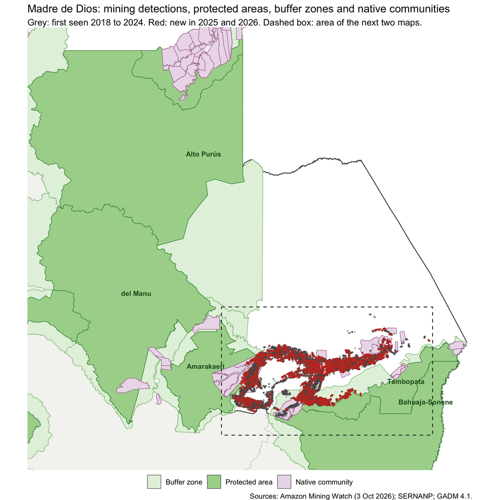

```r
pp <- pp %>% mutate(recent = if_else(grepl("2[56]$", onset), "New in 2025 and 2026", "First seen 2018 to 2024"))
ggplot() + map_base +
  geom_point(data = filter(pp, recent != "New in 2025 and 2026"), aes(x, y), colour = "grey35", size = 0.3, alpha = 0.4) +
  geom_point(data = filter(pp, recent == "New in 2025 and 2026"), aes(x, y), colour = col_alert, size = 0.5) +
  geom_sf_text(data = anp_labels, aes(label = anp_nomb), size = 3, colour = "#1E5A20", fontface = "bold") +
  annotate("rect", xmin = zx[1], xmax = zx[2], ymin = zy[1], ymax = zy[2], fill = NA, colour = "grey20", linetype = "dashed") +
  coord_sf(xlim = c(-72.5, -68.6), ylim = c(-13.6, -9.8), expand = FALSE) + theme_void() + theme(legend.position = "bottom") +
  labs(title = "Madre de Dios: mining detections, protected areas, buffer zones and native communities",
       subtitle = "Grey: first seen 2018 to 2024. Red: new in 2025 and 2026. Dashed box: area of the next two maps.",
       caption = "Sources: Amazon Mining Watch (3 Oct 2026); SERNANP; GADM 4.1.")
```

```r
ggsave(file.path(OUT, "map1_overview.png"), width = 8.5, height = 8.5, dpi = 200, bg = "white")
```

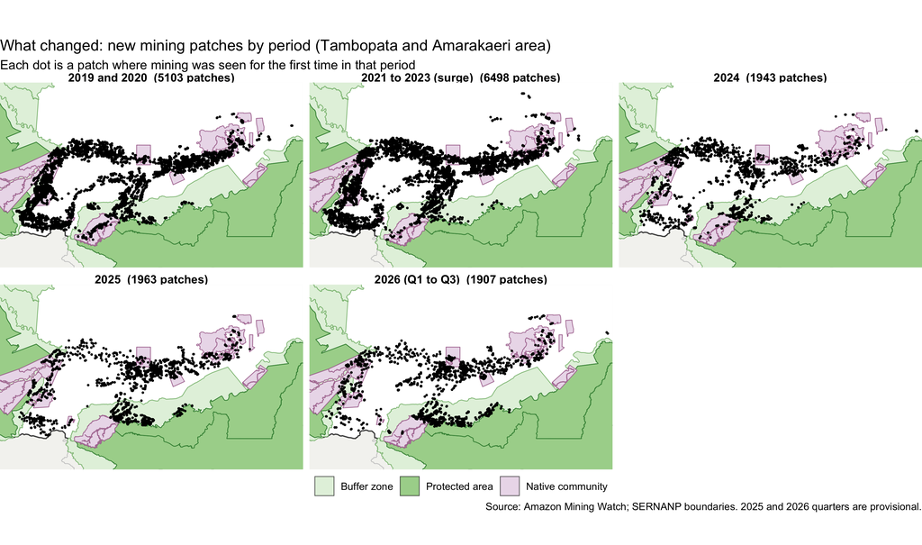

```r
periods <- c("2019 and 2020", "2021 to 2023 (surge)", "2024", "2025", "2026 (Q1 to Q3)")
pp2 <- pp %>% mutate(when = case_when(onset %in% c("2019", "2020") ~ periods[1], onset %in% c("2021", "2022", "2023") ~ periods[2],
                                      onset == "2024" ~ periods[3], grepl("25$", onset) ~ periods[4], grepl("26$", onset) ~ periods[5])) %>%
  filter(!is.na(when)) %>% mutate(when = factor(when, periods)) %>% add_count(when) %>%
  mutate(panel = factor(paste0(when, "  (", n, " patches)"))) %>% mutate(panel = fct_reorder(panel, as.numeric(when)))
ggplot() + map_base + geom_point(data = pp2, aes(x, y), colour = "black", size = 0.35) +
  facet_wrap(~panel, nrow = 2) + coord_sf(xlim = zx, ylim = zy, expand = FALSE) + theme_void() +
  theme(strip.text = element_text(face = "bold", size = 10), legend.position = "bottom") +
  labs(title = "What changed: new mining patches by period (Tambopata and Amarakaeri area)",
       subtitle = "Each dot is a patch where mining was seen for the first time in that period",
       caption = "Source: Amazon Mining Watch; SERNANP boundaries. 2025 and 2026 quarters are provisional.")
```

```r
ggsave(file.path(OUT, "map2_periods.png"), width = 11, height = 6.5, dpi = 200, bg = "white")

shift <- pp2 %>% mutate(fzs = category %in% c("Protected area", "Buffer zone")) %>% group_by(when) %>%
  summarise(patches = n(), `in reserves or buffer zones` = sum(fzs), `share (%)` = round(100 * mean(fzs)), .groups = "drop")
knitr::kable(shift, caption = "Share of new patches inside protected areas or buffer zones, by period")
```

Share of new patches inside protected areas or buffer zones, by period

| when | patches | in reserves or buffer zones | share (%) |
| --- | --- | --- | --- |
| 2019 and 2020 | 5103 | 966 | 19 |
| 2021 to 2023 (surge) | 6498 | 1065 | 16 |
| 2024 | 1943 | 412 | 21 |
| 2025 | 1963 | 515 | 26 |
| 2026 (Q1 to Q3) | 1907 | 768 | 40 |

```r
write_csv(shift, file.path(OUT, "table3d_amw_shift.csv"))
log_number("shift_surge", "Share of new AMW patches in reserves or buffer zones, 2021 to 2023", shift$`share (%)`[shift$when == periods[2]], "%", "Amazon Mining Watch + SERNANP")
log_number("shift_2026", "Share of new AMW patches in reserves or buffer zones, 2026 Q1 to Q3", shift$`share (%)`[shift$when == periods[5]], "%", "Amazon Mining Watch + SERNANP")
```

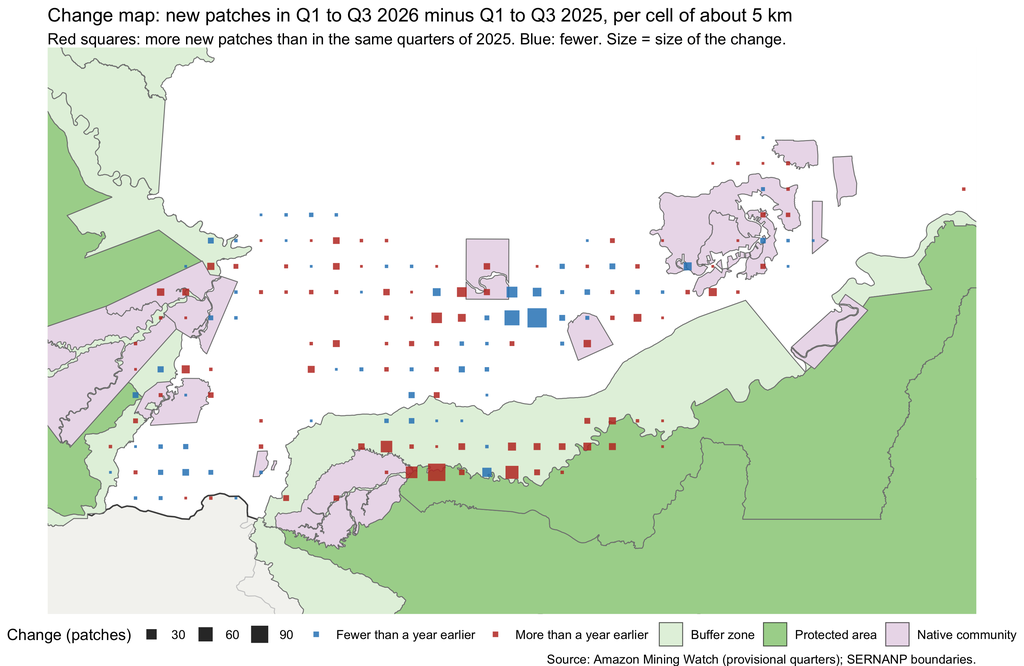

```r
cell <- 0.05   # about 5.5 km
grid <- pp %>% filter(onset %in% c("Q125", "Q225", "Q325", "Q126", "Q226", "Q326")) %>%
  mutate(yr = if_else(grepl("26$", onset), "y2026", "y2025"), cx = floor(x / cell) * cell + cell / 2, cy = floor(y / cell) * cell + cell / 2) %>%
  count(cx, cy, yr) %>% pivot_wider(names_from = yr, values_from = n, values_fill = 0) %>% mutate(change = y2026 - y2025) %>%
  filter(change != 0)   # cells with no change are not drawn
ggplot() + map_base +
  geom_point(data = grid, aes(cx, cy, size = abs(change), colour = if_else(change > 0, "More than a year earlier", "Fewer than a year earlier")),
             shape = 15, alpha = 0.85) +
  scale_colour_manual(values = c("More than a year earlier" = col_alert, "Fewer than a year earlier" = "#2E86C1"), name = NULL) +
  scale_size_area(max_size = 6, name = "Change (patches)") +
  coord_sf(xlim = zx, ylim = zy, expand = FALSE) + theme_void() + theme(legend.position = "bottom") +
  labs(title = "Change map: new patches in Q1 to Q3 2026 minus Q1 to Q3 2025, per cell of about 5 km",
       subtitle = "Red squares: more new patches than in the same quarters of 2025. Blue: fewer. Size = size of the change.",
       caption = "Source: Amazon Mining Watch (provisional quarters); SERNANP boundaries.")
```

```r
ggsave(file.path(OUT, "map3_change.png"), width = 10, height = 6.5, dpi = 200, bg = "white")
```

**[Description]** The share of new patches inside protected areas or buffer zones rose from 16% during the 2021 to 2023 surge to 40% in the first three quarters of 2026. New mining is moving south, towards the Tambopata buffer zone and reserve.

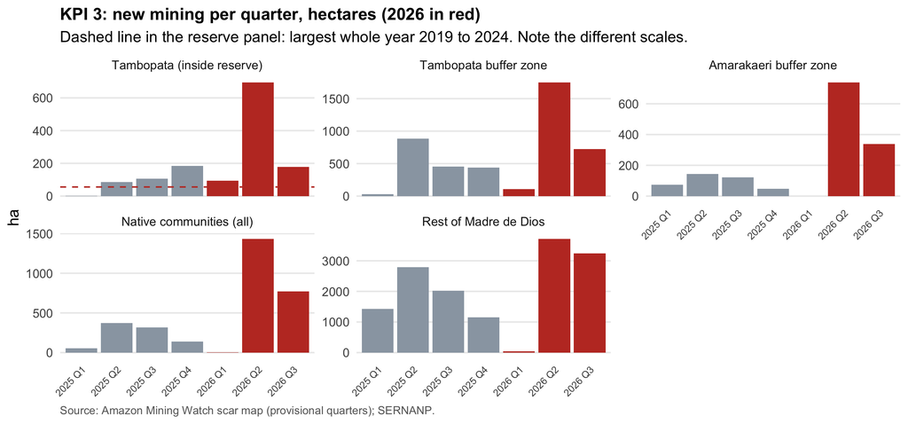

```r
k3 %>% filter(quarterly, landscape %in% watch6[c(1:4, 6)]) %>%
  ggplot(aes(period, ha, fill = grepl("2026", period))) + geom_col() +
  geom_hline(data = tibble(landscape = factor("Tambopata (inside reserve)", watch6), y = reserve_base_ha), aes(yintercept = y),
             colour = col_alert, linetype = "dashed") +
  facet_wrap(~landscape, scales = "free_y", nrow = 2) +
  scale_fill_manual(values = c(`FALSE` = col_grey, `TRUE` = col_alert), guide = "none") +
  labs(title = "KPI 3: new mining per quarter, hectares (2026 in red)",
       subtitle = "Dashed line in the reserve panel: largest whole year 2019 to 2024. Note the different scales.",
       x = NULL, y = "ha", caption = "Source: Amazon Mining Watch scar map (provisional quarters); SERNANP.") +
  theme(axis.text.x = element_text(angle = 45, hjust = 1, size = 7))
```

```r
ggsave(file.path(OUT, "fig_kpi3_quarters.png"), width = 9, height = 4.2, dpi = 200, bg = "white")
```

**What it does not show.** Mining again inside old pits (Amazon Mining Watch counts land only the first time), dredges on rivers (the model ignores them), and legality. The quarters are provisional and can be revised. Amazon Mining Watch rebuilt its model in 2026 and replaces its files, so FZS cannot see what the data said in the past: it should save a copy every quarter.

## 5.4 KPI 4 (late, yearly): forest that became mining

**Why.** This is the trusted yearly number for donors. It comes from MapBiomas Peru, which maps all of Peru every year since 1985. We count only **forest that became mining**, for the reason explained in Section 4. We show two lines:

- **Inside reserves and buffer zones**: four FZS landscapes (Tambopata, Amarakaeri, Bahuaja-Sonene and Manu), inside the reserves and in their buffer zones. This includes the parts outside Madre de Dios (Bahuaja-Sonene in Puno, part of Amarakaeri in Cusco). Inside a reserve mining is always illegal. In a buffer zone it needs SERNANP’s approval.
- **All of Madre de Dios.**

**Red line: this year is above the average of the previous five years plus two standard deviations.** This is a standard “control chart” rule: a value so far above the recent past that normal ups and downs do not explain it.

```r
control <- function(d) d %>% arrange(year) %>%
  mutate(mean5 = rollapplyr(lag(ha), 5, mean, fill = NA), sd5 = rollapplyr(lag(ha), 5, sd, fill = NA),
         limit = mean5 + 2 * sd5, red = ha > limit)
landscapes <- c("Tambopata", "Amarakaeri", "Bahuaja-Sonene", "del Manu")
ff_by <- function(tr, label) tr %>% filter(unit %in% landscapes, class_to == MINING, class_from %in% FOREST) %>%
  group_by(year) %>% summarise(ha = sum(ha), .groups = "drop") %>% mutate(zone = label)
k4 <- bind_rows(ff_by(tr_anp, "Inside the reserves"), ff_by(tr_za, "Buffer zones"),
                flows %>% transmute(year, ha = from_forest, zone = "All Madre de Dios")) %>%
  filter(year >= 2001) %>% group_by(zone) %>% group_modify(~ control(.x)) %>% ungroup() %>%
  mutate(zone = factor(zone, c("Inside the reserves", "Buffer zones", "All Madre de Dios")))
knitr::kable(k4 %>% filter(year >= 2016) %>% transmute(year, zone, txt = paste0(fmt(ha), " (", fmt(limit), ")", if_else(red %in% TRUE, " RED", ""))) %>%
               pivot_wider(names_from = zone, values_from = txt) %>% select(Year = year, all_of(levels(k4$zone))),
             caption = "KPI 4: forest that became mining, ha (red line in brackets). Reserves and buffer zones: Tambopata, Amarakaeri, Bahuaja-Sonene and Manu.")
```

KPI 4: forest that became mining, ha (red line in brackets). Reserves and buffer zones: Tambopata, Amarakaeri, Bahuaja-Sonene and Manu.

| Year | Inside the reserves | Buffer zones | All Madre de Dios |
| --- | --- | --- | --- |
| 2016 | 2 ( 16) | 1,133 ( 2,569) | 2,791 ( 4,957) |
| 2017 | 194 ( 10) RED | 2,346 ( 2,522) | 4,517 ( 4,939) |
| 2018 | 25 ( 212) | 1,956 ( 2,867) | 3,773 ( 5,400) |
| 2019 | 12 ( 213) | 1,649 ( 2,913) | 4,529 ( 5,365) |
| 2020 | 3 ( 212) | 727 ( 2,639) | 3,522 ( 5,354) |
| 2021 | 3 ( 213) | 1,129 ( 2,850) | 6,152 ( 5,289) RED |
| 2022 | 5 ( 213) | 1,475 ( 2,850) | 7,885 ( 6,552) RED |
| 2023 | 33 ( 28) RED | 2,165 ( 2,337) | 9,982 ( 8,835) RED |
| 2024 | 39 ( 37) RED | 1,827 ( 2,513) | 7,136 (11,598) |
| 2025 | 175 ( 52) RED | 2,992 ( 2,595) RED | 10,308 (11,677) |

```r
write_csv(k4, file.path(OUT, "table4_kpi4_forest_to_mining.csv"))
k4v <- function(z, y, v = "ha") k4[[v]][k4$zone == z & k4$year == y]
red_years <- function(z) paste(k4$year[k4$zone == z & k4$red %in% TRUE & k4$year >= 2016], collapse = ", ")
for (z in levels(k4$zone)) {
  id <- c("Inside the reserves" = "res", "Buffer zones" = "za", "All Madre de Dios" = "mdd")[z]
  log_number(paste0("k4_", id, "_2025"), paste("Forest to mining, 2025,", z), k4v(z, 2025), "ha", "MapBiomas C4 transitions")
  log_number(paste0("k4_", id, "_lim_2025"), paste("KPI 4 red line, 2025,", z), k4v(z, 2025, "limit"), "ha", "MapBiomas C4 transitions")
}
tamb_in <- cov_anp %>% filter(unit == "Tambopata", department == "Madre de Dios", class == MINING) %>% group_by(year) %>% summarise(ha = sum(ha))
log_number("tamb_anp_2025", "Mining area inside Tambopata National Reserve, 2025", tamb_in$ha[tamb_in$year == 2025], "ha", "MapBiomas C4 ANP")
log_number("tamb_anp_base", "Mining area inside Tambopata National Reserve, mean 2016 to 2020", mean(tamb_in$ha[tamb_in$year %in% 2016:2020]), "ha", "MapBiomas C4 ANP")
```

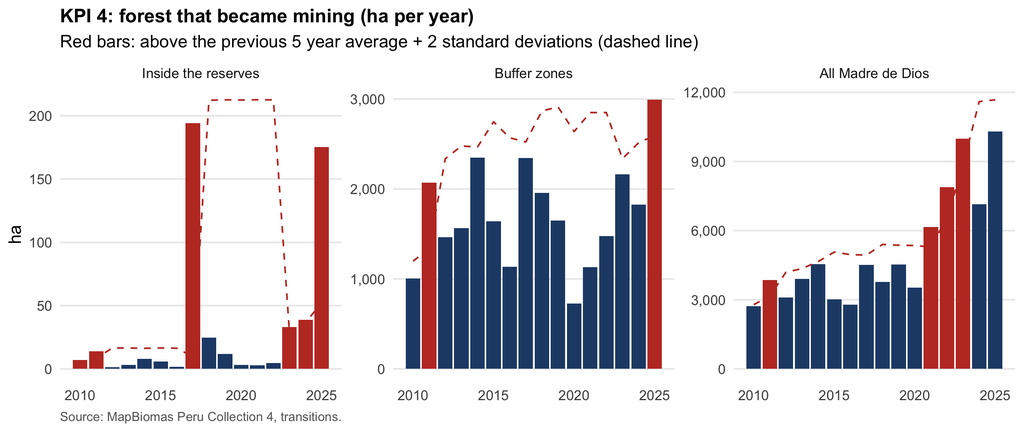

```r
ggplot(filter(k4, year >= 2010), aes(year, ha)) +
  geom_col(aes(fill = red %in% TRUE)) +
  geom_line(aes(y = limit), colour = col_alert, linetype = "dashed") +
  facet_wrap(~zone, scales = "free_y") +
  scale_fill_manual(values = c(`FALSE` = col_main, `TRUE` = col_alert), guide = "none") +
  scale_y_continuous(labels = scales::comma) + scale_x_continuous(breaks = seq(2010, 2025, 5)) +
  labs(title = "KPI 4: forest that became mining (ha per year)",
       subtitle = "Red bars: above the previous 5 year average + 2 standard deviations (dashed line)", x = NULL, y = "ha",
       caption = "Source: MapBiomas Peru Collection 4, transitions.")
```

```r
ggsave(file.path(OUT, "fig_kpi4.png"), width = 9, height = 3.8, dpi = 200, bg = "white")
```

**[Description]** In 2025, forest that became mining was **175 ha inside the reserves** (red line 52 ha) and **2,992 ha in their buffer zones** (red line 2,595 ha). Both are red. Red years since 2016: inside the reserves 2017, 2023, 2024, 2025; buffer zones 2025; all of Madre de Dios 2021, 2022, 2023.

**An honest limit of the rule.** In all of Madre de Dios, 2025 was the **highest year on record** (10,308 ha), but it is **not red**: the red line was 11,677 ha. The reason is that the red line uses the previous five years, and those include the surge years 2021 to 2023. After a surge, the line moves up, so only a new and even bigger jump is red. We double checked this with a second, separate calculation (in Python, straight from the MapBiomas file) and got the same numbers. This is why we **lead with the reserves and buffer zones line**: it is where FZS acts, and it turned red. FZS should also report the plain number every year (“highest on record”), not only the colour.

We report hectares, not the share of all new mining. During the surge the share inside FZS landscapes *fell* (the surge was mainly elsewhere in the department), so a share would hide growth inside them. MAAP’s own count for January 2021 to March 2024 (MAAP #208) puts 26.2% of mining deforestation outside the legal mining corridor: 14.6% in native communities and 7.9% in buffer zones.

**What it does not show.** Mining in rivers, mining again on old sites, mercury. It arrives late: each year’s map is published 5 to 17 months after the year ends. MapBiomas also revises earlier years in each new version (Section 10).

## 5.5 KPI 5 (now, quarterly): is mining spreading outside Madre de Dios?

**Why.** If FZS only watches Madre de Dios, it can miss a new mining front somewhere else in Peru. KPI 5 adds up new mining in **all of Peru outside Madre de Dios**, from the same scar map as KPI 3.

**Red line:** the same as for buffer zones in KPI 3: this year so far has more than 25% more new mining than the same quarters last year.

```r
out_mdd <- scar %>% filter(!mdd, period != "2018") %>%
  mutate(when = case_when(code %in% 2019:2024 ~ as.character(code), grepl("^2025", period) ~ "2025",
                          grepl("^2026", period) ~ "2026 (Q1 to Q3)"))
k5_dep <- out_mdd %>% group_by(department, when) %>% summarise(ha = sum(ha), .groups = "drop") %>%
  group_by(department) %>% filter(sum(ha) >= 100) %>% ungroup()
k5_tot <- out_mdd %>% group_by(when) %>% summarise(ha = sum(ha), .groups = "drop") %>% mutate(department = "Total outside Madre de Dios")
knitr::kable(bind_rows(k5_dep, k5_tot) %>% mutate(ha = fmt(ha)) %>% pivot_wider(names_from = when, values_from = ha, values_fill = "0") %>%
               rename(Department = department),
             caption = "New mining outside Madre de Dios, ha. 2019 to 2024 confirmed; 2025 = sum of four provisional quarters; 2026 = three provisional quarters. Departments with at least 100 ha in total.")
```

New mining outside Madre de Dios, ha. 2019 to 2024 confirmed; 2025 = sum of four provisional quarters; 2026 = three provisional quarters. Departments with at least 100 ha in total.

| Department | 2019 | 2020 | 2021 | 2022 | 2023 | 2024 | 2025 | 2026 (Q1 to Q3) |
| --- | --- | --- | --- | --- | --- | --- | --- | --- |
| Cusco | 576 | 470 | 456 | 222 | 434 | 251 | 542 | 103 |
| Huánuco | 59 | 69 | 190 | 381 | 237 | 842 | 1,712 | 1,227 |
| Loreto | 116 | 44 | 116 | 26 | 91 | 122 | 342 | 287 |
| Puno | 230 | 233 | 168 | 254 | 411 | 241 | 544 | 470 |
| Ucayali | 11 | 9 | 18 | 0 | 4 | 37 | 20 | 49 |
| Total outside Madre de Dios | 992 | 825 | 949 | 896 | 1,177 | 1,493 | 3,304 | 2,168 |

```r
write_csv(bind_rows(k5_dep, k5_tot), file.path(OUT, "table5_kpi5_outside_mdd.csv"))

k5_q <- out_mdd %>% filter(grepl("Q", period)) %>% group_by(period) %>% summarise(ha = sum(ha))
k5_25 <- sum(k5_q$ha[k5_q$period %in% q_last]); k5_26 <- sum(k5_q$ha[k5_q$period %in% q_now])
k5_change <- 100 * (k5_26 / k5_25 - 1)

# Who holds the land: mining title and the El Sira buffer zone (Huánuco)
k5_title <- out_mdd %>% filter(when %in% c("2024", "2025")) %>% group_by(when) %>%
  summarise(titled = 100 * sum(ha[conc]) / sum(ha), sira = 100 * sum(ha[za_sira]) / sum(ha),
            huanuco = 100 * sum(ha[department == "Huánuco"]) / sum(ha), ha = sum(ha), .groups = "drop")
knitr::kable(k5_title %>% transmute(Year = when, `New mining outside Madre de Dios (ha)` = fmt(ha),
                                    `in Huánuco (%)` = round(huanuco), `in the El Sira buffer zone (%)` = round(sira),
                                    `inside a mining concession (%)` = round(titled)),
             caption = "Where the new mining outside Madre de Dios is")
```

Where the new mining outside Madre de Dios is

| Year | New mining outside Madre de Dios (ha) | in Huánuco (%) | in the El Sira buffer zone (%) | inside a mining concession (%) |
| --- | --- | --- | --- | --- |
| 2024 | 1,493 | 56 | 56 | 69 |
| 2025 | 3,304 | 52 | 51 | 65 |

```r
k5v <- function(w, d = "Total outside Madre de Dios") bind_rows(k5_dep, k5_tot)$ha[bind_rows(k5_dep, k5_tot)$when == w & bind_rows(k5_dep, k5_tot)$department == d]
log_number("k5_2019", "New mining outside Madre de Dios, 2019", k5v("2019"), "ha", "AMW scar map + GADM")
log_number("k5_2024", "New mining outside Madre de Dios, 2024", k5v("2024"), "ha", "AMW scar map + GADM")
log_number("k5_2025", "New mining outside Madre de Dios, 2025 (4 provisional quarters)", k5v("2025"), "ha", "AMW scar map + GADM")
log_number("k5_huanuco_2019", "New mining in Huánuco, 2019", k5v("2019", "Huánuco"), "ha", "AMW scar map + GADM")
log_number("k5_huanuco_2025", "New mining in Huánuco, 2025 (provisional)", k5v("2025", "Huánuco"), "ha", "AMW scar map + GADM")
log_number("k5_ytd25", "New mining outside Madre de Dios, Q1 to Q3 2025", k5_25, "ha", "AMW scar map + GADM")
log_number("k5_ytd26", "New mining outside Madre de Dios, Q1 to Q3 2026", k5_26, "ha", "AMW scar map + GADM")
log_number("k5_change", "New mining outside Madre de Dios, Q1 to Q3 2026 vs 2025", k5_change, "%", "AMW scar map + GADM")
log_number("k5_titled_2025", "Share of new mining outside Madre de Dios inside a mining concession, 2025", k5_title$titled[k5_title$when == "2025"], "%", "AMW scar map + INGEMMET")
log_number("k5_sira_2025", "Share of new mining outside Madre de Dios in the El Sira buffer zone, 2025", k5_title$sira[k5_title$when == "2025"], "%", "AMW scar map + SERNANP")
```

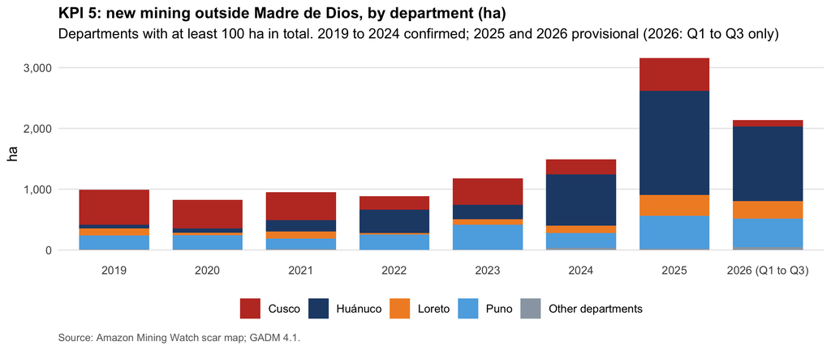

```r
bind_rows(k5_dep) %>% mutate(department = fct_lump_n(department, 4, w = ha, other_level = "Other departments")) %>%
  group_by(department, when) %>% summarise(ha = sum(ha), .groups = "drop") %>%
  ggplot(aes(when, ha, fill = department)) + geom_col(width = 0.75) +
  scale_fill_manual(values = c(col_alert, col_main, col_soft, "#5DADE2", col_grey), name = NULL) +
  scale_y_continuous(labels = scales::comma) +
  labs(title = "KPI 5: new mining outside Madre de Dios, by department (ha)",
       subtitle = "Departments with at least 100 ha in total. 2019 to 2024 confirmed; 2025 and 2026 provisional (2026: Q1 to Q3 only)",
       x = NULL, y = "ha", caption = "Source: Amazon Mining Watch scar map; GADM 4.1.")
```

```r
ggsave(file.path(OUT, "fig_kpi5.png"), width = 9, height = 3.8, dpi = 200, bg = "white")
```

**[Description]** Outside Madre de Dios, new mining went from 992 ha in 2019 to 1,493 ha in 2024, and 3,304 ha in 2025 (provisional). It is still small next to Madre de Dios, but it is growing. Most of the growth is in **Huánuco** (59 ha in 2019, 1,712 ha in 2025), around the El Sira buffer zone near Puerto Inca. Pietro found this first. Likitha found a break out in the El Sira buffer zone with the detections.

**Today KPI 5 is not red:** the first three quarters of 2026 had 2,168 ha against 2,434 ha a year earlier (-11%).

**Be careful with the words.** In 2025, 65% of the new mining outside Madre de Dios was **inside a mining concession** (titled or in process). So this is “mining spreading”, **not** “illegal mining spreading”. FZS should watch it because a new front can grow fast, and because the El Sira buffer zone protects a reserve.

**What it does not show.** Same limits as KPI 3. Also, 2025 is the sum of four provisional quarters, which use a stricter rule than the confirmed years, so 2025 and 2024 are not exactly comparable. We have the concession map only for the two map zones on SERNANP’s service (UTM zones 18 and 19), which cover all departments with mining here except small parts of Amazonas, Cajamarca and Piura.

# 6 How we set the red lines, and would they have warned in time?

**The rules.** We used two kinds of red line. For noisy numbers with a long history, a statistical rule: “above the recent average plus two standard deviations”. For short or new series, a simple rule that a director can check by eye: “20% above”, “25% more”, “more than the worst year”. The table shows each rule and why.

```r
thr <- tribble(
  ~KPI, ~`Red when`, ~`Why this rule`, ~`Today`,
  "1 Gold price in soles", "Ratio to the 3 year average reaches 1.20",
    "A 20% rise in real income is large for a miner; a round number is easy to check",
    paste0(round(latest$ratio, 2), " in ", format(latest$date, "%b %Y"), if (latest$signal) ": RED" else ": not red"),
  "2 Peru's gold gap", paste0("12 month gap more than ", round(X, 1), " points above one year earlier"),
    "The gap is always high, so we watch jumps. X = 2014 to 2016 average change + 2 standard deviations",
    paste0(sprintf("%+.1f", gap_latest$jump), " points in ", format(gap_latest$date, "%b %Y"), if (gap_latest$signal %in% TRUE) ": RED" else ": not red"),
  "3 New mining in FZS landscapes (reserve)", paste0("A quarter above the largest whole year 2019 to 2024 (", fmt(reserve_base_ha), " ha)"),
    "Some mining appears every year, so 'any mining' would always be red",
    paste0(fmt(reserve_q$ha[reserve_q$period == "2026 Q3"]), " ha in 2026 Q3: ", if (reserve_q$red[reserve_q$period == "2026 Q3"]) "RED" else "not red"),
  "3 New mining in FZS landscapes (buffer zones, native communities)", "Quarters so far this year 25% above the same quarters last year",
    "Same quarters because of the dry season and clouds; 25% is a clear rise, not noise",
    paste0("Tambopata buffer ", pct(yv("Tambopata buffer zone", "change")), ", Amarakaeri ", pct(yv("Amarakaeri buffer zone", "change")),
           ", native communities ", pct(yv("Native communities (all)", "change")), ": RED"),
  "4 Forest that became mining", "Above the previous 5 year average + 2 standard deviations",
    "Standard control chart rule for a long yearly series",
    paste0("2025: reserves and buffer zones RED; all Madre de Dios not red (record year, see KPI 4)"),
  "5 New mining outside Madre de Dios", "Quarters so far this year 25% above the same quarters last year",
    "Same rule as KPI 3 buffer zones",
    paste0(pct(k5_change), ": ", if (k5_change > 25) "RED" else "not red"))
knitr::kable(thr, caption = "The red line of each KPI")
```

The red line of each KPI

| KPI | Red when | Why this rule | Today |
| --- | --- | --- | --- |
| 1 Gold price in soles | Ratio to the 3 year average reaches 1.20 | A 20% rise in real income is large for a miner; a round number is easy to check | 1.23 in Sep 2026: RED |
| 2 Peru’s gold gap | 12 month gap more than 6 points above one year earlier | The gap is always high, so we watch jumps. X = 2014 to 2016 average change + 2 standard deviations | +2.0 points in Jun 2026: not red |
| 3 New mining in FZS landscapes (reserve) | A quarter above the largest whole year 2019 to 2024 (56 ha) | Some mining appears every year, so ‘any mining’ would always be red | 178 ha in 2026 Q3: RED |
| 3 New mining in FZS landscapes (buffer zones, native communities) | Quarters so far this year 25% above the same quarters last year | Same quarters because of the dry season and clouds; 25% is a clear rise, not noise | Tambopata buffer +89%, Amarakaeri +219%, native communities +196%: RED |
| 4 Forest that became mining | Above the previous 5 year average + 2 standard deviations | Standard control chart rule for a long yearly series | 2025: reserves and buffer zones RED; all Madre de Dios not red (record year, see KPI 4) |
| 5 New mining outside Madre de Dios | Quarters so far this year 25% above the same quarters last year | Same rule as KPI 3 buffer zones | -11%: not red |

```r
write_csv(thr, file.path(OUT, "table6_red_lines.csv"))
```

**The backtest.** Using only data that were public at the time, when would each KPI have warned FZS about the 2021 to 2023 surge? We use the dates when each source was first published. MapBiomas Peru presented Collection 1 (maps to 2021) on 3 March 2023 (reported by Panamericana that day), Collection 2 (to 2022) on 15 February 2024 (MapBiomas Peru’s website), Collection 3 (to 2024) on 5 June 2025 (MapBiomas Peru’s website; Mongabay reported it on 12 June), and Collection 4 (to 2025) on 20 August 2026 (Caretas). MAAP published 18,421 ha for 2021 and 2022 on 15 June 2023 (#185), and 28,292 ha for 2021 to 2023 on 8 May 2024 (#208).

```r
release <- tribble(~covers_to, ~release_date,
                   2021, as.Date("2023-03-03"), 2022, as.Date("2024-02-15"),
                   2024, as.Date("2025-06-05"), 2025, as.Date("2026-08-20"))   # dates of each collection's presentation
first_release <- function(y) min(release$release_date[release$covers_to >= y])
k1_first <- first_signals$date[first_signals$date >= as.Date("2019-01-01")][1]
k2_first <- episodes$from[episodes$from >= as.Date("2019-01-01")][1]
k4_first <- function(z) { y <- k4$year[k4$zone == z & k4$red %in% TRUE & k4$year %in% 2019:2025]; if (length(y)) y else NA }
delay_months <- sapply(2021:2025, function(y) as.numeric(first_release(y) - as.Date(paste0(y, "-12-31"))) / 30.44)
net_cc <- flows %>% filter(year >= 2005) %>% arrange(year) %>%
  mutate(limit = rollapplyr(lag(net_addition), 5, mean, fill = NA) + 2 * rollapplyr(lag(net_addition), 5, sd, fill = NA),
         red = net_addition > limit)
net_years <- net_cc$year[net_cc$red %in% TRUE & net_cc$year %in% 2019:2024]
mdd_years <- k4_first("All Madre de Dios"); res_years_red <- k4_first("Inside the reserves"); za_years_red <- k4_first("Buffer zones")

bt <- tribble(
  ~KPI, ~`First red (data)`, ~`Public by`, ~Comment,
  "1 Gold price in soles", format(k1_first, "%b %Y"), format(k1_first + 35, "%b %Y"),
     "Before the surge. Red again from late 2024, before the record year 2025",
  "2 Peru's gold gap (jump)", format(k2_first, "%b %Y"), format(k2_first + 61, "%b %Y"),
     "In the first year of the surge; BCRP publishes about two months later. An earlier red period (2017 and 2018) had no surge after it",
  "3 New mining in FZS landscapes (quarterly)", first_reserve_red, "days after the quarter",
     "Quarterly data start in 2025, so this KPI cannot be tested on the surge. The yearly detections did not rise in 2021 to 2023",
  "4 Forest that became mining, all Madre de Dios", paste(mdd_years, collapse = ", "), format(first_release(min(mdd_years)), "%d %b %Y"),
     paste0("Each year was first mapped ", round(min(delay_months)), " to ", round(max(delay_months)), " months after it ended (", paste(round(delay_months), collapse = ", "), " months for 2021 to 2025)"),
  "4 Forest that became mining, reserves / buffer zones", paste0(paste(res_years_red, collapse = ", "), " / ", paste(za_years_red, collapse = ", ")),
     format(first_release(min(c(res_years_red, za_years_red), na.rm = TRUE)), "%d %b %Y"), "Inside the reserves from 2023; buffer zones in 2025",
  "5 New mining outside Madre de Dios", "not red", "days after the quarter", "Quarterly data start in 2025; cannot be tested on the surge",
  "For reference: MAAP mining deforestation", paste0("2021 and 2022: ", fmt(pub("maap185_2122")), " ha"), "15 Jun 2023",
     "No single year 2023 figure published; we do not subtract totals from different reports",
  "For reference: net addition (same rule as KPI 4)", paste(net_years, collapse = ", "), format(first_release(min(net_years)), "%d %b %Y"), "Pushed up in 2023 by water relabelled as mining")
knitr::kable(bt, caption = "Backtest: when each KPI would first have turned red, and when the data were public")
```

Backtest: when each KPI would first have turned red, and when the data were public

| KPI | First red (data) | Public by | Comment |
| --- | --- | --- | --- |
| 1 Gold price in soles | Feb 2020 | Mar 2020 | Before the surge. Red again from late 2024, before the record year 2025 |
| 2 Peru’s gold gap (jump) | Apr 2021 | Jun 2021 | In the first year of the surge; BCRP publishes about two months later. An earlier red period (2017 and 2018) had no surge after it |
| 3 New mining in FZS landscapes (quarterly) | 2025 Q2 | days after the quarter | Quarterly data start in 2025, so this KPI cannot be tested on the surge. The yearly detections did not rise in 2021 to 2023 |
| 4 Forest that became mining, all Madre de Dios | 2021, 2022, 2023 | 03 Mar 2023 | Each year was first mapped 5 to 17 months after it ended (14, 14, 17, 5, 8 months for 2021 to 2025) |
| 4 Forest that became mining, reserves / buffer zones | 2023, 2024, 2025 / 2025 | 05 Jun 2025 | Inside the reserves from 2023; buffer zones in 2025 |
| 5 New mining outside Madre de Dios | not red | days after the quarter | Quarterly data start in 2025; cannot be tested on the surge |
| For reference: MAAP mining deforestation | 2021 and 2022: 18,421 ha | 15 Jun 2023 | No single year 2023 figure published; we do not subtract totals from different reports |
| For reference: net addition (same rule as KPI 4) | 2022, 2023 | 15 Feb 2024 | Pushed up in 2023 by water relabelled as mining |

```r
write_csv(bt, file.path(OUT, "table7_backtest.csv"))
```

**[Description]** The two early KPIs moved before the yearly maps. KPI 1 was red from February 2020, and KPI 2 from April 2021. The yearly maps first showed the surge on 3 March 2023.

**Three cautions.**

1. **We chose the rules after seeing the data.** We knew a surge happened in 2021 to 2023. So the backtest shows what the rules *would* have done; it does not prove they work. The fair test is the next two years.
2. **We use today’s numbers with yesterday’s dates.** We use Collection 4 values with the release dates of earlier collections, because earlier Madre de Dios figures are not in a downloadable table. Each collection revises earlier years: for 2022, Collection 2 reported about 82,900 ha of mining in Madre de Dios, and Collection 4 now reports 74,966 ha (-10%). So the backtest shows timing, not the exact values FZS would have seen.
3. **The early KPIs also give warnings with no surge after them** (KPI 2 in 2017 and 2018). An early signal shows pressure building; it is not a forecast that mining will rise.

# 7 Main figure for the brief

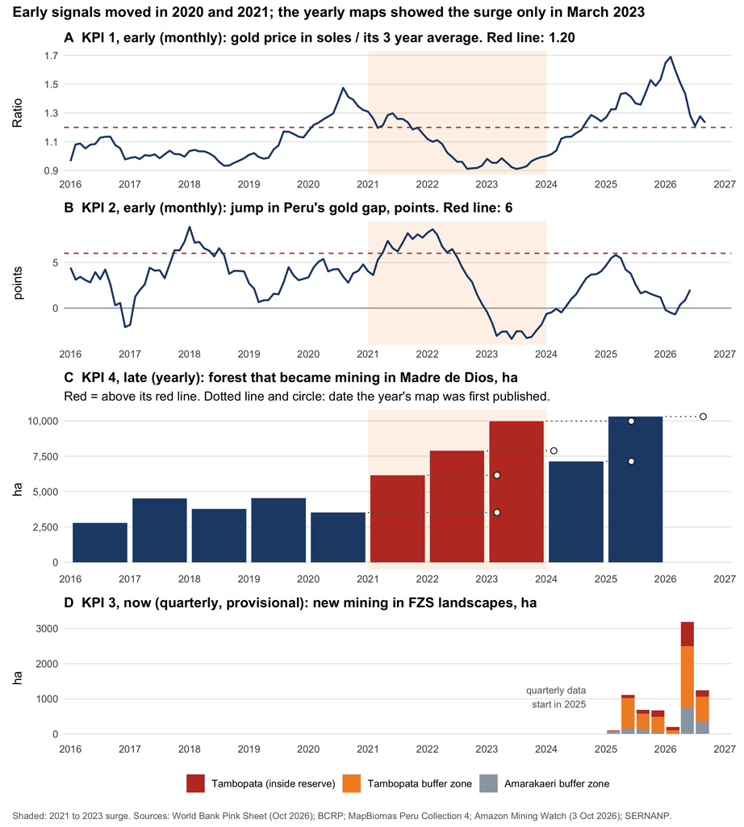

```r
lims <- as.Date(c("2016-01-01", "2026-12-31"))
surge <- annotate("rect", xmin = as.Date("2021-01-01"), xmax = as.Date("2023-12-31"), ymin = -Inf, ymax = Inf, fill = col_soft, alpha = 0.12)
p1 <- ggplot(filter(gold, date >= lims[1]), aes(date, ratio)) + surge +
  geom_hline(yintercept = 1.2, colour = col_alert, linetype = "dashed") +
  geom_line(colour = col_main, linewidth = 0.8) +
  labs(title = "A  KPI 1, early (monthly): gold price in soles / its 3 year average. Red line: 1.20", x = NULL, y = "Ratio")
p2 <- ggplot(filter(bm_roll, date >= lims[1]), aes(date, jump)) + surge +
  geom_hline(yintercept = X, colour = col_alert, linetype = "dashed") + geom_hline(yintercept = 0, colour = col_grey) +
  geom_line(colour = col_main, linewidth = 0.8) +
  labs(title = paste0("B  KPI 2, early (monthly): jump in Peru's gold gap, points. Red line: ", round(X, 1)), x = NULL, y = "points")
delay <- k4 %>% filter(zone == "All Madre de Dios", year >= 2016) %>%
  mutate(end = as.Date(paste0(year, "-12-31")), public = sapply(year, first_release) %>% as.Date(origin = "1970-01-01"))
p3 <- ggplot(delay) + surge +
  geom_rect(aes(xmin = as.Date(paste0(year, "-01-15")), xmax = as.Date(paste0(year, "-12-15")), ymin = 0, ymax = ha, fill = red %in% TRUE)) +
  geom_segment(data = filter(delay, year >= 2020), aes(x = end, xend = public, y = ha, yend = ha), colour = "grey35", linetype = "dotted") +
  geom_point(data = filter(delay, year >= 2020), aes(public, ha), shape = 21, fill = "white", size = 2.2) +
  scale_fill_manual(values = c(`FALSE` = col_main, `TRUE` = col_alert), guide = "none") +
  scale_y_continuous(labels = scales::comma) +
  labs(title = "C  KPI 4, late (yearly): forest that became mining in Madre de Dios, ha",
       subtitle = "Red = above its red line. Dotted line and circle: date the year's map was first published.", x = NULL, y = "ha")
q_plot <- k3 %>% filter(quarterly, landscape %in% watch[1:3]) %>%
  mutate(date = as.Date(sprintf("%s-%02d-15", substr(period, 1, 4), 3 * as.integer(substr(period, 7, 7)) - 1)),
         landscape = droplevels(landscape))
p4 <- ggplot(q_plot, aes(date, ha, fill = landscape)) +
  geom_col(width = 80) +
  scale_fill_manual(values = c("Tambopata (inside reserve)" = col_alert, "Tambopata buffer zone" = col_soft, "Amarakaeri buffer zone" = col_grey)) +
  annotate("text", x = as.Date("2024-09-01"), y = max(q_plot$ha) * 0.6, label = "quarterly data\nstart in 2025", hjust = 1, size = 3, colour = "grey40") +
  labs(title = "D  KPI 3, now (quarterly, provisional): new mining in FZS landscapes, ha", x = NULL, y = "ha", fill = NULL)
(p1 / p2 / p3 / p4) + plot_layout(heights = c(1, 1, 1.3, 1)) &
  scale_x_date(limits = lims, date_breaks = "1 year", date_labels = "%Y", expand = c(0.01, 0)) &
  plot_annotation(title = "Early signals moved in 2020 and 2021; the yearly maps showed the surge only in March 2023",
                  caption = "Shaded: 2021 to 2023 surge. Sources: World Bank Pink Sheet (Oct 2026); BCRP; MapBiomas Peru Collection 4; Amazon Mining Watch (3 Oct 2026); SERNANP.",
                  theme = theme(plot.title = element_text(face = "bold", size = 12.5)))
```

```r
ggsave(file.path(OUT, "fig_main.png"), width = 9.5, height = 10, dpi = 250, bg = "white")
```

# 8 Summary table for FZS

```r
kpi <- tribble(
  ~KPI, ~Speed, ~`Value today`, ~Source, ~`Updated (delay)`, ~`Red when`, ~`Action when red`, ~`Does not show`,
  "1 Gold price in soles vs its 3 year average", "Early",
    paste0(round(latest$ratio, 2), " (", format(latest$date, "%b %Y"), "): ", if (latest$signal) "RED" else "not red"),
    "World Bank Pink Sheet; BCRP", "Monthly (about 1 month)", "Ratio reaches 1.20",
    "Brief partners; plan more patrols and flights for the next dry season",
    "Where or how much mining will follow",
  "2 Peru's gold gap (exports minus declared production)", "Early",
    paste0(round(gap_latest$gap12), "% of exports (12 months to ", format(gap_latest$date, "%b %Y"), "); change ", sprintf("%+.1f", gap_latest$jump), " points: not red"),
    "BCRP", "Monthly (about 2 months)", paste0("Jump of more than ", round(X, 1), " points on a year earlier"),
    "Push buyers and ministries for gold traceability; expect more mining pressure",
    "Where the gold was mined; includes other regions and smuggled gold",
  "3 New mining in FZS landscapes", "Now",
    paste0(fmt(yv("Tambopata (inside reserve)", "ha26")), " ha inside the Tambopata reserve in Q1 to Q3 2026 (", fmt(yv("Tambopata (inside reserve)", "ha25")), " ha a year earlier): RED"),
    "Amazon Mining Watch; SERNANP", "Quarterly (days; provisional)",
    paste0("Reserve: a quarter above ", fmt(reserve_base_ha), " ha. Buffer zones and native communities: +25% on the same quarters last year"),
    "Send locations to SERNANP and the environmental prosecutor; check on images; flight over the area",
    "Mining again in old pits; dredges; legality",
  "4 Forest that became mining", "Late",
    paste0(fmt(k4v("Inside the reserves", 2025)), " ha inside reserves and ", fmt(k4v("Buffer zones", 2025)), " ha in buffer zones in 2025: RED. All Madre de Dios ",
           fmt(k4v("All Madre de Dios", 2025)), " ha, record year"),
    "MapBiomas Peru Collection 4", "Yearly (5 to 17 months)", "Above the previous 5 year average + 2 standard deviations",
    "Report to donors and government; ask for action at the named place",
    "Rivers; mining again on old sites; mercury",
  "5 New mining outside Madre de Dios", "Now",
    paste0(fmt(k5_26), " ha in Q1 to Q3 2026 (", pct(k5_change), "): not red. 2025: ", fmt(k5v("2025")), " ha, most in Huánuco"),
    "Amazon Mining Watch; GADM", "Quarterly (days; provisional)", "+25% on the same quarters last year",
    "Tell SERNANP and the regional government about a new front; check concessions",
    "Legality (most is inside concessions); rivers")
knitr::kable(kpi, caption = "Five indicators for FZS")
```

Five indicators for FZS

| KPI | Speed | Value today | Source | Updated (delay) | Red when | Action when red | Does not show |
| --- | --- | --- | --- | --- | --- | --- | --- |
| 1 Gold price in soles vs its 3 year average | Early | 1.23 (Sep 2026): RED | World Bank Pink Sheet; BCRP | Monthly (about 1 month) | Ratio reaches 1.20 | Brief partners; plan more patrols and flights for the next dry season | Where or how much mining will follow |
| 2 Peru’s gold gap (exports minus declared production) | Early | 51% of exports (12 months to Jun 2026); change +2.0 points: not red | BCRP | Monthly (about 2 months) | Jump of more than 6 points on a year earlier | Push buyers and ministries for gold traceability; expect more mining pressure | Where the gold was mined; includes other regions and smuggled gold |
| 3 New mining in FZS landscapes | Now | 966 ha inside the Tambopata reserve in Q1 to Q3 2026 (194 ha a year earlier): RED | Amazon Mining Watch; SERNANP | Quarterly (days; provisional) | Reserve: a quarter above 56 ha. Buffer zones and native communities: +25% on the same quarters last year | Send locations to SERNANP and the environmental prosecutor; check on images; flight over the area | Mining again in old pits; dredges; legality |
| 4 Forest that became mining | Late | 175 ha inside reserves and 2,992 ha in buffer zones in 2025: RED. All Madre de Dios 10,308 ha, record year | MapBiomas Peru Collection 4 | Yearly (5 to 17 months) | Above the previous 5 year average + 2 standard deviations | Report to donors and government; ask for action at the named place | Rivers; mining again on old sites; mercury |
| 5 New mining outside Madre de Dios | Now | 2,168 ha in Q1 to Q3 2026 (-11%): not red. 2025: 3,304 ha, most in Huánuco | Amazon Mining Watch; GADM | Quarterly (days; provisional) | +25% on the same quarters last year | Tell SERNANP and the regional government about a new front; check concessions | Legality (most is inside concessions); rivers |

```r
write_csv(kpi, file.path(OUT, "table8_kpi_summary.csv"))
```

# 9 Context: other signals we checked

These signals are useful to understand the problem, and some are strong for one country. But each has a problem that stops it from being one of FZS’s five yearly indicators. They are descriptions only; none of them shows what causes mining.

```r
num <- function(x) as.numeric(gsub(",", "", x))
ctry <- c(`604` = "Peru", `170` = "Colombia", `76` = "Brazil", `68` = "Bolivia", `218` = "Ecuador",
          `862` = "Venezuela", `328` = "Guyana", `740` = "Suriname", `484` = "Mexico")
read_comtrade <- function(pattern) map_dfr(list.files(REG, pattern, full.names = TRUE), function(f) {
  d <- fromJSON(f)$data
  if (length(d) == 0 || NROW(d) == 0) return(NULL)
  as_tibble(d) %>% filter(customsCode == "C00", motCode == 0, partner2Code == 0, partnerCode == 0) %>%   # drop duplicate rows
    transmute(year = as.integer(period), country = ctry[as.character(reporterCode)], flow = flowCode,
              kg = netWgt, usd = primaryValue, qty = qty)
})
ct_gold <- read_comtrade("^comtrade_gold_exports_")
ct_hg   <- read_comtrade("^comtrade_mercury_")
ct_exc  <- read_comtrade("^comtrade_excavators_")
check("UN Comtrade: Bolivia mercury imports 2016 (kg)", sum(ct_hg$kg[ct_hg$country == "Bolivia" & ct_hg$year == 2016 & ct_hg$flow == "M"]), 224195)
```

```
## OK   UN Comtrade: Bolivia mercury imports 2016 (kg)                              224,194.9   (publisher: 224,195)
```

```r
check("UN Comtrade: Peru mercury imports 2014 (kg)", sum(ct_hg$kg[ct_hg$country == "Peru" & ct_hg$year == 2014 & ct_hg$flow == "M"]), 102344)
```

```
## OK   UN Comtrade: Peru mercury imports 2014 (kg)                                 102,344.1   (publisher: 102,344)
```

| Signal | What it shows | Why it is context, not a KPI |
| --- | --- | --- |
| New mining by country (Amazon Mining Watch) | Peru, Colombia, Brazil on one scale | Misses river mining, which is most of Colombia’s |
| Gold trade in Colombia and Brazil | Where illegal gold enters the legal chain | No export gap to measure; smuggling moves outside the data |
| Mercury imports | Legal mercury collapsed; supply moved to Bolivia and smuggling | Legal trade no longer measures mercury use |
| Coca | Shares land with gold mining | Moves with eradication; prices stop in 2023; no tested link to gold |
| Malaria in Brazilian garimpos | People working in mining, also on rivers | Strong for Brazil only; depends on testing |
| Aviation fuel in Brazil | Supply of remote garimpos by plane | Legal uses too; series ends in 2024 |
| Dredges seized in Colombia | River mining machines | Measures police effort as much as mining |
| Dredges in Loreto (MAAP) | River mining in Peru | Irregular reports; no count for Madre de Dios rivers |
| Excavator imports | Machines for mining | Also used for roads and farms |
| Traffic at highway tolls (Likitha) | Trucks and people moving on the mining road | Only 3 tolls; one toll did not count for 16 months; we do not know what trucks carry |

## 9.1 New mining by country

```r
read_gadm0 <- function(cc) st_read(paste0("/vsizip/", normalizePath(file.path(REG, sprintf("gadm41_%s_0.json.zip", cc))), "/", sprintf("gadm41_%s_0.json", cc)), quiet = TRUE)
countries <- bind_rows(dep1 %>% st_union() %>% st_sf(geometry = .) %>% mutate(country = "Peru"),
                       read_gadm0("COL") %>% transmute(country = "Colombia"), read_gadm0("BRA") %>% transmute(country = "Brazil"))
amw_c <- amw_pts_all %>% mutate(country = countries$country[sapply(st_intersects(amw_pts_all, countries), function(i) if (length(i)) i[1] else NA)],
                                country = replace_na(country, "Other Amazon countries"),
                                period = if_else(grepl("^Q", onset), paste0("20", substr(onset, 3, 4), " Q", substr(onset, 2, 2)), onset)) %>%
  st_drop_geometry()
amw_country <- amw_c %>% filter(period != "2018") %>% count(country, period) %>%
  pivot_wider(names_from = country, values_from = n, values_fill = 0) %>% arrange(period)
knitr::kable(amw_country, caption = "Amazon Mining Watch: new mining patches by country and first period (2019 to 2024 confirmed; quarters provisional)")
```

Amazon Mining Watch: new mining patches by country and first period (2019 to 2024 confirmed; quarters provisional)

| period | Brazil | Colombia | Other Amazon countries | Peru |
| --- | --- | --- | --- | --- |
| 2019 | 10212 | 1 | 6622 | 2562 |
| 2020 | 9473 | 0 | 6474 | 2739 |
| 2021 | 10956 | 2 | 5969 | 2629 |
| 2022 | 11193 | 7 | 5456 | 2014 |
| 2023 | 8364 | 12 | 6980 | 2184 |
| 2024 | 4041 | 6 | 3400 | 2072 |
| 2025 Q1 | 282 | 3 | 2604 | 316 |
| 2025 Q2 | 2450 | 0 | 793 | 798 |
| 2025 Q3 | 2123 | 16 | 2672 | 807 |
| 2025 Q4 | 686 | 0 | 736 | 475 |
| 2026 Q1 | 216 | 3 | 463 | 38 |
| 2026 Q2 | 2635 | 9 | 1946 | 1192 |
| 2026 Q3 | 3926 | 42 | 3079 | 976 |

```r
write_csv(amw_country, file.path(OUT, "tableR1_amw_by_country.csv"))
yq <- function(cn, yy) sum(amw_c$country == cn & amw_c$period %in% paste(yy, c("Q1", "Q2", "Q3")))
amw_yoy <- tibble(country = c("Peru", "Colombia", "Brazil", "Other Amazon countries")) %>%
  mutate(q2025 = map_int(country, yq, yy = 2025), q2026 = map_int(country, yq, yy = 2026), change_pct = 100 * (q2026 / q2025 - 1))
knitr::kable(amw_yoy %>% mutate(change_pct = round(change_pct)), caption = "New patches in Q1 to Q3 2026 against Q1 to Q3 2025, by country")
```

New patches in Q1 to Q3 2026 against Q1 to Q3 2025, by country

| country | q2025 | q2026 | change_pct |
| --- | --- | --- | --- |
| Peru | 1921 | 2206 | 15 |
| Colombia | 19 | 54 | 184 |
| Brazil | 4855 | 6777 | 40 |
| Other Amazon countries | 6069 | 5488 | -10 |

```r
for (i in seq_len(nrow(amw_yoy))) log_number(paste0("amw_chg_", gsub(" ", "_", tolower(amw_yoy$country[i]))), paste("AMW new patches Q1 to Q3 2026 vs 2025,", amw_yoy$country[i]), amw_yoy$change_pct[i], "%", "Amazon Mining Watch + GADM")
ma <- read_csv(file.path(REG, "coursepack_mining_area.csv"), show_col_types = FALSE)
check("Course pack: Brazil artisanal mining in all indigenous lands, 2025 (ha)", ma$mining_artisanal_ha[ma$territory == "all indigenous lands combined" & ma$year == 2025], 39915)
```

```
## OK   Course pack: Brazil artisanal mining in all indigenous lands, 2025 (ha)      39,914.5   (publisher: 39,915)
```

**[Description]** Amazon Mining Watch sees new mining in all three countries, but very little in Colombia, because most Colombian Amazon mining is on rivers. Colombia’s official yearly measure is the UNODC and Ministry of Mines survey: 118,410 ha of alluvial gold mining on land in 2025, 75% of it illicit, with river mining alerts in 215 sectors of 11 Amazon rivers. It is published only as press releases and PDFs. For Brazil, MapBiomas (course pack) records 39,915 ha of artisanal mining inside indigenous lands in 2025.

## 9.2 Gold trade in Colombia and Brazil

```r
anm <- read_csv(file.path(REG, "colombia_anm_gold_production.csv"), show_col_types = FALSE, col_types = cols(.default = "c")) %>%
  mutate(kg = num(volumenes_de_explotacion) / 1000, year = as.integer(a_o_liquidado))
col_prod <- anm %>% group_by(year) %>% summarise(prod_t = sum(kg, na.rm = TRUE) / 1000)
check("ANM Colombia: declared gold production 2023 (t)", col_prod$prod_t[col_prod$year == 2023], 61.34, tol = 0.01)
```

```
## OK   ANM Colombia: declared gold production 2023 (t)                                  61.3   (publisher: 61.3)
```

```r
exports_value <- ct_gold %>% group_by(year, country) %>% summarise(usd_bn = sum(usd) / 1e9, .groups = "drop")
knitr::kable(exports_value %>% filter(country %in% c("Peru", "Colombia", "Brazil", "Bolivia", "Ecuador", "Guyana", "Suriname"), year >= 2016) %>%
               mutate(usd_bn = round(usd_bn, 2)) %>% pivot_wider(names_from = country, values_from = usd_bn),
             caption = "Gold exports (HS 7108), USD billion, as reported to UN Comtrade (blank = not yet reported)")
```

Gold exports (HS 7108), USD billion, as reported to UN Comtrade (blank = not yet reported)

| year | Bolivia | Brazil | Colombia | Ecuador | Guyana | Peru | Suriname |
| --- | --- | --- | --- | --- | --- | --- | --- |
| 2016 | 0.74 | 2.89 | 1.52 | 0.26 | 0.66 | 6.61 | 0.88 |
| 2017 | 1.07 | 2.80 | 1.74 | 0.17 | 0.64 | 7.10 | 1.68 |
| 2018 | 1.19 | 2.81 | 1.42 | 0.17 | 0.77 | 7.16 | 1.68 |
| 2019 | 1.74 | 3.66 | 1.75 | 0.19 | 0.88 | 6.75 | 1.37 |
| 2020 | 1.23 | 4.90 | 2.90 | 0.38 | 1.97 | 6.44 | 1.56 |
| 2021 | 2.55 | 5.29 | 3.13 | 0.57 | 1.71 | 7.72 | 1.86 |
| 2022 | 3.00 | 4.91 | 2.98 | 0.90 | 1.66 | 7.36 | 2.14 |
| 2023 | 2.49 | 3.49 | 3.40 | 1.39 | 0.58 | 8.51 | 1.17 |
| 2024 | 0.69 | 3.96 | 4.10 | 0.94 | 0.99 | 12.76 | 1.01 |
| 2025 | 1.19 | 6.58 | 4.62 | 1.14 | 1.61 | NA | 1.61 |

```r
write_csv(exports_value, file.path(OUT, "tableR3_gold_exports_comtrade.csv"))
log_number("co_prod_2024", "Colombia declared gold production, 2024", col_prod$prod_t[col_prod$year == 2024], "t", "ANM r85m-vv6c")
log_number("co_prod_2025", "Colombia declared gold production, 2025", col_prod$prod_t[col_prod$year == 2025], "t", "ANM r85m-vv6c")
log_number("br_exp_2025", "Brazil gold exports, 2025", exports_value$usd_bn[exports_value$country == "Brazil" & exports_value$year == 2025], "USD bn", "UN Comtrade HS 7108")

sw <- read_delim(file.path(REG, "swiss_gold_imports_by_origin.csv"), delim = ";", show_col_types = FALSE)
swiss <- sw %>% filter(Control_code == 911, Country_txt %in% c("Peru", "Colombia", "Brazil", "Bolivia", "Ecuador", "Suriname")) %>%
  group_by(Country_txt, year) %>% summarise(t = sum(Quantity_kg) / 1000, .groups = "drop")
check("Swiss customs: mined gold imported from Peru, 2025 (kg)", 1000 * swiss$t[swiss$Country_txt == "Peru" & swiss$year == 2025], 140922)
```

```
## OK   Swiss customs: mined gold imported from Peru, 2025 (kg)                       140,922   (publisher: 140,922)
```

```r
knitr::kable(swiss %>% mutate(t = round(t, 1)) %>% pivot_wider(names_from = year, values_from = t),
             caption = paste0("Switzerland's imports of mined gold (control code 911) by origin, tonnes gross weight (", max(sw$year), " = January to ", month.name[max(sw$month[sw$year == max(sw$year)])], ")"))
```

Switzerland’s imports of mined gold (control code 911) by origin, tonnes gross weight (2026 = January to August)

| Country_txt | 2021 | 2022 | 2023 | 2024 | 2025 | 2026 |
| --- | --- | --- | --- | --- | --- | --- |
| Brazil | 20.8 | 14.6 | 14.8 | 16.6 | 19.2 | 14.0 |
| Colombia | 5.4 | 2.5 | 2.4 | 2.3 | 3.7 | 0.9 |
| Ecuador | 6.4 | 9.6 | 8.6 | 8.6 | 9.1 | 5.6 |
| Peru | 171.0 | 197.6 | 163.6 | 167.3 | 140.9 | 35.9 |
| Suriname | 19.7 | 22.2 | 20.2 | 18.6 | 12.4 | 6.1 |

**[Description]** In **Colombia**, the value of gold exports is about equal to or below the value of declared production, so there is no export gap to measure. Illegal gold probably enters the legal chain *before* export, declared as production **[Interpretation, not tested]**. Declared production was 62.0 t in 2024 and 51.3 t in 2025. In **Brazil**, gold registered by garimpos fell from 30,761 kg in 2022 to 5,808 kg in 2025 (Instituto Escolhas, from royalty data), after new rules in 2023, while exports reached USD 6.6 bn in 2025. Less declared garimpo gold does not mean less garimpo: Escolhas argues that the gold now leaves by smuggling.

## 9.3 Mercury

```r
# 2025 is left out: several countries had not reported a full year when we downloaded (e.g. Bolivia shows 0 kg)
hg_m <- ct_hg %>% filter(flow == "M", year <= 2024, country %in% c("Peru", "Colombia", "Brazil", "Bolivia", "Guyana")) %>%
  group_by(year, country) %>% summarise(t = sum(kg, na.rm = TRUE) / 1000, .groups = "drop")
hg_mx <- ct_hg %>% filter(flow == "X", country == "Mexico") %>% group_by(year) %>% summarise(t = sum(kg, na.rm = TRUE) / 1000)
knitr::kable(hg_m %>% mutate(t = round(t, 1)) %>% pivot_wider(names_from = country, values_from = t) %>%
               left_join(hg_mx %>% transmute(year, `Mexico exports` = round(t, 1)), "year") %>% arrange(year),
             caption = "Mercury (HS 280540): imports by country and Mexico's exports, tonnes, 2010 to 2024 (blank = no row reported)")
```

Mercury (HS 280540): imports by country and Mexico’s exports, tonnes, 2010 to 2024 (blank = no row reported)

| year | Bolivia | Brazil | Colombia | Guyana | Peru | Mexico exports |
| --- | --- | --- | --- | --- | --- | --- |
| 2010 | 1.7 | 26.3 | 113.3 | 63.5 | 142.6 | 25.5 |
| 2011 | 8.0 | 16.7 | 84.0 | 156.3 | 175.7 | 134.3 |
| 2012 | 15.8 | 27.0 | 101.4 | 100.4 | 111.0 | 261.9 |
| 2013 | 8.7 | 36.2 | 99.9 | 77.9 | 169.4 | 267.7 |
| 2014 | 12.1 | 30.2 | 127.2 | 5.3 | 102.3 | 118.3 |
| 2015 | 143.0 | 3.5 | 133.2 | 29.3 | 11.7 | 244.6 |
| 2016 | 224.2 | 18.1 | 118.8 | 35.3 | NA | 239.0 |
| 2017 | 180.4 | 15.3 | 4.6 | 10.5 | 5.2 | 117.0 |
| 2018 | 196.5 | 21.2 | 2.0 | 21.9 | 0.0 | 0.0 |
| 2019 | 189.0 | 20.1 | NA | 26.3 | 7.9 | NA |
| 2020 | 147.6 | 12.4 | 2.0 | 9.9 | 0.5 | 34.6 |
| 2021 | 91.7 | 0.0 | 1.6 | 14.8 | 6.5 | NA |
| 2022 | 107.0 | 15.0 | 2.0 | 5.6 | 0.3 | NA |
| 2023 | 103.2 | 12.0 | NA | 22.6 | 6.0 | NA |
| 2024 | NA | 12.0 | NA | 28.3 | 6.0 | NA |

```r
write_csv(hg_m, file.path(OUT, "tableR4_mercury_imports.csv"))
```

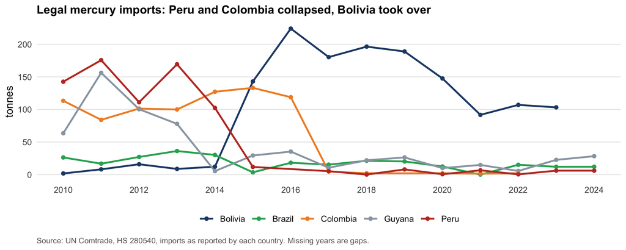

```r
ggplot(hg_m, aes(year, t, colour = country)) + geom_line(linewidth = 0.9) + geom_point(size = 1.5) +
  scale_colour_manual(values = c(Peru = col_alert, Colombia = col_soft, Brazil = "#27AE60", Bolivia = col_main, Guyana = col_grey), name = NULL) +
  scale_x_continuous(breaks = seq(2010, 2024, 2)) +
  labs(title = "Legal mercury imports: Peru and Colombia collapsed, Bolivia took over",
       x = NULL, y = "tonnes", caption = "Source: UN Comtrade, HS 280540, imports as reported by each country. Missing years are gaps.")
```

```r
ggsave(file.path(OUT, "figR_mercury.png"), width = 9, height = 3.6, dpi = 200, bg = "white")
```

**[Description]** Legal mercury imports into Peru fell from 176 t (2011) to almost nothing after 2015. Colombia’s fell from 119 t (2016) to about 2 t a year, once its ban on mercury in mining took effect (Ley 1658 of 2013, in force for mining from 2018). In the same years Bolivia became the largest importer in the region (224 t in 2016). Mining did not stop, so **legal imports no longer measure mercury use**. The Environmental Investigation Agency (2025) documented hidden shipments from Mexico to Peru and Colombia. What FZS can track instead is seizures (no open series exists) and mercury in people and fish (sampling on the ground).

## 9.4 Coca

```r
coca <- read_csv(file.path(REG, "colombia_coca_hectares_municipality.csv"), show_col_types = FALSE) %>%
  pivot_longer(starts_with("_"), names_to = "year", values_to = "ha") %>%
  mutate(year = as.integer(sub("_", "", year)), ha = replace_na(as.numeric(ha), 0))
check("Colombia coca cultivation, national total 2024 (ha)", sum(coca$ha[coca$year == 2024]), 261386)
```

```
## OK   Colombia coca cultivation, national total 2024 (ha)                         261,386.2   (publisher: 261,386)
```

```r
amazon_deps <- c("PUTUMAYO", "CAQUETÁ", "GUAVIARE", "AMAZONAS", "GUAINÍA", "VAUPÉS")
coca_amz <- coca %>% filter(departamento %in% amazon_deps, year >= 2015) %>% group_by(year) %>% summarise(ha = sum(ha))
cp <- read_excel(file.path(REG, "peru_devida_coca_leaf_prices_2020_2023.xlsx"))
mes <- c(Enero = 1, Febrero = 2, Marzo = 3, Abril = 4, Mayo = 5, Junio = 6, Julio = 7, Agosto = 8, Setiembre = 9, Octubre = 10, Noviembre = 11, Diciembre = 12)
coca_p <- cp %>% pivot_longer(-ZEI, names_to = "m", values_to = "pen_kg") %>%
  mutate(month = mes[str_extract(m, "^[A-Za-z]+")], year = as.integer(str_extract(m, "\\d{4}")), date = as.Date(sprintf("%d-%02d-01", year, month))) %>%
  filter(!is.na(pen_kg))
knitr::kable(coca_p %>% filter(ZEI %in% c("Sur Amazónico", "Triple Frontera", "NACIONAL"), month %in% c(1, 7)) %>%
               transmute(Zone = ZEI, Month = format(date, "%b %Y"), `Leaf price (soles per kg)` = round(pen_kg, 2)) %>%
               pivot_wider(names_from = Month, values_from = `Leaf price (soles per kg)`),
             caption = "Peru: coca leaf price by zone (DEVIDA), soles per kg, January and July of each year")
```

Peru: coca leaf price by zone (DEVIDA), soles per kg, January and July of each year

| Zone | Jan 2020 | Jul 2020 | Jan 2021 | Jul 2021 | Jan 2022 | Jul 2022 | Jan 2023 | Jul 2023 |
| --- | --- | --- | --- | --- | --- | --- | --- | --- |
| Triple Frontera | 5.83 | 6.37 | 6.02 | 4.96 | 6.48 | 7.99 | 6.30 | 7.17 |
| Sur Amazónico | 28.04 | 7.32 | 10.43 | 8.41 | 7.45 | 5.96 | 11.30 | 12.30 |
| NACIONAL | 12.67 | 7.86 | 8.82 | 6.36 | 5.08 | 5.73 | 6.98 | 8.93 |

```r
log_number("co_coca_amz_2024", "Coca cultivation in Colombia's six Amazon departments, 2024", coca_amz$ha[coca_amz$year == 2024], "ha", "MinJusticia/SIMCI acs4-3wgp")
```

**[Description]** Coca and gold mining share land: according to UNODC and Colombia’s Ministry of Mines, 48% of the land with alluvial gold mining in 2025 overlapped with coca. In Colombia’s six Amazon departments coca covered 54,314 ha in 2024. In Peru, the national coca leaf price fell from S/ 12.67 per kg (January 2020) to S/ 4.78 (its lowest) and later recovered. The idea that people switch to gold when coca prices fall is possible but **not tested** in the evidence we found, and coca also moves with forced eradication.

## 9.5 Signals of activity: malaria, fuel, dredges, machines

```r
mal <- map_dfr(list.files(REG, "^brazil_malaria_special_areas_\\d{4}\\.csv$", full.names = TRUE),
               ~ read_csv(.x, show_col_types = FALSE, col_types = cols(.default = "c")))
names(mal) <- c("cod_mun", "mun", "uf", "year", "area", "n")
mal <- mal %>% filter(year != "All", area != "All", uf != "All") %>% mutate(n = num(n), year = as.integer(year))   # drop subtotal rows
mal_y <- mal %>% group_by(year) %>% summarise(total = sum(n), garimpo = sum(n[area == "Garimpo"]), .groups = "drop") %>%
  mutate(share = 100 * garimpo / total)
check("Brazil Ministry of Health: autochthonous malaria cases 2022", mal_y$total[mal_y$year == 2022], 128968)
```

```
## OK   Brazil Ministry of Health: autochthonous malaria cases 2022                   128,968   (publisher: 128,968)
```

```r
mal_uf <- mal %>% filter(area == "Garimpo") %>% group_by(uf, year) %>% summarise(n = sum(n), .groups = "drop")
knitr::kable(mal_y %>% transmute(Year = year, `All cases` = fmt(total), `Caught in garimpo areas` = fmt(garimpo), `Share (%)` = round(share, 1)),
             caption = "Brazil: malaria cases caught in Brazil, and those caught in a garimpo area (2026: January to early October)")
```

Brazil: malaria cases caught in Brazil, and those caught in a garimpo area (2026: January to early October)

| Year | All cases | Caught in garimpo areas | Share (%) |
| --- | --- | --- | --- |
| 2018 | 187,734 | 5,288 | 2.8 |
| 2019 | 153,268 | 7,834 | 5.1 |
| 2020 | 143,386 | 14,143 | 9.9 |
| 2021 | 139,108 | 20,585 | 14.8 |
| 2022 | 128,968 | 23,316 | 18.1 |
| 2023 | 140,264 | 20,954 | 14.9 |
| 2024 | 138,617 | 16,046 | 11.6 |
| 2025 | 118,037 | 12,989 | 11.0 |
| 2026 | 74,574 | 11,835 | 15.9 |

```r
write_csv(mal_uf, file.path(OUT, "tableR5_brazil_malaria_garimpo_by_state.csv"))
mv <- function(y) mal_y$garimpo[mal_y$year == y]
log_number("br_mal_garimpo_2022", "Brazil malaria cases caught in garimpo areas, 2022", mv(2022), "cases", "Ministério da Saúde, Tableau 'Dados para Cidadão'")
log_number("br_mal_garimpo_2025", "Brazil malaria cases caught in garimpo areas, 2025", mv(2025), "cases", "Ministério da Saúde")
log_number("br_mal_garimpo_2026", "Brazil malaria cases caught in garimpo areas, 2026 to early October", mv(2026), "cases", "Ministério da Saúde")
```

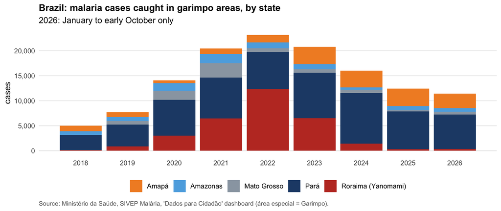

```r
mal_uf %>% filter(uf %in% c("PA", "RR", "AP", "MT", "AM")) %>%
  mutate(uf = recode(uf, PA = "Pará", RR = "Roraima (Yanomami)", AP = "Amapá", MT = "Mato Grosso", AM = "Amazonas")) %>%
  ggplot(aes(year, n, fill = uf)) + geom_col() +
  scale_fill_manual(values = c("Pará" = col_main, "Roraima (Yanomami)" = col_alert, "Amapá" = col_soft, "Mato Grosso" = col_grey, "Amazonas" = "#5DADE2"), name = NULL) +
  scale_y_continuous(labels = scales::comma) + scale_x_continuous(breaks = 2018:2026) +
  labs(title = "Brazil: malaria cases caught in garimpo areas, by state", subtitle = "2026: January to early October only",
       x = NULL, y = "cases", caption = "Source: Ministério da Saúde, SIVEP Malária, 'Dados para Cidadão' dashboard (área especial = Garimpo).")
```

```r
ggsave(file.path(OUT, "figR_brazil_malaria.png"), width = 9, height = 3.8, dpi = 200, bg = "white")
```

**[Description]** In Brazil, malaria caught in garimpo areas rose from 5,288 cases (2018) to 23,316 (2022), fell to 12,989 in 2025, and reached 11,835 by early October 2026, already 91% of the 2025 total. In Roraima (Yanomami land) cases fell sharply after the federal operation of 2023; in Pará (Munduruku land and the Tapajós) they stayed high. Malaria follows people who work in garimpos, so it measures **activity**, and it also sees mining on rivers. It depends on how much testing is done, and garimpos inside indigenous lands may be recorded as “indigenous area”.

```r
read_anp <- function(f) { d <- read_delim(file.path(REG, f), delim = ";", show_col_types = FALSE, col_types = cols(.default = "c"))
  names(d) <- c("year", "region", "uf", "product", "ibge", "mun", "sales"); d %>% mutate(year = as.integer(year), sales = num(sales)) }
avgas <- read_anp("brazil_anp_avgas_municipality.csv"); diesel <- read_anp("brazil_anp_diesel_municipality.csv")
hubs <- c(`1400100` = "Boa Vista (RR)", `1503606` = "Itaituba (PA)", `1400050` = "Alto Alegre (RR)", `1503804` = "Jacareacanga (PA)")
fuel <- bind_rows(avgas %>% mutate(fuel = "Aviation gasoline"), diesel %>% mutate(fuel = "Diesel")) %>%
  filter(ibge %in% names(hubs), year >= 2014) %>% mutate(place = hubs[ibge]) %>% group_by(fuel, place, year) %>% summarise(m3 = sum(sales) / 1000, .groups = "drop")
knitr::kable(fuel %>% filter(fuel == "Aviation gasoline", place %in% c("Boa Vista (RR)", "Itaituba (PA)")) %>% mutate(m3 = round(m3)) %>%
               pivot_wider(names_from = place, values_from = m3) %>% select(-fuel),
             caption = "Brazil: aviation gasoline sales, thousand litres (ANP)")
```

Brazil: aviation gasoline sales, thousand litres (ANP)

| year | Boa Vista (RR) | Itaituba (PA) |
| --- | --- | --- |
| 2014 | 1130 | 1253 |
| 2015 | 787 | 1351 |
| 2016 | 105 | 1720 |
| 2017 | 268 | 1636 |
| 2018 | 383 | 1342 |
| 2019 | 797 | 1306 |
| 2020 | 1847 | 1392 |
| 2021 | 3207 | 1606 |
| 2022 | 2319 | 1217 |
| 2023 | 300 | 774 |
| 2024 | 126 | 572 |

```r
av_bv <- function(y) avgas$sales[avgas$ibge == "1400100" & avgas$year == y]
check("ANP: aviation gasoline sales, Boa Vista, 2021 (litres)", av_bv(2021), 3207403)
```

```
## OK   ANP: aviation gasoline sales, Boa Vista, 2021 (litres)                      3,207,403   (publisher: 3,207,403)
```

```r
log_number("br_avgas_bv_2021", "Aviation gasoline sales, Boa Vista, 2021", av_bv(2021), "litres", "ANP")
log_number("br_avgas_bv_2024", "Aviation gasoline sales, Boa Vista, 2024", av_bv(2024), "litres", "ANP")
write_csv(fuel, file.path(OUT, "tableR6_brazil_fuel_hubs.csv"))
```

**[Description]** Small planes supply garimpos on Yanomami land from Boa Vista. Aviation gasoline sales there rose from 105 thousand litres (2016) to 3,207 (2021) and fell to 126 (2024), after the federal operation that started in 2023. Aviation fuel also has legal uses, and the series ends in 2024.

```r
md <- read_csv(file.path(REG, "colombia_mindefensa_machinery_seized.csv"), show_col_types = FALSE) %>%
  mutate(year = as.integer(substr(fecha_hecho, 1, 4)), dredge = grepl("DRAGA", clase_de_bien))
dredges_col <- md %>% filter(dredge, year >= 2016) %>%
  mutate(region = if_else(departamento %in% c("AMAZONAS", "CAQUETA", "PUTUMAYO", "GUAINIA", "GUAVIARE", "VAUPES"), str_to_title(departamento), "Rest of Colombia")) %>%
  group_by(region, year) %>% summarise(n = sum(cantidad), .groups = "drop")
check("MinDefensa: dredges destroyed or seized in Amazonas department, 2025", sum(dredges_col$n[dredges_col$region == "Amazonas" & dredges_col$year == 2025]), 56)
```

```
## OK   MinDefensa: dredges destroyed or seized in Amazonas department, 2025               56   (publisher: 56)
```

```r
knitr::kable(dredges_col %>% pivot_wider(names_from = year, values_from = n, values_fill = 0),
             caption = paste0("Colombia: dredges seized or destroyed, by department (", max(md$year), ": to ", format(max(as.Date(substr(md$fecha_hecho, 1, 10))), "%B"), ")"))
```

Colombia: dredges seized or destroyed, by department (2026: to August)

| region | 2016 | 2017 | 2018 | 2019 | 2020 | 2021 | 2022 | 2023 | 2024 | 2025 | 2026 |
| --- | --- | --- | --- | --- | --- | --- | --- | --- | --- | --- | --- |
| Amazonas | 10 | 23 | 12 | 4 | 36 | 6 | 27 | 18 | 41 | 56 | 19 |
| Caqueta | 16 | 14 | 25 | 16 | 21 | 23 | 15 | 16 | 18 | 11 | 22 |
| Guainia | 1 | 9 | 20 | 8 | 5 | 10 | 13 | 20 | 8 | 2 | 0 |
| Guaviare | 2 | 1 | 0 | 2 | 0 | 0 | 1 | 0 | 3 | 0 | 0 |
| Putumayo | 11 | 33 | 39 | 54 | 21 | 11 | 25 | 11 | 49 | 46 | 44 |
| Rest of Colombia | 280 | 320 | 249 | 492 | 530 | 522 | 667 | 563 | 628 | 856 | 709 |
| Vaupes | 0 | 0 | 0 | 2 | 0 | 0 | 0 | 0 | 0 | 2 | 0 |

```r
write_csv(dredges_col, file.path(OUT, "tableR7_colombia_dredges.csv"))
co_dr_amz_2025 <- sum(dredges_col$n[dredges_col$region != "Rest of Colombia" & dredges_col$year == 2025])
log_number("co_dredges_amazon_2025", "Dredges seized or destroyed in Colombia's six Amazon departments, 2025", co_dr_amz_2025, "dredges", "MinDefensa dxs6-mdeg")

dredges_pe <- tribble(
  ~Published, ~Source, ~Area, ~Period, ~Figure,
  "29 Sep 2025", "MAAP #233", "Loreto", "2017 to 2025", paste(fmt(pub("maap233_loreto")), "dredges recorded"),
  "29 Sep 2025", "MAAP #233", "Nanay river (Loreto)", "2017 to 2025", paste0(fmt(pub("maap233_nanay")), " recorded, of which ", pub("maap233_nanay25"), " in 2025"),
  "29 Sep 2025", "MAAP #233", "Peruvian Amazon", "to 2025", paste("mining in", pub("maap233_water"), "water bodies"),
  "17 Aug 2026", "MAAP (via Actualidad Ambiental)", "Loreto", "2025 to Jun 2026", paste0("more than ", pub("aa_records"), " records, ", pub("aa_rivers"), " rivers"))
knitr::kable(dredges_pe, caption = "Peru: published dredge counts (typed by hand)")
```

Peru: published dredge counts (typed by hand)

| Published | Source | Area | Period | Figure |
| --- | --- | --- | --- | --- |
| 29 Sep 2025 | MAAP #233 | Loreto | 2017 to 2025 | 989 dredges recorded |
| 29 Sep 2025 | MAAP #233 | Nanay river (Loreto) | 2017 to 2025 | 841 recorded, of which 275 in 2025 |
| 29 Sep 2025 | MAAP #233 | Peruvian Amazon | to 2025 | mining in 225 water bodies |
| 17 Aug 2026 | MAAP (via Actualidad Ambiental) | Loreto | 2025 to Jun 2026 | more than 700 records, 13 rivers |

```r
write_csv(dredges_pe, file.path(OUT, "tableR10_peru_dredges_published.csv"))
```

**[Description]** In Colombia, the security forces seized or destroyed 117 dredges in the six Amazon departments in 2025. These counts measure **police effort** as much as mining: more dredges destroyed can mean more mining or more operations. In Peru, the only repeated public count of dredges is MAAP’s, mostly for Loreto, read by hand from images; records are not unique dredges (the same dredge is seen many times). No source counts dredges on Madre de Dios rivers.

```r
exc <- ct_exc %>% group_by(year, country) %>% summarise(units = sum(qty, na.rm = TRUE), .groups = "drop")
knitr::kable(exc %>% mutate(units = round(units)) %>% pivot_wider(names_from = country, values_from = units),
             caption = "Imports of excavators (HS 842952), units, UN Comtrade (blank = not yet reported)")
```

Imports of excavators (HS 842952), units, UN Comtrade (blank = not yet reported)

| year | Brazil | Colombia | Peru |
| --- | --- | --- | --- |
| 2015 | 0 | 727 | 524 |
| 2016 | 494 | 601 | 346 |
| 2017 | 575 | 530 | 340 |
| 2018 | 974 | 635 | 522 |
| 2019 | 1421 | 698 | 711 |
| 2020 | 1340 | 579 | 606 |
| 2021 | 3143 | 1368 | 1405 |
| 2022 | 5868 | 2248 | 1364 |
| 2023 | 4471 | 2292 | 1378 |
| 2024 | 6676 | 2531 | 1623 |
| 2025 | 8201 | 2047 | NA |

```r
write_csv(exc, file.path(OUT, "tableR8_excavator_imports.csv"))
```

**[Description]** Between 2019 and 2024 excavator imports grew 2.3 times in Peru, 3.6 times in Colombia and 4.7 times in Brazil. Excavators are also used for roads, farms and legal mining, so this is weak as a mining measure on its own.

**Traffic at highway tolls.** Likitha studied traffic at the three toll stations on the Interoceanic Highway (OSITRAN data, separate file). Traffic grew much more at the toll next to the mining area than at the two other tolls. It is a good sign of activity on the mining road, but there are only three tolls, one toll stopped counting vehicles for 16 months after the 2023 protests, and we do not know what the trucks carry. So it is context, not a KPI.

## 9.6 Regional dashboard

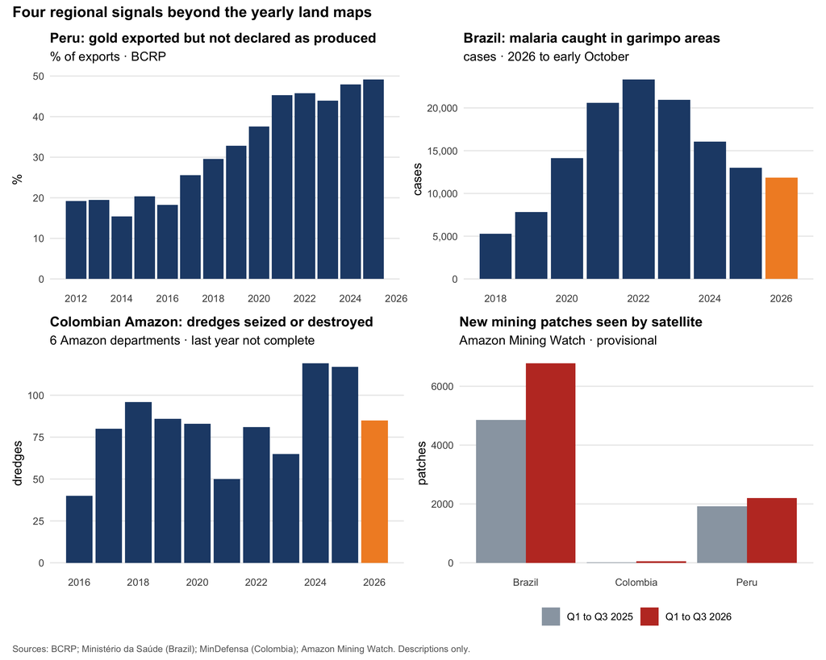

```r
r1 <- ggplot(filter(gap_y, year >= 2012), aes(year, gap_pct)) + geom_col(fill = col_main) +
  labs(title = "Peru: gold exported but not declared as produced", subtitle = "% of exports · BCRP", x = NULL, y = "%")
r2 <- ggplot(mal_y, aes(year, garimpo, fill = year == 2026)) + geom_col() +
  scale_fill_manual(values = c(`FALSE` = col_main, `TRUE` = col_soft), guide = "none") + scale_y_continuous(labels = scales::comma) +
  labs(title = "Brazil: malaria caught in garimpo areas", subtitle = "cases · 2026 to early October", x = NULL, y = "cases")
r3 <- dredges_col %>% filter(region != "Rest of Colombia") %>% group_by(year) %>% summarise(n = sum(n)) %>%
  ggplot(aes(year, n, fill = year == max(year))) + geom_col() + scale_fill_manual(values = c(`FALSE` = col_main, `TRUE` = col_soft), guide = "none") +
  labs(title = "Colombian Amazon: dredges seized or destroyed", subtitle = "6 Amazon departments · last year not complete", x = NULL, y = "dredges")
r4 <- amw_yoy %>% filter(country != "Other Amazon countries") %>% pivot_longer(c(q2025, q2026)) %>%
  mutate(name = recode(name, q2025 = "Q1 to Q3 2025", q2026 = "Q1 to Q3 2026")) %>%
  ggplot(aes(country, value, fill = name)) + geom_col(position = "dodge") + scale_fill_manual(values = c(col_grey, col_alert), name = NULL) +
  labs(title = "New mining patches seen by satellite", subtitle = "Amazon Mining Watch · provisional", x = NULL, y = "patches")
yrs <- scale_x_continuous(breaks = seq(2012, 2026, 2))
r1 <- r1 + yrs; r2 <- r2 + yrs; r3 <- r3 + yrs
(r1 + r2) / (r3 + r4) + plot_annotation(title = "Four regional signals beyond the yearly land maps",
  caption = "Sources: BCRP; Ministério da Saúde (Brazil); MinDefensa (Colombia); Amazon Mining Watch. Descriptions only.",
  theme = theme(plot.title = element_text(face = "bold", size = 13)))
```

```r
ggsave(file.path(OUT, "figR_regional_dashboard.png"), width = 10, height = 8, dpi = 220, bg = "white")
```

```r
regional <- tribble(
  ~Country, ~Signal, ~`Value today`, ~Source, ~`Updated (delay)`, ~`Does not show`,
  "Brazil", "Malaria cases caught in garimpo areas",
    paste0(fmt(mv(2025)), " in 2025; ", fmt(mv(2026)), " to early Oct 2026"),
    "Ministério da Saúde (SIVEP Malária dashboard)", "Weekly (days)", "Garimpos recorded as 'indigenous area'; depends on testing",
  "Brazil", "Aviation gasoline sales in garimpo air hubs (Boa Vista, Itaituba)",
    paste0(fmt(av_bv(2024) / 1000), " thousand litres in Boa Vista, 2024"),
    "ANP", "Yearly (about 1 year)", "Legal aviation; one town is not one mining area",
  "Colombia", "Dredges seized or destroyed in the Amazon departments",
    paste0(co_dr_amz_2025, " in 2025"), "MinDefensa (datos.gov.co dxs6-mdeg)", "Monthly (2 to 3 weeks)", "Police effort, not only mining",
  "All three", "New mining patches seen by satellite, by country",
    paste0("Peru ", pct(amw_yoy$change_pct[amw_yoy$country == "Peru"]), ", Brazil ", pct(amw_yoy$change_pct[amw_yoy$country == "Brazil"]),
           ", Colombia ", pct(amw_yoy$change_pct[amw_yoy$country == "Colombia"]), " (Q1 to Q3 2026 vs 2025)"),
    "Amazon Mining Watch", "Quarterly (days; provisional)", "River mining (most of Colombia's)",
  "Region", "Mercury imports; coca",
    paste0("Bolivia ", round(hg_m$t[hg_m$country == "Bolivia" & hg_m$year == 2023]), " t of mercury (2023); Colombian Amazon coca ", fmt(coca_amz$ha[coca_amz$year == 2024]), " ha (2024)"),
    "UN Comtrade; MinJusticia/SIMCI; DEVIDA", "Yearly (1 to 2 years)", "Smuggled mercury; no tested link between coca and gold")
knitr::kable(regional, caption = "Context signals for the region")
```

Context signals for the region

| Country | Signal | Value today | Source | Updated (delay) | Does not show |
| --- | --- | --- | --- | --- | --- |
| Brazil | Malaria cases caught in garimpo areas | 12,989 in 2025; 11,835 to early Oct 2026 | Ministério da Saúde (SIVEP Malária dashboard) | Weekly (days) | Garimpos recorded as ‘indigenous area’; depends on testing |
| Brazil | Aviation gasoline sales in garimpo air hubs (Boa Vista, Itaituba) | 126 thousand litres in Boa Vista, 2024 | ANP | Yearly (about 1 year) | Legal aviation; one town is not one mining area |
| Colombia | Dredges seized or destroyed in the Amazon departments | 117 in 2025 | MinDefensa (datos.gov.co dxs6-mdeg) | Monthly (2 to 3 weeks) | Police effort, not only mining |
| All three | New mining patches seen by satellite, by country | Peru +15%, Brazil +40%, Colombia +184% (Q1 to Q3 2026 vs 2025) | Amazon Mining Watch | Quarterly (days; provisional) | River mining (most of Colombia’s) |
| Region | Mercury imports; coca | Bolivia 103 t of mercury (2023); Colombian Amazon coca 54,314 ha (2024) | UN Comtrade; MinJusticia/SIMCI; DEVIDA | Yearly (1 to 2 years) | Smuggled mercury; no tested link between coca and gold |

```r
write_csv(regional, file.path(OUT, "tableR9_regional_context.csv"))
```

# 10 Did the satellite methods change?

Our indicators compare years, so a change in *how* images are classified can look like a change in mining. We checked the documents of each satellite source.

- **MapBiomas Peru (Collection 4).** Every collection classifies all years again from 1985, so values change between collections (Madre de Dios, 2022: about 82,900 ha in Collection 2, 74,966 ha in Collection 4). The images come from several Landsat satellites over time. The Collection 4 method documents were offline when we checked (14 October 2026). The method is described as following MapBiomas Brazil’s mining method, which corrects each year using the year before and the year after. The last year (here 2025) has no “year after”, so it is the least corrected and the most likely to change in the next collection.
- **Amazon Mining Watch.** Its README (3 October 2026) says the model “was wholly redeveloped in 2026 and the data recomputed starting from year 2018”. Older MAAP figures based on Amazon Mining Watch are therefore not comparable with today’s files. Quarterly detections use a stricter rule than yearly ones. The scar map is “in development” and its areas “run large”.
- **MapBiomas Brazil (course pack).** The municipality table is Collection 10.1 and `mining_area.csv` is Collection 11; we do not combine them.
- **MAAP.** Its long series joins different methods over time, and its 2021 to 2023 total was revised from 23,881 ha (#195) to 28,292 ha (#208).

**A possible break in 2023.** The flows between water and mining change suddenly in 2023, and not only in Madre de Dios:

```r
flip_tab <- tr_pol %>% filter(year >= 2016) %>%
  mutate(region = if_else(unit == "Madre de Dios", "Madre de Dios", "Rest of Peru"),
         flow = case_when(class_from %in% WATER & class_to == MINING ~ "Water to mining",
                          class_from == MINING & class_to %in% WATER ~ "Mining to water")) %>%
  filter(!is.na(flow)) %>% group_by(region, flow, year) %>% summarise(ha = sum(ha), .groups = "drop")
knitr::kable(flip_tab %>% mutate(ha = fmt(ha)) %>% pivot_wider(names_from = year, values_from = ha) %>% arrange(flow, region),
             caption = "Flows between water and mining (ha per year), MapBiomas Peru Collection 4")
```

Flows between water and mining (ha per year), MapBiomas Peru Collection 4

| region | flow | 2016 | 2017 | 2018 | 2019 | 2020 | 2021 | 2022 | 2023 | 2024 | 2025 |
| --- | --- | --- | --- | --- | --- | --- | --- | --- | --- | --- | --- |
| Madre de Dios | Mining to water | 678 | 1,026 | 1,259 | 2,105 | 1,591 | 2,465 | 2,130 | 222 | 236 | 411 |
| Rest of Peru | Mining to water | 322 | 340 | 496 | 512 | 489 | 732 | 365 | 286 | 591 | 1,047 |
| Madre de Dios | Water to mining | 725 | 951 | 1,102 | 1,068 | 2,009 | 1,963 | 2,997 | 9,616 | 395 | 973 |
| Rest of Peru | Water to mining | 352 | 441 | 380 | 382 | 639 | 418 | 827 | 1,338 | 304 | 482 |

```r
write_csv(flip_tab, file.path(OUT, "table1c_water_mining_flips.csv"))
fv <- function(r, fl, y) flip_tab$ha[flip_tab$region == r & flip_tab$flow == fl & flip_tab$year %in% y]
log_number("w2m_rest_2023", "Water to mining, rest of Peru, 2023", fv("Rest of Peru", "Water to mining", 2023), "ha", "MapBiomas C4 transitions")
log_number("m2w_mdd_2023", "Mining to water, Madre de Dios, 2023", fv("Madre de Dios", "Mining to water", 2023), "ha", "MapBiomas C4 transitions")
```

**[Description]** In Madre de Dios, on average 2,073 ha of mining land a year was relabelled as water in 2019 to 2022, but only 222 ha in 2023. At the same time 9,616 ha of water was relabelled as mining. In the rest of Peru, water to mining also jumped, from an average of 491 ha a year in 2016 to 2022 to 1,338 ha in 2023. Miners going back to old pits in Madre de Dios would not explain the same jump in the rest of Peru, so part of the 2023 change may come from how this collection classified ponds and mining **[Interpretation, not tested]**. We could not confirm this in the documents. KPI 4 does not use these flows, which is one more reason to prefer forest that became mining.

# 11 What the data cannot see

- **Rivers and mercury.** No land map measures dredges, or mercury in water, fish and people. Dredge counts exist only for Loreto (Peru) and as police seizures (Colombia). Mercury needs sampling on the ground.
- **Legality.** “Mining” includes legal mining in the mining corridor. A mining title does not prove legality, and no title does not prove illegality. Only mining inside a reserve is clearly illegal.
- **Revisions and model changes.** Every MapBiomas collection revises earlier years, and Amazon Mining Watch rebuilt its model in 2026 and replaces its files. FZS should save each version it uses and write the version next to every number.
- **Targets.** If an indicator becomes a target (for example, mining inside a reserve), miners and agencies may respond to the number rather than to the problem.

```r
numbers <- bind_rows(numbers, published %>% mutate(source = paste(source, "(typed by hand)"))) %>% mutate(value = round(value, 2))
stopifnot(!any(duplicated(numbers$id)))
write_csv(numbers, file.path(OUT, "numbers_in_brief.csv"))
knitr::kable(numbers, caption = "Numbers produced or quoted in this notebook (output/numbers_in_brief.csv)")
```

Numbers produced or quoted in this notebook (output/numbers_in_brief.csv)

| id | description | value | unit | source |
| --- | --- | --- | --- | --- |
| chk_mdd_2025 | Mining area, Madre de Dios, 2025 | 112621.71 | ha | MapBiomas Peru C4, Limites politicos, COVERAGE_4, class 30 |
| chk_amz_2025 | Mining area, Peru Amazon biome, 2025 | 118295.55 | ha | MapBiomas Peru C4, Limites politicos |
| chk_tamb_za_2025 | Mining area, Tambopata buffer zone, 2025 | 20730.03 | ha | MapBiomas Peru C4, Zona de amortiguamiento |
| gold_aug2026 | Gold price, August 2026 | 4411.00 | USD per oz | World Bank Pink Sheet, Oct 2026 vintage |
| amw_mdd_n | Amazon Mining Watch detections in Madre de Dios (all periods) | 27302.00 | patches | Amazon Mining Watch, README dated 3 Oct 2026 |
| amw_peru_2024 | AMW detections in Peru with onset 2024 (version check) | 2072.00 | patches | Amazon Mining Watch GeoJSON |
| scar_peru_all | AMW new scar, Peru, all periods 2018 to 2026 Q3 | 185553.74 | ha | AMW scar map (our sum) |
| scar_peru_all_amw | AMW new scar, Peru, all periods, AMW’s own table | 185565.60 | ha | AMW mined_areas_by_jurisdiction.csv |
| net_2021 | Net addition, Madre de Dios, 2021 | 4940.17 | ha | MapBiomas C4 |
| net_2022 | Net addition, Madre de Dios, 2022 | 10540.32 | ha | MapBiomas C4 |
| net_2023 | Net addition, Madre de Dios, 2023 | 19339.40 | ha | MapBiomas C4 |
| net_2024 | Net addition, Madre de Dios, 2024 | 7573.51 | ha | MapBiomas C4 |
| net_2025 | Net addition, Madre de Dios, 2025 | 10742.31 | ha | MapBiomas C4 |
| ff_2021 | Forest to mining, Madre de Dios, 2021 | 6152.25 | ha | MapBiomas C4 transitions |
| ff_2022 | Forest to mining, Madre de Dios, 2022 | 7885.03 | ha | MapBiomas C4 transitions |
| ff_2023 | Forest to mining, Madre de Dios, 2023 | 9981.90 | ha | MapBiomas C4 transitions |
| ff_2024 | Forest to mining, Madre de Dios, 2024 | 7135.59 | ha | MapBiomas C4 transitions |
| ff_2025 | Forest to mining, Madre de Dios, 2025 | 10308.19 | ha | MapBiomas C4 transitions |
| water_2022 | Water to mining, Madre de Dios, 2022 | 2997.09 | ha | MapBiomas C4 transitions |
| water_2023 | Water to mining, Madre de Dios, 2023 | 9615.75 | ha | MapBiomas C4 transitions |
| water_2024 | Water to mining, Madre de Dios, 2024 | 394.57 | ha | MapBiomas C4 transitions |
| share_water_2023 | Share of land coming into mining that was water, 2023 | 39.08 | % | MapBiomas C4 transitions |
| gross_in_2025 | Land coming into mining, Madre de Dios, 2025 | 16474.87 | ha | MapBiomas C4 transitions |
| gross_out_2024 | Land leaving mining, Madre de Dios, 2024 | 2947.78 | ha | MapBiomas C4 transitions |
| gross_out_2025 | Land leaving mining, Madre de Dios, 2025 | 5732.56 | ha | MapBiomas C4 transitions |
| gross_out_2001_2025 | Land leaving mining, Madre de Dios, 2001 to 2025 (a pixel can count more than once) | 65515.85 | ha | MapBiomas C4 transitions |
| share_mdd_amazon | Madre de Dios share of mining area in Peru’s Amazon biome, 2025 | 95.20 | % | MapBiomas C4 |
| left_forestregrowth | Share of land leaving mining in 2025 that became: Forest (regrowth) | 35.98 | % | MapBiomas C4 transitions |
| left_farmlandorpasture | Share of land leaving mining in 2025 that became: Farmland or pasture | 24.07 | % | MapBiomas C4 transitions |
| left_riverbeach | Share of land leaving mining in 2025 that became: River beach | 15.14 | % | MapBiomas C4 transitions |

[output cut: 138 more lines]